# **Econometric Models in Practice**

OLS, IV, Panel Data Model (Fixed Effects), DiD, Synthetic Control, and VAR

I Gede Nyoman Mindra Jaya, Ph.D

14 November 2025

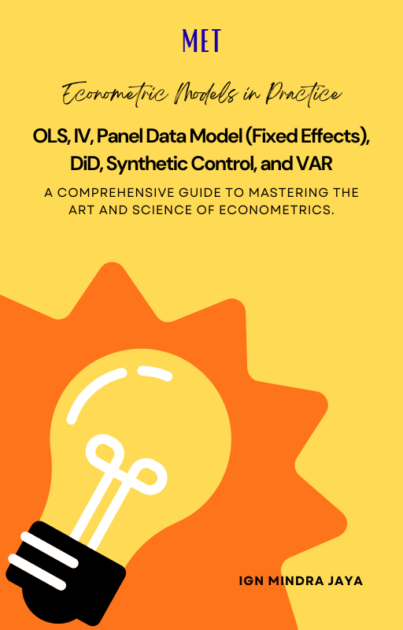

**Kata Pengantar**

Puji syukur saya panjatkan ke hadirat Tuhan Yang Maha Esa, karena atas rahmat dan karunia-Nya buku Econometric Models in Practice ini dapat tersusun. Buku ini disusun sebagai panduan praktis bagi mahasiswa, peneliti, dan praktisi yang ingin memahami serta menerapkan model ekonometrika modern dalam analisis data nyata. Pembahasan dimulai dari model dasar seperti Ordinary Least Squares (OLS), kemudian berlanjut ke model yang lebih kompleks seperti Instrumental Variables (IV), Fixed Effects Panel Model, Difference-in-Differences (DiD), Synthetic Control, hingga Vector Autoregression (VAR).

Pendekatan yang digunakan dalam buku ini menekankan pada keseimbangan antara konsep teoritis dan penerapan empiris. Setiap model tidak hanya dijelaskan secara matematis, tetapi juga disertai contoh implementasi menggunakan perangkat lunak statistik yang umum digunakan. Harapannya, pembaca tidak hanya memahami rumus, tetapi juga mampu menghubungkan model dengan konteks ekonomi dan kebijakan publik yang relevan.

Saya menyadari bahwa kesempurnaan adalah proses yang berkelanjutan. Oleh karena itu, kritik dan saran yang membangun sangat saya harapkan untuk penyempurnaan edisi berikutnya. Semoga buku ini dapat menjadi referensi yang bermanfaat dalam memperkuat literasi ekonometrika di kalangan akademisi dan praktisi di Indonesia.

Bandung, I Gede Nyoman Mindra Jaya, Ph.D

# 1 **Ordinary Least Squares (OLS)**

Model dasar untuk relasi linier:

$$y_i = \beta_0 + \beta_1 x_{1i} + \beta_2 x_{2i} + \varepsilon_i.$$

**Konsep Model Regresi Linier dan Nonlinier**

Regresi memetakan hubungan **variabel dependen** \(y\) dengan satu/lebih **prediktor** \(x\). Intuisi sederhananya: kita mencari garis/hiperbidang yang **meringkas pola** rerata \(y\) terhadap \(x\).

## 1.1 Regresi Linier (linier terhadap parameter)

Model klasik: \[ y_i = \beta_0 + \beta_1 x_{1i} + \cdots + \beta_k x_{ki} + \varepsilon_i,\quad E(\varepsilon_i\mid X)=0,\ \text{Var}(\varepsilon_i\mid X)=\sigma^2. \] “Linier” **terhadap parameter** berarti \(\beta\) hanya muncul pangkat satu. Bentuk fungsi terhadap \(x\) boleh fleksibel asalkan tetap linier pada \(\beta\): misalnya polinomial \(y=\beta_0+\beta_1 x+\beta_2 x^2+e\) tetap linier pada parameter.

**Contoh fitur nonlinier tapi linier-dalam-parameter** (basis):

- Polinomial: \(x, x^2, x^3\)
- Transformasi: \(\log x\), splines, dummy variabel (kategori)
- Interaksi: \(x_1\times x_2\)

## 1.2 Regresi Nonlinier (nonlinier terhadap parameter)

Bentuk umum: \(y_i = f(x_i,\,\beta) + \varepsilon_i\) dengan \(f\) nonlinier pada \(\beta\) (mis. eksponensial, Michaelis–Menten). Estimasi biasanya via **Nonlinear Least Squares** atau **MLE** khusus.

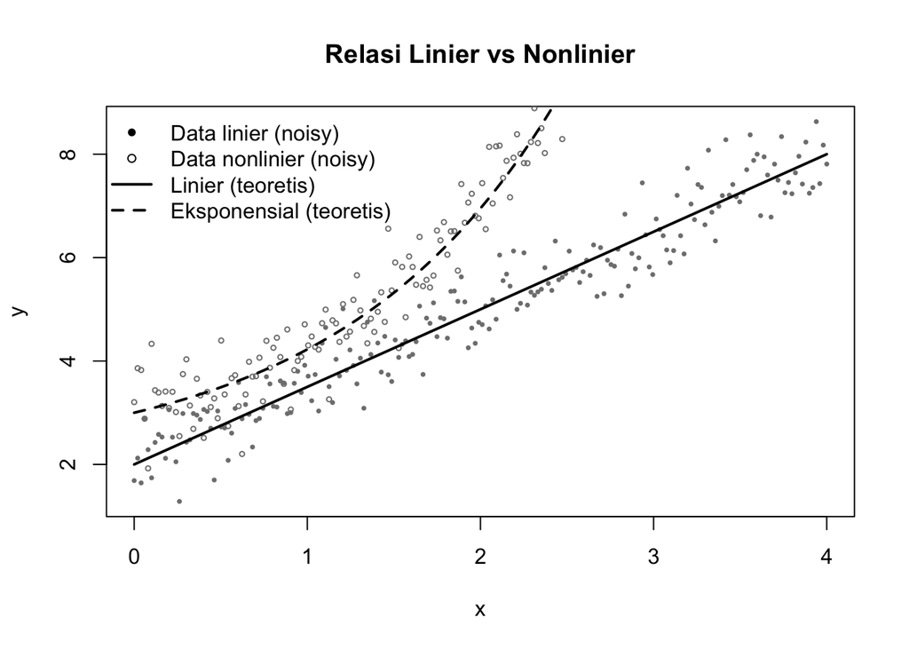

```r
set.seed(1)
x <- seq(0, 4, length.out = 200)

# fungsi "benar" (tanpa noise)
f_lin <- 2 + 1.5*x
f_non <- 2 + exp(0.8*x)

# data observasi (dengan noise)
y_lin <- f_lin + rnorm(length(x), 0, 0.5)
y_non <- f_non + rnorm(length(x), 0, 0.5)

plot(x, y_lin, pch = 16, cex = 0.5, col = "grey50",
     ylab = "y", main = "Relasi Linier vs Nonlinier")
points(x, y_non, pch = 1, cex = 0.5, col = "grey50")

lines(x, f_lin, lwd = 2)             # garis mulus linier
lines(x, f_non, lwd = 2, lty = 2)    # garis mulus eksponensial

legend("topleft",
       c("Data linier (noisy)", "Data nonlinier (noisy)", "Linier (teoretis)", "Eksponensial (teoretis)"),
       pch = c(16, 1, NA, NA), lty = c(NA, NA, 1, 2), lwd = c(NA, NA, 2, 2),
       pt.cex = 0.8, bty = "n")
```

**Prinsip kunci:** jika hubungan tidak linier terhadap \(x\), sering kali **rekayasa fitur** (polinomial, log, spline) cukup tanpa pindah ke regresi nonlinier murni.

## 1.3 Metode Estimasi: OLS dan Maximum Likelihood

### 1.3.1 Ordinary Least Squares (OLS)

OLS memilih \(\hat\beta\) yang meminimalkan jumlah kuadrat residu: \[ \hat\beta = \arg\min_\beta (y-X\beta)’(y-X\beta) \Rightarrow \hat\beta=(X’X)^{-1}X’y. \] Di bawah asumsi klasik (Gauss–Markov: linearitas, eksogenitas, ragam konstan, tak ada multikolinearitas sempurna), \(\hat\beta\) adalah **BLUE** (Best Linear Unbiased Estimator).

### 1.3.2 Maximum Likelihood Estimation (MLE)

Asumsikan bahwa kesalahan berdistribusi normal:
$$\varepsilon \sim N(0, \sigma^2 I).$$

**Likelihood function:**

$$L(\beta, \sigma^2) \propto (\sigma^2)^{-n/2}
\exp\Big\{
-\tfrac{1}{2\sigma^2}(y - X\beta)'(y - X\beta)
\Big\}.$$

Memaksimalkan log-likelihood menghasilkan
$$\hat{\beta}_{\text{MLE}} = \hat{\beta}_{\text{OLS}}.$$
Artinya, di bawah asumsi error normal, estimasi OLS juga merupakan estimasi MLE;
perbedaan hanya muncul pada estimasi varians error
$\sigma^2$, yaitu pembagi $n$ vs $n - k - 1$.

**Catatan praktik:**  
Saat terjadi heteroskedastisitas atau autokorelasi, $\hat{\beta}_{\text{OLS}}$ tetap tak bias,  
namun **standar error** tidak valid. Untuk mengoreksinya, gunakan **robust standard error**  
(seperti Heteroskedasticity-Consistent / HC, atau Newey–West)  
atau gunakan pendekatan **GLS/WLS**.

### 1.3.3 Uji Hipotesis

#### 1.3.3.1 Uji t untuk koefisien individual

Hipotesis: \(H_0: \beta_j = b_0\). Statistik: \[ t = \frac{\hat\beta_j - b_0}{SE(\hat\beta_j)} \sim t_{(n-k-1)}. \] P-value kecil \(\Rightarrow\) tolak \(H_0\). Interval kepercayaan \((1-\alpha)\%\): \(\hat\beta_j \pm t_{\alpha/2}\cdot SE\).

#### 1.3.3.2 Uji F untuk restriksi simultan

Hipotesis linear: \(H_0: R\beta=r\) dengan \(q\) restriksi. Statistik F dari model **terbatas** vs **penuh** menilai signifikansi gabungan.

#### 1.3.3.3 Uji kecocokan umum (overall)

\(H_0: \beta_1=\cdots=\beta_k=0\). Statistik F pada tabel `summary(lm)` — menilai apakah prediktor bersama-sama menjelaskan variasi \(y\).

## 1.4 Validitas Model: Uji Asumsi Klasik

Asumsi klasik memastikan inferensi sah: standar error, p-value, dan CI akurat.

- **Linearitas**: spesifikasi benar (dalam parameter), tidak ada mis‑spesifikasi sistematis.
- **Normalitas error**: terutama penting untuk inference pada sampel kecil.
- **Homoskedastisitas**: ragam residual konstan pada seluruh rentang fitted.
- **Nonautokorelasi**: residu tak berkorelasi (penting pada deret waktu/panel).
- **Nonmultikolinearitas**: tidak ada kolinearitas (atau minimal) antar prediktor.

**Remedi umum** bila asumsi gagal: transformasi variabel (log/Box‑Cox), tambah fitur (polinomial/interaksi), **robust SE** (HC0–HC3), **Newey–West** untuk autokorelasi, atau model alternatif (GLS, ARIMA errors).

## 1.5 Contoh Lengkap: Estimasi, Uji Hipotesis, Uji Asumsi

### 1.5.1 Bangun Data Simulasi

Kita buat data dengan dua prediktor, salah satunya sedikit kolinear dengan yang lain, plus heteroskedastisitas ringan agar diagnosa bermakna.

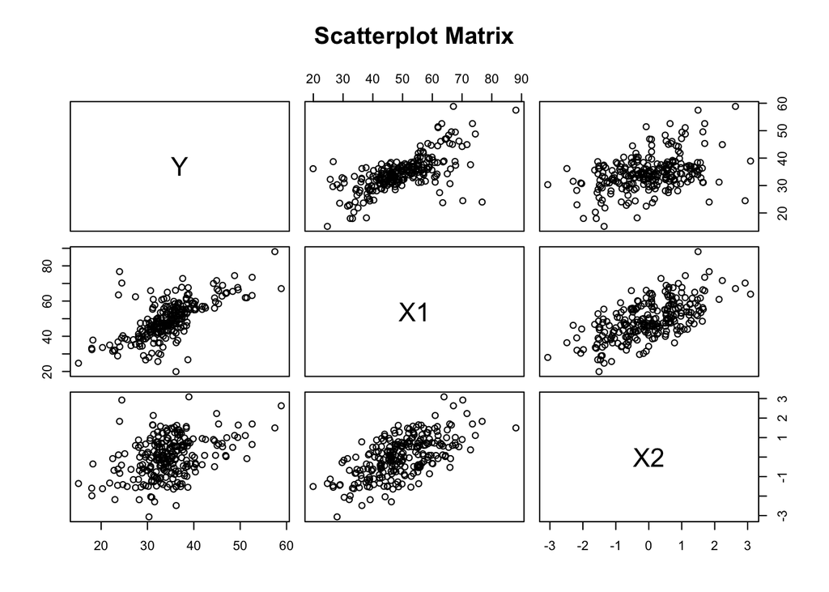

```r
n  <- 250
X1 <- rnorm(n, 50, 10)
X2_raw <- rnorm(n, 30, 5)
X2 <- 0.6*scale(X1) + 0.8*scale(X2_raw)  # sengaja kolinear sedang
sigma <- 2 + 0.02*(X1 - mean(X1))^2      # heteroskedastisitas lemah
eps <- rnorm(n, 0, sigma)
Y <- 10 + 0.5*X1 - 0.3*X2 + eps
dat <- tibble(Y, X1, X2, sigma)

pairs(~ Y + X1 + X2, data = dat, main = "Scatterplot Matrix")
```

### 1.5.2 Estimasi Model OLS

```r
fit <- lm(Y ~ X1 + X2, data = dat)
summary(fit)
```

```
##
## Call:
## lm(formula = Y ~ X1 + X2, data = dat)
##
## Residuals:
##      Min       1Q   Median       3Q      Max
## -21.4946  -2.3506   0.0966   2.2356  17.7011
##
## Coefficients:
##             Estimate Std. Error t value Pr(>|t|)
## (Intercept) 13.81273    1.80905   7.635 4.92e-13 ***
## X1           0.42005    0.03614  11.623  < 2e-16 ***
## X2          -0.32006    0.37585  -0.852    0.395
## ---
## Signif. codes:  0 '***' 0.001 '**' 0.01 '*' 0.05 '.' 0.1 ' ' 1
##
## Residual standard error: 4.735 on 247 degrees of freedom
## Multiple R-squared:  0.4538, Adjusted R-squared:  0.4494
## F-statistic: 102.6 on 2 and 247 DF,  p-value: < 2.2e-16
```

```r
confint(fit)  # interval kepercayaan koefisien
```

```
##                  2.5 %     97.5 %
## (Intercept) 10.2495975 17.3758554
## X1           0.3488746  0.4912338
## X2          -1.0603371  0.4202134
```

**Interpretasi cepat.**

- Tanda koefisien selaras dengan data generatif (\(+\) untuk \(X1\), \(-\) untuk \(X2\)). - Perhatikan `Std. Error` dan `Pr(>|t|)` untuk signifikansi. - `R-squared` mengukur proporsi variasi \(Y\) yang dijelaskan.

### 1.5.3 Prediksi & Interval

```r
newdf <- tibble(X1 = c(40, 60))
newdf$X2 <- matrix(c(25, 35), ncol = 1)  # bikin nmatrix.1 juga

predict(fit, newdf, interval = "confidence")
```

```
##        fit      lwr      upr
## 1 22.61335 3.669021 41.55767
## 2 27.81381 2.368647 53.25898
```

```r
predict(fit, newdf, interval = "prediction")
```

```
##        fit      lwr      upr
## 1 22.61335 1.497742 43.72895
## 2 27.81381 0.713300 54.91432
```

**Catatan.** Interval **confidence** untuk rerata bersifat lebih sempit daripada **prediction** untuk observasi baru.

### 1.5.4 Uji t & Uji F

```r
# Uji t sudah ada di summary; contoh uji F gabungan:
# H0: beta_X1 = beta_X2 = 0
fit0 <- lm(Y ~ 1, data = dat)
anova(fit0, fit)   # perbandingan model terbatas vs penuh (uji F)
```

```
## Analysis of Variance Table
##
## Model 1: Y ~ 1
## Model 2: Y ~ X1 + X2
##   Res.Df     RSS Df Sum of Sq     F    Pr(>F)
## 1    249 10139.1
## 2    247  5538.1  2    4601.1 102.6 < 2.2e-16 ***
## ---
## Signif. codes:  0 '***' 0.001 '**' 0.01 '*' 0.05 '.' 0.1 ' ' 1
```

### 1.5.5 Diagnostik Asumsi Klasik

#### 1.5.5.1 Linearitas & Spesifikasi

Plot residual vs fitted semestinya acak; `residualPlots` memeriksa nonlinieritas.

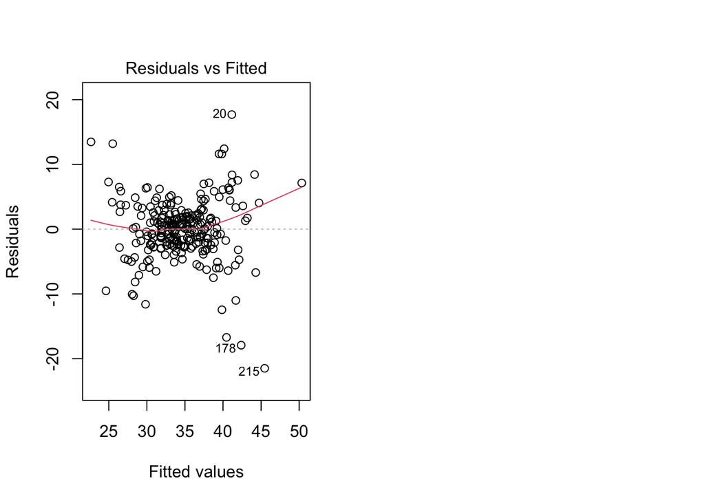

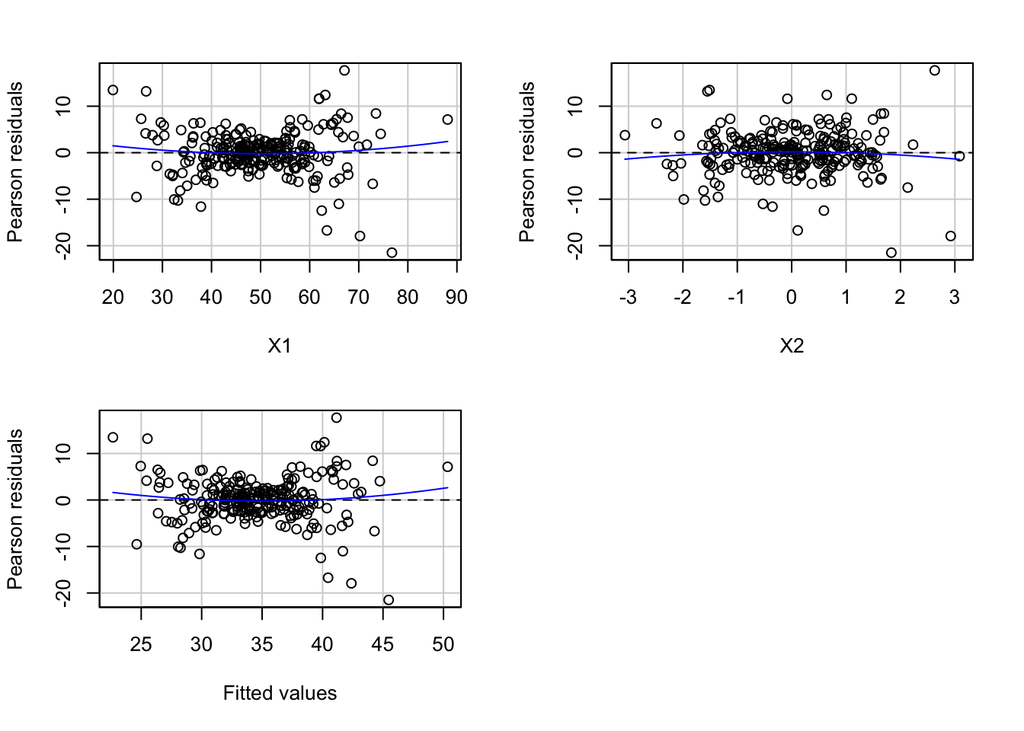

```
##            Test stat Pr(>|Test stat|)
## X1            1.0486           0.2954
## X2           -0.8251           0.4101
## Tukey test    1.1241           0.2610
```

```r
par(mfrow=c(1,2))
plot(fit, which = 1)            # Residuals vs Fitted
car::residualPlots(fit)         # Component + Residual (CERES) plots
```

```r
par(mfrow=c(1,1))
```

#### 1.5.5.2 Normalitas Error

Gunakan QQ-plot dan uji formal (Shapiro & Anderson–Darling).

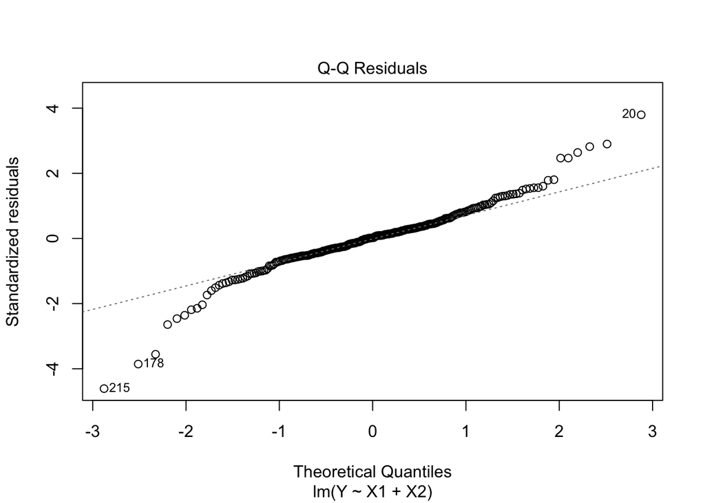

```r
plot(fit, which = 2)                       # QQ-plot
```

```r
shapiro.test(residuals(fit))               # sensitif untuk n besar
```

```
##
##  Shapiro-Wilk normality test
##
## data:  residuals(fit)
## W = 0.94741, p-value = 7.73e-08
```

```r
nortest::ad.test(residuals(fit))
```

```
##
##  Anderson-Darling normality test
##
## data:  residuals(fit)
## A = 2.9442, p-value = 2.043e-07
```

#### 1.5.5.3 Homoskedastisitas

Breusch–Pagan (bentuk dasar & White-style).

```r
lmtest::bptest(fit)                                    # BP test (fitted)
```

```
##
##  studentized Breusch-Pagan test
##
## data:  fit
## BP = 10.255, df = 2, p-value = 0.005932
```

```r
lmtest::bptest(fit, ~ fitted(fit) + I(fitted(fit)^2))  # White-type
```

```
##
##  studentized Breusch-Pagan test
##
## data:  fit
## BP = 58.132, df = 2, p-value = 2.381e-13
```

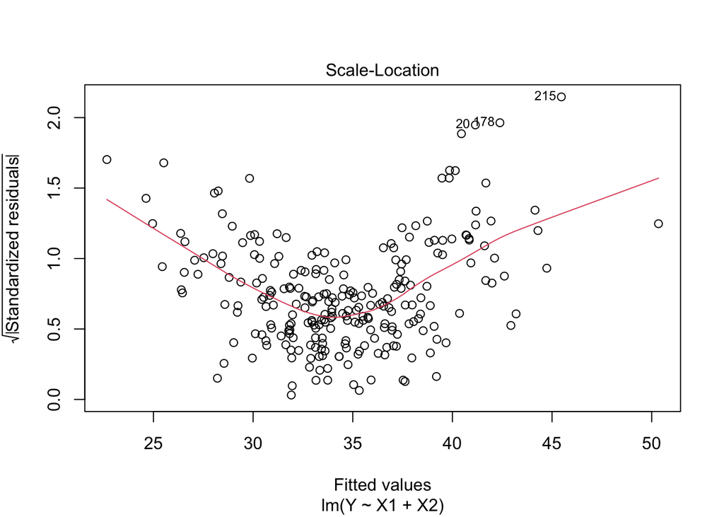

```r
plot(fit, which = 3)                                   # Scale-Location plot
```

**Robust SE (HC) bila heteroskedastik:**

```r
coeftest(fit, vcov = vcovHC(fit, type = "HC3"))
```

```
##
## t test of coefficients:
##
##              Estimate Std. Error t value  Pr(>|t|)
## (Intercept) 13.812726   2.370668  5.8265 1.758e-08 ***
## X1           0.420054   0.049091  8.5567 1.246e-15 ***
## X2          -0.320062   0.406506 -0.7873    0.4318
## ---
## Signif. codes:  0 '***' 0.001 '**' 0.01 '*' 0.05 '.' 0.1 ' ' 1
```

#### 1.5.5.4 Nonautokorelasi (opsional di cross-section)

Durbin–Watson dan Breusch–Godfrey.

```r
lmtest::dwtest(fit)
```

```
##
##  Durbin-Watson test
##
## data:  fit
## DW = 1.953, p-value = 0.3571
## alternative hypothesis: true autocorrelation is greater than 0
```

```r
lmtest::bgtest(fit, order = 2)   # uji autokorelasi orde 2
```

```
##
##  Breusch-Godfrey test for serial correlation of order up to 2
##
## data:  fit
## LM test = 0.77854, df = 2, p-value = 0.6776
```

**Untuk deret waktu**, pertimbangkan menambah lag residual atau gunakan Newey–West SE:

```r
coeftest(fit, vcov = NeweyWest(fit, lag = 2, prewhite = FALSE))
```

[output not shown]

#### 1.5.5.5 Nonmultikolinearitas

VIF dan **condition number**.

```r
car::vif(fit)
```

```
##       X1       X2
## 1.663999 1.663999
```

```r
X <- model.matrix(fit)
kappa(qr.R(qr(X)))   # condition number (>>30 indikasi masalah)
```

```
## [1] 273.1844
```

**Remedi:** buang/rekayasa fitur, regularisasi (Ridge/Lasso), atau kumpulkan lebih banyak data.

#### 1.5.5.6 Outlier & Leverage

Cook’s distance, leverage, dan pengaruh.

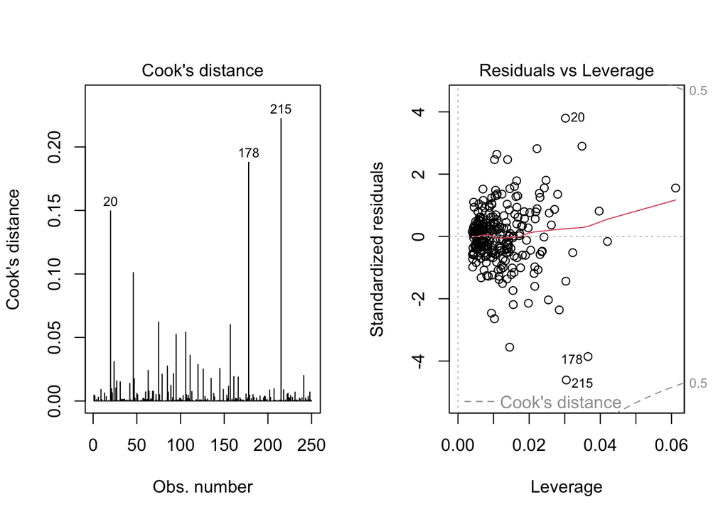

```r
par(mfrow=c(1,2))
plot(fit, which = 4)  # Cook's distance
plot(fit, which = 5)  # Residuals vs Leverage
```

```r
par(mfrow=c(1,1))
influence.measures(fit)$infmat[1:5,]
```

```
##         dfb.1_       dfb.X1       dfb.X2       dffit    cov.r       cook.d
## 1  0.051030617 -0.065363990 -0.002496740 -0.11851524 1.000909 4.670010e-03
## 2 -0.085733056  0.095141837 -0.040630593  0.10988430 1.025760 4.031613e-03
## 3  0.009082744 -0.008283275  0.009692429  0.01149691 1.030027 4.423737e-05
## 4  0.013489488 -0.019628988  0.044407632 -0.05785212 1.019275 1.118744e-03
## 5  0.010630488 -0.007819191  0.005232231  0.01929349 1.016156 1.245448e-04
##          hat
## 1 0.00853456
## 2 0.02019325
## 3 0.01735334
## 4 0.01065226
## 5 0.00478831
```

## 1.6 Estimasi dengan MLE (verifikasi ringkas)

Dengan asumsi normalitas error, OLS = MLE untuk \(\beta\). Kita verifikasi dengan optimisasi numerik sederhana.

```r
negloglik <- function(par, y, X){
  beta <- par[1:ncol(X)]
  logs2 <- par[length(par)]
  s2 <- exp(logs2)                # pastikan positif
  e <- y - X %*% beta
  n <- length(y)
  0.5*n*log(2*pi) + 0.5*n*log(s2) + 0.5*sum(e^2)/s2
}

X <- model.matrix(fit)
y <- dat$Y
init <- c(coef(fit), log(var(residuals(fit))))
opt <- optim(init, negloglik, y=y, X=X, method="BFGS", hessian=TRUE)
beta_mle <- opt$par[1:ncol(X)]
cbind(OLS=coef(fit), MLE=beta_mle)
```

```
##                    OLS        MLE
## (Intercept) 13.8127264 13.8127264
## X1           0.4200542  0.4200542
## X2          -0.3200619 -0.3200619
```

Hasil \(\beta\) dari MLE praktis sama dengan OLS (perbedaan numerik kecil).

## 1.7 Rangkuman & Praktik Baik

- Gunakan **grafik diagnostik** terlebih dahulu; uji formal melengkapi, bukan menggantikan.
- Saat asumsi gagal: gunakan **robust SE** (HC3) untuk heteroskedastisitas, **Newey–West** untuk autokorelasi, atau pertimbangkan **spesifikasi ulang**.
- Dokumentasikan keputusan model (transformasi, outlier treatment, pemilihan fitur) agar **reproducible**.

## 1.8 Lampiran: Kode Ringkas One‑Shot

```r
fit <- lm(Y ~ X1 + X2, data = dat)
list(
  summary = summary(fit),
  confint = confint(fit),
  t_overallF = anova(lm(Y ~ 1, dat), fit),
  bp = bptest(fit),
  bp_white = bptest(fit, ~ fitted(fit) + I(fitted(fit)^2)),
  dw = dwtest(fit),
  bg = bgtest(fit, order = 2),
  vif = car::vif(fit),
  robust = coeftest(fit, vcov = vcovHC(fit, type = "HC3"))
)
```

**Penutup.** OLS tetap rajanya untuk model linier—cepat, transparan, dan kuat—asal *rumah tangga asumsi* rapi. Saat dunia nyata berisik, naikkan perisai **robust SE** dan akal sehat spesifikasi.

```r
n <- 200
x1 <- rnorm(n)
x2 <- runif(n, -1, 1)
y  <- 3 + 2*x1 - 1.5*x2 + rnorm(n, sd = 0.6)

ols_model <- lm(y ~ x1 + x2)
summary(ols_model)
```

```
##
## Call:
## lm(formula = y ~ x1 + x2)
##
## Residuals:
##      Min       1Q   Median       3Q      Max
## -1.78896 -0.34550  0.04367  0.38220  1.33299
##
## Coefficients:
##             Estimate Std. Error t value Pr(>|t|)
## (Intercept)  2.99707    0.04253   70.47   <2e-16 ***
## x1           1.99354    0.04074   48.94   <2e-16 ***
## x2          -1.53342    0.07308  -20.98   <2e-16 ***
## ---
## Signif. codes:  0 '***' 0.001 '**' 0.01 '*' 0.05 '.' 0.1 ' ' 1
##
## Residual standard error: 0.6001 on 197 degrees of freedom
## Multiple R-squared:  0.9344, Adjusted R-squared:  0.9338
## F-statistic:  1404 on 2 and 197 DF,  p-value: < 2.2e-16
```

**Catatan interpretasi.** Koefisien menyatakan perubahan rata-rata pada $y$ akibat perubahan satu unit pada kovariat terkait, ceteris paribus.

# 2 **Endogeneity dalam Ekonometrika**

## 2.1 Model Regresi Dasar dan Asumsi Eksogenitas

Kita mulai dari model linier sederhana:

$$Y_i = \beta_0 + \beta_1 X_i + \epsilon_i$$

dengan

- $Y_i$: variabel dependen (outcome),
- $X_i$: variabel penjelas / regressor,
- $\epsilon_i$: error term (faktor tak teramati yang ikut memengaruhi $Y_i$).

Estimasi biasa dilakukan dengan Ordinary Least Squares (OLS).  
Agar OLS menghasilkan estimator tak-bias (*unbiased*) dan konsisten, kita butuh asumsi kunci yang disebut **eksogenitas**:

$$\mathbb{E}[\epsilon_i \mid X_i] = 0
\quad \text{atau ekuivalen} \quad
\text{Cov}(X_i, \epsilon_i)=0.$$

Artinya:

- tidak ada korelasi antara variabel penjelas $X_i$ dan komponen gangguan $\epsilon_i$,
- semua variasi $X_i$ dianggap “bersih”, tidak terkontaminasi faktor tak teramati di dalam $\epsilon_i$.

Inilah kondisi ideal yang diajarkan di buku teks ekonometrika intro: dunia patuh, data jinak, dosen bahagia.

## 2.2 Definisi Endogeneity

**Endogeneity** terjadi ketika asumsi eksogenitas dilanggar, yaitu:

$$\text{Cov}(X_i, \epsilon_i) \neq 0.$$

Secara verbal:

Variabel penjelas $X_i$ “tercemar” oleh sesuatu yang juga ada di error $\epsilon_i$, sehingga $X_i$ sebagian mengandung sinyal yang bukan murni sebab $Y_i$, tapi justru “reaksi bersama” dari mekanisme lain.

Akibatnya, OLS tidak lagi bisa diperlakukan sebagai estimator hubungan kausal $X \rightarrow Y$.

Kita menyebut $X_i$ sebagai **endogenous regressor** (regresor endogen).

## 2.3 Sumber-Sumber Umum Endogeneity

**(a) Omitted Variable Bias (Variabel Terlewat)** Ada variabel penting yang memengaruhi $Y_i$ tetapi tidak masuk model, dan variabel itu juga berkorelasi dengan $X_i$.

Contoh:

- Model: gaji (Y) ~ pendidikan (X).
- Variabel kemampuan kognitif bawaan / skill sosial masuk ke $\epsilon_i$, tidak diukur.
- Orang dengan kemampuan tinggi: cenderung sekolah lebih lama **dan** bergaji lebih tinggi.
- Jadi pendidikan $X$ berkorelasi dengan $\epsilon_i$ → endogeneity.

Secara skematik:

$$\text{Kemampuan} \rightarrow \text{Pendidikan} \rightarrow \text{Gaji}$$
dan
$$\text{Kemampuan} \rightarrow \text{Gaji (langsung)}.$$

Kemampuan ada di error. Masalah.

**(b) Simultanitas / Reverse Causality** $X_i$ memengaruhi $Y_i$, tetapi $Y_i$ juga memengaruhi $X_i$. Hubungan dua arah.

Contoh klasik penawaran–permintaan:

- Harga (P) dan Kuantitas (Q) saling ditentukan secara simultan.
- Kalau kita regresikan Q pada P secara naif, error dalam persamaan permintaan akan berkorelasi dengan P karena P sendiri hasil ekuilibrium pasar, bukan variabel bebas murni.

Ini juga muncul di:

- produktivitas perusahaan ↔︎ upah pekerja,
- kesehatan ↔︎ pendapatan rumah tangga.

**Measurement Error (Kesalahan Pengukuran)** Variabel $X_i$ dicatat dengan noise.

Misal kita ingin “jam belajar”, tapi data berasal dari self-report siswa yang cenderung melebihkan demi terlihat rajin. Distorsi ini masuk ke error dan membuat OLS bias.

**Dynamic Panel Bias (Nickell Bias)** Dalam model panel dinamis:

$$Y_{it} = \alpha Y_{i,t-1} + \beta X_{it} + \mu_i + \varepsilon_{it},$$

lag dependen $Y_{i,t-1}$ berkorelasi dengan efek tetap individu $\mu_i$, sehingga endogen.

## 2.4 Konsekuensi Endogeneity

### 2.4.1 Bias

Estimator OLS untuk $\beta_1$ jadi bias:

$$\hat{\beta}_1^{OLS} \xrightarrow{E} \beta_1 +
\frac{\text{Cov}(X_i,\epsilon_i)}{\text{Var}(X_i)}.$$

### 2.4.2 Inkonsistensi

Bahkan dengan n → ∞, estimator tetap tidak mendekati nilai benar.

### 2.4.3 Inferensi Salah

Uji-t dan p-value tetap bisa terlihat “signifikan” padahal model salah spesifikasi. Ini ilusi presisi.

## 2.5 Strategi Solusi

### 2.5.1 Tambahkan Variabel Kontrol yang Hilang

Masukkan variabel yang relevan agar sumber korelasi berkurang.

### 2.5.2 Instrumental Variables (IV) / Two-Stage Least Squares (2SLS)

Gunakan variabel instrumen $Z$ yang relevan dan eksogen:

**Tahap 1:**
$$X_i = \pi_0 + \pi_1 Z_i + v_i$$
**Tahap 2:**
$$Y_i = \beta_0 + \beta_1 \hat{X}_i + e_i$$

### 2.5.3 Fixed Effects (FE) pada Data Panel

Hilangkan efek individu konstan $\mu_i$ dengan transformasi within.

### 2.5.4 Difference-in-Differences (DiD)

Gunakan perubahan sebelum–sesudah antar kelompok untuk mengidentifikasi efek kausal.

### 2.5.5 GMM Arellano–Bond

Gunakan lag terdalam sebagai instrumen internal untuk model panel dinamis.

## 2.6 Ringkasan Konseptual

1. Asumsi ideal OLS: $\text{Cov}(X,\epsilon)=0$.
2. Endogeneity = pelanggaran asumsi itu.
3. Konsekuensi: bias, inkonsistensi, inferensi menipu.
4. Solusi: kontrol, fixed effects, DiD, IV, GMM.

> Endogeneity bukan hanya masalah teknis, tapi juga persoalan filsafat kausalitas: setiap solusi menuntut asumsi baru yang harus dijustifikasi secara ilmiah.

# 3 **Instrumental Variable (IV) Regression**

## 3.1 Definisi & Aplikasi

**Instrumental Variable (IV) Regression** digunakan ketika variabel penjelas utama **endogen**, yaitu berkorelasi dengan error ($\text{Cov}(x,u)\neq 0$). Endogenitas muncul karena **omitted variables**, **measurement error**, atau **simultaneity** (keterbalikan kausal).

## 3.2 Mengapa Instrumental Variable (IV) Diperlukan?

Bayangkan kita ingin mengestimasi pengaruh **pendidikan** $X$ terhadap **pendapatan** $Y$. Masalahnya, pendidikan sering berkorelasi dengan hal-hal yang **tak teramati**, seperti kemampuan, motivasi, atau lingkungan keluarga $u$. Model sederhananya:

$$Y_i = \beta_0 + \beta_1 X_i + \epsilon_i.$$

Idealnya, $\mathrm{Cov}(X_i, \epsilon_i) = 0$. Namun jika ternyata $\mathrm{Cov}(X_i, \epsilon_i) \neq 0$, maka asumsi OLS rusak. Akibatnya:

- Koefisien $\hat{\beta}_1$ menjadi **bias** (menyimpang dari nilai sebenarnya).
- Dan **inkonsisten** (tidak akan mendekati nilai benar meski ukuran sampel diperbesar).

Sumber **endogenitas** dapat berasal dari:

- *Omitted variable* (ada variabel penting tak dimasukkan ke model),
- *Measurement error* (kesalahan pengukuran pada $X$),
- *Simultaneity* (hubungan dua arah: $Y$ memengaruhi $X$ juga).

Untuk itulah muncul **Instrumental Variable (IV)** — alat bantu untuk “menyaring” pengaruh **murni** $X$ yang benar-benar **eksogen**.

**Apa itu variabel instrumen?**

Variabel instrumen adalah “solusi kreatif” untuk masalah ini: kita cari variabel $Z$ yang:

1. Terkorelasi dengan $X$ (artinya: $Z$ mempengaruhi atau berkaitan dengan $X$) → disebut **relevansi**.
2. Tidak berkorelasi dengan kesalahan $u$ dan **tidak mempengaruhi** $Y$ kecuali melalui pengaruhnya ke $X$ → disebut **eksogenitas** atau **exclusion restriction**.

Jadi inti: $Z$ membantu kita mendapatkan “variasi murni” dalam $X$ yang bebas dari bias karena $u$. Dengan variasi ini kita bisa mengestimasi $\beta$ dengan lebih kredibel

**Contoh sederhana**  
Misalnya kita ingin tahu: apakah merokok $(X)$ menyebabkan kesehatan menurun $(Y)$?  
Tapi kita tahu: banyak variabel tersembunyi seperti “stress”, “kepribadian”, “kondisi sosio-ekonomi” yang bisa mempengaruhi baik merokok maupun kesehatan → masalah endogenitas.

**Catatan**

- Jika instrumen $Z$ **tidak cukup kuat** dalam mempengaruhi $X$ (instrumen lemah), maka estimasi IV bisa punya varians besar atau bahkan bias besar.
- Asumsi bahwa $Z$ *tidak memiliki jalur langsung ke* $Y$ selain lewat $X$ (eksclusion) **tidak bisa sepenuhnya diuji** secara statistik — banyak bergantung pada argumen substantif dari konteks.
- Estimasi IV biasanya memberikan efek untuk **sub-populasi yang memang terpengaruh oleh instrumen** (termasuk konsep LATE — Local Average Treatment Effect) bukan otomatis efek rata-rata seluruh populasi.

**Mengapa ini penting?** Karena dalam banyak penelitian, kita ingin tahu “apa yang terjadi jika kita **mengubah** $X$?” — itu pertanyaan sebab-akibat.  
Tapi banyak gap: orang memilih sendiri, ada faktor tersembunyi, penyakit bisa mempengaruhi pilihan, dsb. Instrumen adalah seperti “eksternal shove” ke $X$ yang kita harap cukup acak untuk memberi kredibilitas sebab-akibatnya.  
Bayangkan: kamu ingin tahu apakah tidur lebih lama bikin nilai kuliah kamu naik, tapi tentu banyak faktor (motivasi, kesehatan, murid-lebih-bling). Jika suatu universitas mengubah kebijakan jam tidur mahasiswa secara acak karena pembangunan kampus — itu bisa jadi instrumen. (Ya, agak absurd tapi you get the idea.)

> Catatan:
- Variabel instrumen = $Z$.
- Tujuannya: membantu kita mengestimasi efek sebab-akibat dari $X$ ke $Y$ ketika $X$ bermasalah (endogen).
- Syarat utama:
  - $Z$ berkorelasi dengan $X$ (relevansi).
  - $Z$ tidak berkorelasi dengan kesalahan $u$ dan pengaruh $Z$ ke $Y$ hanya lewat $X$ (eksclusion).
- Digunakan via 2-step (2SLS) dalam banyak aplikasi.
- Harus diingat: asumsi kuat, instrumen sulit ditemukan, dan interpretasi harus hati-hati.

> Ringkasnya: OLS menjawab *korelasi*, IV berupaya mendekati *kausalitas* ketika ada endogenitas.

> Catatan **Instrumen** $z$ diperlukan untuk mengisolasi variasi $x$ yang **eksogen** terhadap error:  
> - **Relevansi**: $\text{Cov}(z, x) \neq 0$ — instrumen harus kuat memprediksi $x$.  
> - **Validitas (Eksogenitas)**: $\text{Cov}(z, u) = 0$ — instrumen tidak memengaruhi $y$ kecuali melalui $x$.

**Aplikasi umum**: pengaruh pendidikan terhadap upah (instrumen: jarak ke kampus), permintaan–penawaran (harga endogen; instrumen: shock biaya), kebijakan publik (intensitas program, kuota, lotere), kesehatan (ketersediaan fasilitas).

> Intuisi: IV “meminjam” variasi $x$ yang datang dari $z$ (yang bersih dari noise endogen), sehingga estimasi efek kausal $x \to y$ menjadi konsisten.

## 3.3 Detail: apa Itu Instrumen?

Sebuah variabel $Z$ disebut **instrumen yang valid** jika memenuhi dua syarat pokok:

1. **Relevansi**: $\mathrm{Cov}(Z, X) \neq 0$ (instrumen mendorong variasi pada $X$).
2. **Eksogenitas**: $\mathrm{Cov}(Z, u) = 0$ (instrumen tidak berkorelasi dengan error).

Dengan kata lain, $Z$ memengaruhi $Y$ **hanya** melalui $X$, bukan lewat jalur lain. Secara intuitif: instrumen harus “mendorong” $X$, tetapi **tidak** “menyentuh” $Y$ secara langsung.

## 3.4 Struktur Model (*Structural Equation*) dan 2SLS

Model dengan variabel endogen disebut **structural model**. Misalnya:

$$Y = \beta_0 + \beta_1 X + u,$$

dengan $X$ **endogen**. Karena $X$ berkorelasi dengan $u$, OLS **tidak** dapat dipakai secara valid. Solusi umum adalah **Two-Stage Least Squares (2SLS)** menggunakan instrumen $Z$.

**Tahap 1 (First Stage):** bangun *reduced form* untuk $X$
$$X = \pi_0 + \pi_1 Z + v \quad \Rightarrow \quad \hat{X} = \hat{\pi}_0 +
\hat{\pi}_1 Z.$$

**Tahap 2 (Second Stage):** gunakan $\hat{X}$ pada persamaan struktural
$$Y = \beta_0 + \beta_1 \hat{X} + e.$$

Secara aljabar, 2SLS/IV dapat ditulis sebagai
$$\hat{\beta}_{IV} = (X'P_Z X)^{-1} X' P_Z Y, \quad \text{dengan }
P_Z = Z (Z'Z)^{-1} Z'.$$

Interpretasi: $P_Z$ mem-*proyeksi* $X$ ke ruang yang dijelaskan oleh $Z$ (bagian yang **eksogen**), lalu efeknya diukur pada $Y$.

**Catatan praktik:** kekuatan instrumen penting untuk diperiksa (mis. *first-stage F-statistic* > 10 sebagai aturan praktis).

## 3.5 Inti Filosofinya

Instrumen bekerja seperti **filter kausalitas**: memisahkan sinyal murni $X$ dari gangguan $u$. Tanpa instrumen, kita mudah terjebak pada interpretasi korelasional belaka. Dengan instrumen, kita punya pegangan untuk mengatakan “bagian dari $X$ yang didorong oleh $Z$ benar-benar memengaruhi $Y$.”

> IV bukan tongkat sihir: ia membantu ketika instrumen valid dan kuat. Diagnosis (relevansi dan eksogenitas) adalah bagian dari sains, bukan sekadar ritual.

## 3.6 Detail Model

Model struktural sederhana (satu regressor endogen):

$$\begin{aligned}
\text{(Struktural)}\quad & y = \beta_0 + \beta_1 x + w'\gamma +
u, \qquad \text{dengan } \mathrm{Cov}(x,u)\neq 0, \\\\
\text{(First stage)}\quad & x = \pi_0 + \pi_1 z + w'\delta + v,
\qquad \text{dengan } \mathrm{Cov}(z,u)=0,~\mathrm{Cov}(z,v)\neq 0,
\end{aligned}$$

di mana $w$ adalah kovariat eksogen (kontrol).

**Identifikasi**:  
- **Just-identified**: jumlah instrumen eksklusif (di luar $w$) = jumlah regressor endogen.  
- **Overidentified**: instrumen lebih banyak dari endogen (memungkinkan uji validitas — Sargan/Hansen).

**Target estimand**: pada model linear dengan kesetaraan struktural, IV menaksir **ATE** (average treatment effect) jika seluruh asumsi terpenuhi. Pada kasus biner dengan kepatuhan heterogen dan monotonicity, interpretasi sering kali **LATE** (local average treatment effect).

## 3.7 Metode Estimasi: 1SLS & 2SLS

### 3.7.1 One-Stage Least Squares (1SLS) — Estimator IV langsung

Secara aljabar:
$$\hat\beta^{IV} = (X'P_Z X)^{-1} X'P_Z y, \qquad P_Z =
Z\,(Z'Z)^{-1}Z'.$$
Di sini $X$ memuat kolom **endogen** dan eksogen, $Z$ memuat semua **instrumen** (instrumen eksklusif + eksogen). 1SLS menghitung proyeksi $P_Z y$ dan $P_Z X$ lalu OLS pada data terproyeksi. Pada kasus **just-identified**, 1SLS identik dengan 2SLS.

### 3.7.2 Two-Stage Least Squares (2SLS)

**Tahap-1 (first stage)**: regresikan setiap regressor endogen pada seluruh instrumen $Z$ dan eksogen $w$; simpan **nilai terprediksi** $\hat x$.  
**Tahap-2**: regresikan $y$ pada $\hat x$ dan $w$ dengan OLS.  
Secara numerik, 2SLS $=$ 1SLS; perbedaan hanya pada cara implementasi.

**Diagnostik penting**:  
- **Uji kelemahan instrumen**: F-statistik tahap-1 (rule-of-thumb $F>10$).  
- **Uji overidentifikasi**: Sargan atau Hansen J (jika overidentified).  
- **Uji endogenitas**: Wu–Hausman (apakah OLS vs IV berbeda signifikan).  
- **SE robust**: gunakan **HC** (heteroskedasticity-consistent) karena IV sensitif terhadap heteroskedastisitas.

### 3.7.3 Ilustrasi Detail di R

Kita simulasikan endogenitas: $x$ mengandung komponen error struktural $u$ (melalui $v$). Instrumen $z$ memengaruhi $x$ tapi **tidak** $y$ secara langsung.

```r
n <- 1000

# Kovariat eksogen (kontrol)
w1 <- rnorm(n)
w2 <- rbinom(n, 1, 0.4)

# Instrumen eksklusif yang relevan dan valid
z  <- 0.5*rnorm(n) + 0.5*w1 + rnorm(n, sd = 0.5)

# Error struktural dan korelasi endogenitas
u  <- rnorm(n)
v  <- 0.6*u + rnorm(n)   # membuat x berkorelasi dg u via v

# First stage: x dipengaruhi instrumen z, kontrol w, dan v yang kor. dg u
x  <- 0.8 + 0.9*z + 0.5*w1 - 0.4*w2 + v

# Structural: y dipengaruhi x, kontrol w, dan u
y  <- 1.5 + 1.2*x + 0.7*w1 - 0.5*w2 + u

dat <- tibble(y, x, z, w1, w2 = factor(w2))
```

### 3.7.4 OLS (bias karena endogenitas)

```r
ols_fit <- lm(y ~ x + w1 + w2, data = dat)
summary(ols_fit)
```

```
##
## Call:
## lm(formula = y ~ x + w1 + w2, data = dat)
##
## Residuals:
##     Min      1Q  Median      3Q     Max
## -3.0455 -0.6060 -0.0229  0.6353  3.2190
##
## Coefficients:
##             Estimate Std. Error t value Pr(>|t|)
## (Intercept)  1.24126    0.04258  29.150  < 2e-16 ***
## x            1.49459    0.02220  67.313  < 2e-16 ***
## w1           0.43364    0.03477  12.470  < 2e-16 ***
## w21         -0.29325    0.05980  -4.904  1.1e-06 ***
## ---
## Signif. codes:  0 '***' 0.001 '**' 0.01 '*' 0.05 '.' 0.1 ' ' 1
##
## Residual standard error: 0.92 on 996 degrees of freedom
## Multiple R-squared:  0.9005, Adjusted R-squared:  0.9002
## F-statistic:  3005 on 3 and 996 DF,  p-value: < 2.2e-16
```

```r
coeftest(ols_fit, vcov = vcovHC(ols_fit, type = "HC3"))  # SE robust
```

```
##
## t test of coefficients:
##
##              Estimate Std. Error t value  Pr(>|t|)
## (Intercept)  1.241256   0.040811 30.4151 < 2.2e-16 ***
## x            1.494595   0.021420 69.7742 < 2.2e-16 ***
## w1           0.433642   0.034569 12.5443 < 2.2e-16 ***
## w21         -0.293248   0.059351 -4.9409 9.118e-07 ***
## ---
## Signif. codes:  0 '***' 0.001 '**' 0.01 '*' 0.05 '.' 0.1 ' ' 1
```

> Karena $x$ endogen, koefisien OLS untuk $x$ cenderung **bias**. Bandingkan nanti dengan IV.

### 3.7.5 2SLS dengan `AER::ivreg`

Spesifikasi formula: `y ~ x + w1 + w2 | z + w1 + w2`. Di kanan tanda `|` taruh **semua instrumen** (instrumen eksklusif + eksogen yang selalu valid).

```r
iv_2sls <- AER::ivreg(y ~ x + w1 + w2 | z + w1 + w2, data = dat)
summary(iv_2sls, diagnostics = TRUE)  # tampilkan uji endogenitas, weak IV, overid (jika ada)
```

```
##
## Call:
## AER::ivreg(formula = y ~ x + w1 + w2 | z + w1 + w2, data = dat)
##
## Residuals:
##      Min       1Q   Median       3Q      Max
## -3.42894 -0.71128 -0.02568  0.76344  3.88219
##
## Coefficients:
##             Estimate Std. Error t value Pr(>|t|)
## (Intercept)  1.60376    0.06523  24.587  < 2e-16 ***
## x            1.04099    0.05773  18.032  < 2e-16 ***
## w1           0.85163    0.06286  13.547  < 2e-16 ***
## w21         -0.52806    0.07603  -6.946 6.79e-12 ***
##
## Diagnostic tests:
##                  df1 df2 statistic p-value
## Weak instruments   1 996     264.6  <2e-16 ***
## Wu-Hausman         1 995     124.6  <2e-16 ***
## Sargan             0  NA        NA      NA
## ---
## Signif. codes:  0 '***' 0.001 '**' 0.01 '*' 0.05 '.' 0.1 ' ' 1
##
## Residual standard error: 1.096 on 996 degrees of freedom
## Multiple R-Squared: 0.8588,  Adjusted R-squared: 0.8584
## Wald test:  1162 on 3 and 996 DF,  p-value: < 2.2e-16
```

```r
coeftest(iv_2sls, vcov = vcovHC(iv_2sls, type = "HC3"))
```

```
##
## t test of coefficients:
##
##              Estimate Std. Error t value  Pr(>|t|)
## (Intercept)  1.603762   0.065725 24.4012 < 2.2e-16 ***
## x            1.040992   0.060797 17.1225 < 2.2e-16 ***
## w1           0.851628   0.064668 13.1693 < 2.2e-16 ***
## w21         -0.528062   0.075412 -7.0024 4.622e-12 ***
## ---
## Signif. codes:  0 '***' 0.001 '**' 0.01 '*' 0.05 '.' 0.1 ' ' 1
```

**Membaca diagnostics** (`summary(..., diagnostics=TRUE)`):  
- **Weak instruments**: lihat “Weak instruments” / “First-stage F”.  
- **Wu–Hausman**: menguji endogenitas $x$.  
- **Sargan** (jika ada >1 instrumen eksklusif): menguji validitas gabungan instrumen.

### 3.7.6 1SLS manual (proyeksi dengan matriks)

Konstruksi $Z$ dan $X$ lalu hitung $\hat\beta^{IV}=(X'P_ZX)^{-1}X'P_Z y$.

```r
# Desain matriks: X (konstanta, x endogen, kontrol), Z (konstanta, instrumen, kontrol)
X <- model.matrix(~ x + w1 + w2, data = dat)  # termasuk intercept
Z <- model.matrix(~ z + w1 + w2, data = dat)

PZ <- Z %*% solve(t(Z) %*% Z) %*% t(Z)
beta_iv <- solve(t(X) %*% PZ %*% X) %*% (t(X) %*% PZ %*% dat$y)
colnames(beta_iv) <- "coef_IV_1SLS"
beta_iv
```

```
##             coef_IV_1SLS
## (Intercept)    1.6037624
## x              1.0409924
## w1             0.8516277
## w21           -0.5280620
```

> Untuk **SE** pada 1SLS manual, gunakan sandwich formula IV (tidak seremeh OLS). Praktisnya, gunakan `ivreg`/`ivfixed` yang sudah mengimplementasikan varian robust.

### 3.7.7 2SLS manual (dua tahap)

Tahap-1: prediksi $\hat x$ dari $(z, w)$. Tahap-2: regresikan $y$ pada $\hat x$ dan $w$ dengan OLS.

```r
# Tahap-1
fs_fit <- lm(x ~ z + w1 + w2, data = dat)
summary(fs_fit)                   # cek F-stat (kekuatan instrumen)
```

```
##
## Call:
## lm(formula = x ~ z + w1 + w2, data = dat)
##
## Residuals:
##     Min      1Q  Median      3Q     Max
## -3.5840 -0.8050  0.0564  0.7821  3.2299
##
## Coefficients:
##             Estimate Std. Error t value Pr(>|t|)
## (Intercept)  0.79908    0.04910  16.274  < 2e-16 ***
## z            0.85511    0.05257  16.267  < 2e-16 ***
## w1           0.50354    0.04396  11.455  < 2e-16 ***
## w21         -0.47685    0.07448  -6.402 2.36e-10 ***
## ---
## Signif. codes:  0 '***' 0.001 '**' 0.01 '*' 0.05 '.' 0.1 ' ' 1
##
## Residual standard error: 1.167 on 996 degrees of freedom
## Multiple R-squared:  0.4963, Adjusted R-squared:  0.4948
## F-statistic: 327.2 on 3 and 996 DF,  p-value: < 2.2e-16
```

```r
xhat <- fs_fit$fitted.values

# Tahap-2
tsls_fit <- lm(y ~ xhat + w1 + w2, data = dat)
summary(tsls_fit)
```

```
##
## Call:
## lm(formula = y ~ xhat + w1 + w2, data = dat)
##
## Residuals:
##     Min      1Q  Median      3Q     Max
## -5.8724 -1.4524  0.0327  1.4399  6.5000
##
## Coefficients:
##             Estimate Std. Error t value Pr(>|t|)
## (Intercept)   1.6038     0.1235  12.987  < 2e-16 ***
## xhat          1.0410     0.1093   9.525  < 2e-16 ***
## w1            0.8516     0.1190   7.156 1.61e-12 ***
## w21          -0.5281     0.1439  -3.669 0.000257 ***
## ---
## Signif. codes:  0 '***' 0.001 '**' 0.01 '*' 0.05 '.' 0.1 ' ' 1
##
## Residual standard error: 2.075 on 996 degrees of freedom
## Multiple R-squared:  0.4941, Adjusted R-squared:  0.4925
## F-statistic: 324.2 on 3 and 996 DF,  p-value: < 2.2e-16
```

```r
# Catatan: SE di tahap-2 OLS biasa tidak tepat untuk 2SLS.
# Solusi praktis: pakai ivreg (sudah menghitung SE 2SLS yang benar/robust).
```

### 3.7.8 Prediksi & Efek Kausal

IV fokus pada **efek kausal rata-rata** dari $x$ terhadap $y$ (di bawah asumsi). Prediksi out-of-sample bisa dilakukan, tetapi ingat bahwa IV menekankan **identifikasi kausal**, bukan akurasi prediksi semata.

```r
cbind(
  OLS      = coef(ols_fit)["x"],
  IV_2SLS  = coef(iv_2sls)["x"]
)
```

```
##        OLS  IV_2SLS
## x 1.494595 1.040992
```

> Bandingkan nilai koefisien `x`: OLS vs IV. OLS bias menuju arah korelasi $x$–$u$. IV mendekati nilai **benar** (1.2) karena variasi dari instrumen bebas dari $u$.

## 3.8 Uji-Uji Tambahan

- **Kekuatan instrumen**: Targetkan first-stage $F>10$ (rule-of-thumb). Instrumen lemah → estimasi IV inflasi varians & bias finite-sample.
- **Validitas instrumen**: Uji overidentifikasi (Sargan/Hansen) bila overidentified. Ingat, uji ini tidak memvalidasi instrumen secara absolut — hanya konsistensi internal.
- **Endogenitas**: Wu–Hausman membandingkan OLS vs IV. Jika H0 ditolak, gunakan IV.
- **Robust SE**: Selalu laporkan SE robust (HC).
- **Interpretasi**: Pada instrumen biner dengan kepatuhan heterogen, IV menaksir **LATE** pada *compliers* (di bawah monotonicity).

## 3.9 Ringkasan

- IV menyelesaikan endogenitas dengan **instrumen** yang relevan dan valid.
- **1SLS** (rumus proyeksi) dan **2SLS** (dua tahap) setara secara numerik; `AER::ivreg` memudahkan implementasi dan menyediakan **diagnostics**.
- Selalu cek **first-stage F**, **uji overid**, dan **SE robust**. Dokumentasikan asumsi dan justifikasi instrumen secara substantif.

Diperlukan saat variabel penjelas endogen (berkorelasi dengan error). Gunakan instrumen $z$ yang **relevan** dan **valid**.

Model struktural:

$$y_i = \beta_0 + \beta_1 x_i + \epsilon_i, \quad x_i \text{ endogen}.$$

```r
n <- 500
u <- rnorm(n)
z <- rnorm(n)                 # instrumen
x <- 0.9*z + 0.5*u + rnorm(n) # endogen (terkait u)
y <- 2 + 1.5*x + u

iv_model <- AER::ivreg(y ~ x | z)
summary(iv_model, diagnostics = TRUE)  # tampilkan diagnosa instrumen
```

```
##
## Call:
## AER::ivreg(formula = y ~ x | z)
##
## Residuals:
##      Min       1Q   Median       3Q      Max
## -3.30779 -0.67530  0.04916  0.73319  2.60398
##
## Coefficients:
##             Estimate Std. Error t value Pr(>|t|)
## (Intercept)  2.00524    0.04580   43.78   <2e-16 ***
## x            1.45045    0.05816   24.94   <2e-16 ***
##
## Diagnostic tests:
##                  df1 df2 statistic  p-value
## Weak instruments   1 498    223.11  < 2e-16 ***
## Wu-Hausman         1 497     50.77 3.67e-12 ***
## Sargan             0  NA        NA       NA
## ---
## Signif. codes:  0 '***' 0.001 '**' 0.01 '*' 0.05 '.' 0.1 ' ' 1
##
## Residual standard error: 1.022 on 498 degrees of freedom
## Multiple R-Squared: 0.8508,  Adjusted R-squared: 0.8505
## Wald test:   622 on 1 and 498 DF,  p-value: < 2.2e-16
```

**Ringkas.** IV mereduksi bias kausal saat ada endogenitas; cek kekuatan instrumen (uji F first-stage) dan validitas (overidentification bila (>)1 instrumen).

# 4 **Regresi dengan Variabel Dummy**

Variabel **dummy** (juga disebut *indicator* atau *binary variables*) adalah variabel bernilai 0/1 yang kita gunakan untuk memasukkan informasi **kategorikal** ke dalam model regresi linier. Dengan dummy, kita bisa memodelkan:

- **Varying intercept** (*intersep berbeda*): garis regresi paralel untuk setiap kelompok.
- **Varying slope** (*kemiringan berbeda*): respons terhadap perubahan kovariat kontinu berbeda antar kelompok.
- **Interaksi**: pengaruh suatu kovariat bergantung pada tingkat kovariat lain, baik keduanya dummy, ataupun kombinasi dummy–kontinu, bahkan antar banyak kategori.

Tujuan dokumen ini: memberi panduan praktis—lengkap dengan **data simulasi**, **kode R**, dan **visualisasi**—untuk semua situasi umum pemodelan dengan variabel dummy. Kita akan memakai sintaks `lm()` agar interpretasi tetap jernih. Untuk visualisasi kita andalkan `ggplot2`.

Kenapa perlu dummy? Karena dunia nyata jarang 100% kontinu. Kebijakan, jenis kelamin, perlakuan eksperimen, cabang toko, semester, provinsi—semuanya kategori. Tanpa dummy, model tidak bisa membedakan kelompok dan akan “meratakan” efeknya jadi satu garis saja. Dengan dummy, kita memberi hak suara kepada tiap kelompok.

> Catatan gaya: kita menjaga nada ringkas dan lugas, sesekali menyelipkan humor hemat—secukupnya untuk membuat konsep lengket di kepala tanpa membuatnya lengket di keyboard.

## 4.1 Paket dan Data Simulasi

Kita mulai dengan memuat paket dan membuat satu **taman bermain data** yang kaya: ada satu kovariat kontinu (`x`), beberapa faktor (misal `kelompok` 3 level), perlakuan biner (`treat`), dan satu faktor tambahan (`region` 4 level). Sinyal dan noise diatur agar interpretasi koefisien bisa diuji lewat grafik.

```r
library(tidyverse)
library(broom)
library(modelr)
library(scales)
library(kableExtra)
set.seed(123)
```

## 4.2 Membuat Data Simulasi Dasar

- `n` pengamatan per kelompok agar sampling cukup.
- `x` sebagai kovariat kontinu (misal suhu, usia, pengeluaran iklan).
- `kelompok` berlevel `"A"`, `"B"`, `"C"` untuk contoh multi-kategori.
- `treat` sebagai dummy 0/1 (misal sebelum/sesudah kebijakan, kontrol/perlakuan).
- `region` empat level untuk contoh banyak dummy (dan jebakan *dummy variable trap*).

## 4.3 Skenario 1: Intersep Berbeda (garis paralel)

Kita membuat *true model* yang intersepnya berbeda per `kelompok`, tetapi kemiringannya sama untuk `x`.

```r
n <- 300
dat_vi <- tibble(
  kelompok = factor(rep(c("A","B","C"), each = n/3)),
  x = rnorm(n, mean = 10, sd = 3)
) %>%
  mutate(
    # Intersep dasar
    beta0 = 5,
    # Tambahan intersep per kelompok
    delta = case_when(
      kelompok == "A" ~ 0,
      kelompok == "B" ~ 3,
      kelompok == "C" ~ -2
    ),
    beta1 = 1.2,  # kemiringan sama untuk semua kelompok
    eps = rnorm(n, 0, 2),
    y = beta0 + delta + beta1 * x + eps
  )

dat_vi %>% head() %>% knitr::kable() %>% kable_styling(full_width = FALSE)
```

| kelompok | x | beta0 | delta | beta1 | eps | y |
| --- | --- | --- | --- | --- | --- | --- |
| A | 8.318573 | 5 | 0 | 1.2 | -1.4304844 | 13.55180 |
| A | 9.309468 | 5 | 0 | 1.2 | -1.5053779 | 14.66598 |
| A | 14.676125 | 5 | 0 | 1.2 | -1.8770774 | 20.73427 |
| A | 10.211525 | 5 | 0 | 1.2 | -2.1050266 | 15.14880 |
| A | 10.387863 | 5 | 0 | 1.2 | -0.8743191 | 16.59112 |
| A | 15.145195 | 5 | 0 | 1.2 | 0.6623583 | 23.83659 |

## 4.4 Skenario 2: Kemiringan Berbeda (interaksi dummy–kontinu)

Sekarang kemiringan terhadap `x` bergantung pada `kelompok`. Intersep sama, tetapi slope berbeda.

```r
n <- 300
dat_vs <- tibble(
  kelompok = factor(rep(c("A","B","C"), each = n/3)),
  x = rnorm(n, mean = 10, sd = 3)
) %>%
  mutate(
    beta0 = 8,
    # Slope berbeda per kelompok
    beta1 = case_when(
      kelompok == "A" ~ 0.8,
      kelompok == "B" ~ 1.5,
      kelompok == "C" ~ 0.3
    ),
    eps = rnorm(n, 0, 2),
    y = beta0 + beta1 * x + eps
  )

dat_vs %>% head() %>% knitr::kable() %>% kable_styling(full_width = FALSE)
```

| kelompok | x | beta0 | beta1 | eps | y |
| --- | --- | --- | --- | --- | --- |
| A | 13.222037 | 8 | 0.8 | -2.0282283 | 16.54940 |
| A | 9.917959 | 8 | 0.8 | -1.5826278 | 14.35174 |
| A | 9.900009 | 8 | 0.8 | 0.5991874 | 16.51919 |
| A | 5.451797 | 8 | 0.8 | 3.2781038 | 15.63954 |
| A | 12.371156 | 8 | 0.8 | 2.1692340 | 20.06616 |
| A | 9.367797 | 8 | 0.8 | -1.2491349 | 14.24510 |

## 4.5 Skenario 3: Interaksi Dummy–Dummy (dua kategori saling memengaruhi)

Di sini ada `treat` (0/1) dan `kelompok` (A/B/C). Efek `treat` tidak sama di setiap `kelompok`—inilah interaksi dummy–dummy.

```r
n <- 600
dat_dd <- tibble(
  kelompok = factor(rep(c("A","B","C"), each = n/3)),
  treat = rbinom(n, 1, 0.5),
  x = rnorm(n, 10, 3) # ikutkan 1 kovariat kontinu agar realistis
) %>%
  mutate(
    beta0 = 6,
    beta1 = 1.0,     # slope x (sama)
    # Efek treat baseline (pada kelompok A)
    tau_A = 2.0,
    # Modifikasi efek treat pada B & C
    tau_mod = case_when(
      kelompok == "A" ~ 0.0,
      kelompok == "B" ~ 1.5,   # treat lebih kuat di B
      kelompok == "C" ~ -1.0   # treat lebih lemah di C
    ),
    eps = rnorm(n, 0, 2),
    y = beta0 + beta1 * x + (tau_A + tau_mod) * treat + eps
  )

dat_dd %>% head() %>% knitr::kable() %>% kable_styling(full_width = FALSE)
```

| kelompok | treat | x | beta0 | beta1 | tau_A | tau_mod | eps | y |
| --- | --- | --- | --- | --- | --- | --- | --- | --- |
| A | 1 | 7.537040 | 6 | 1 | 2 | 0 | -0.4002940 | 15.13675 |
| A | 1 | 9.078228 | 6 | 1 | 2 | 0 | 0.7756405 | 17.85387 |
| A | 0 | 7.293706 | 6 | 1 | 2 | 0 | 1.5878367 | 14.88154 |
| A | 1 | 11.881206 | 6 | 1 | 2 | 0 | -0.2810279 | 19.60018 |
| A | 1 | 13.361065 | 6 | 1 | 2 | 0 | 0.9116104 | 22.27268 |
| A | 0 | 16.381641 | 6 | 1 | 2 | 0 | -2.2911458 | 20.09049 |

## 4.6 Skenario 4: Banyak Dummy (misal region 4 level) + *Dummy Variable Trap*

Kita buat contoh dengan faktor `region` berlevel empat. Kita akan lihat bagaimana R otomatis membuat **k-1 dummy** dan kenapa **jangan** memasukkan semua dummy **plus** intercept (itu menciptakan kolinearitas sempurna).

```r
n <- 400
dat_region <- tibble(
  region = factor(sample(paste0("R",1:4), n, replace = TRUE)),
  x = rnorm(n, 9, 2.5)
) %>%
  mutate(
    beta0 = 7,
    # Intersep berbeda per region, baseline R1 = 0
    delta = case_when(
      region == "R1" ~ 0,
      region == "R2" ~ 2.0,
      region == "R3" ~ -1.5,
      region == "R4" ~ 0.5
    ),
    beta1 = 1.1,
    eps = rnorm(n, 0, 1.8),
    y = beta0 + delta + beta1 * x + eps
  )

dat_region %>%
  count(region) %>%
  knitr::kable(col.names = c("Region","n")) %>%
  kable_styling(full_width = FALSE)
```

| Region | n |
| --- | --- |
| R1 | 106 |
| R2 | 93 |
| R3 | 98 |
| R4 | 103 |

## 4.7 Regresi: Intersep Berbeda (Garis Paralel)

Model umum:
$$y_i = \beta_0 + \beta_1 x_i + \gamma_1 D_{B,i} + \gamma_2 D_{C,i} +
\varepsilon_i,$$
dengan baseline `A` (jadi tidak ada $D_A$). Koefisien $\gamma_1$ dan $\gamma_2$ adalah **pergeseran intersep** relatif terhadap `A`. Slope $\beta_1$ sama untuk semua kelompok.

```r
m_vi <- lm(y ~ x + kelompok, data = dat_vi)
summary(m_vi)
```

```
##
## Call:
## lm(formula = y ~ x + kelompok, data = dat_vi)
##
## Residuals:
##     Min      1Q  Median      3Q     Max
## -5.5530 -1.2101  0.0667  1.3058  5.2295
##
## Coefficients:
##             Estimate Std. Error t value Pr(>|t|)
## (Intercept)  5.31350    0.46156  11.512  < 2e-16 ***
## x            1.16242    0.04059  28.637  < 2e-16 ***
## kelompokB    3.26183    0.28106  11.605  < 2e-16 ***
## kelompokC   -2.00877    0.28005  -7.173 5.91e-12 ***
## ---
## Signif. codes:  0 '***' 0.001 '**' 0.01 '*' 0.05 '.' 0.1 ' ' 1
##
## Residual standard error: 1.98 on 296 degrees of freedom
## Multiple R-squared:  0.7845, Adjusted R-squared:  0.7823
## F-statistic: 359.1 on 3 and 296 DF,  p-value: < 2.2e-16
```

### 4.7.1 Interpretasi Koefisien

- `(Intercept)`: intersep untuk baseline (`A`).
- `kelompokB`: selisih intersep antara `B` dan `A`.
- `kelompokC`: selisih intersep antara `C` dan `A`.
- `x`: kemiringan yang **sama** untuk semua kelompok.

Bandingkan dengan nilai simulasi: kita set `delta_B=+3` dan `delta_C=-2`—lihat apakah koefisien mendekati ini.

### 4.7.2 Visualisasi: Garis Paralel

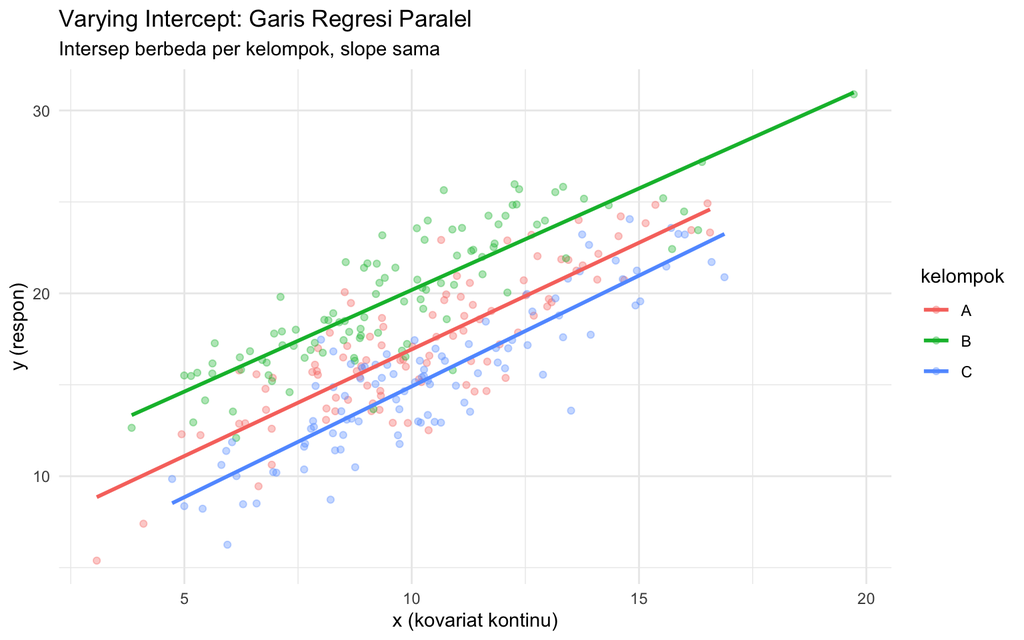

```r
dat_vi %>%
  ggplot(aes(x, y, color = kelompok)) +
  geom_point(alpha = 0.35) +
  geom_smooth(method = "lm", se = FALSE) +
  labs(title = "Varying Intercept: Garis Regresi Paralel",
       subtitle = "Intersep berbeda per kelompok, slope sama",
       x = "x (kovariat kontinu)", y = "y (respon)") +
  theme_minimal()
```

### 4.7.3 Prediksi Per Kelompok

Gunakan `modelr::add_predictions` untuk menggambar garis prediksi terpisah—tetap sejajar.

```r
grid_vi <- dat_vi %>%
  group_by(kelompok) %>%
  summarize(x = seq(min(x), max(x), length.out = 50), .groups = "drop")

pred_vi <- grid_vi %>%
  add_predictions(m_vi)

pred_vi %>% head() %>% knitr::kable() %>% kable_styling(full_width = FALSE)
```

| kelompok | x | pred |
| --- | --- | --- |
| A | 3.072493 | 8.885044 |
| A | 3.347789 | 9.205055 |
| A | 3.623085 | 9.525066 |
| A | 3.898382 | 9.845076 |
| A | 4.173678 | 10.165087 |
| A | 4.448974 | 10.485098 |

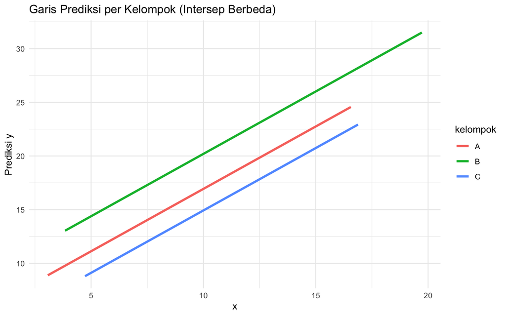

```r
pred_vi %>%
  ggplot(aes(x, pred, color = kelompok)) +
  geom_line(size = 1.2) +
  labs(title = "Garis Prediksi per Kelompok (Intersep Berbeda)",
       x = "x", y = "Prediksi y") +
  theme_minimal()
```

## 4.8 Regresi: Kemiringan Berbeda (Interaksi Dummy–Kontinu)

Model umum:
$$y_i = \beta_0 + \beta_1 x_i + \gamma_1 D_{B,i} + \gamma_2 D_{C,i} +
\delta_1 (x_i \cdot D_{B,i}) + \delta_2 (x_i \cdot D_{C,i}) +
\varepsilon_i.$$

- `x:kelompokB` mengukur **selisih slope** B vs A.
- `x:kelompokC` mengukur **selisih slope** C vs A.
- Intersep untuk B/C juga bisa berbeda jika kita sertakan `kelompok` tanpa interaksi—dan memang kita sertakan (sehingga model lengkap).

```r
m_vs <- lm(y ~ x * kelompok, data = dat_vs)
summary(m_vs)
```

```
##
## Call:
## lm(formula = y ~ x * kelompok, data = dat_vs)
##
## Residuals:
##     Min      1Q  Median      3Q     Max
## -4.8955 -1.4285 -0.0354  1.0557  6.3866
##
## Coefficients:
##             Estimate Std. Error t value Pr(>|t|)
## (Intercept)  8.09095    0.66795  12.113  < 2e-16 ***
## x            0.78646    0.06658  11.812  < 2e-16 ***
## kelompokB   -0.88729    0.98845  -0.898    0.370
## kelompokC   -0.03020    0.96732  -0.031    0.975
## x:kelompokB  0.81397    0.09501   8.567 6.09e-16 ***
## x:kelompokC -0.49610    0.09311  -5.328 1.98e-07 ***
## ---
## Signif. codes:  0 '***' 0.001 '**' 0.01 '*' 0.05 '.' 0.1 ' ' 1
##
## Residual standard error: 2.044 on 294 degrees of freedom
## Multiple R-squared:  0.9015, Adjusted R-squared:  0.8998
## F-statistic: 537.9 on 5 and 294 DF,  p-value: < 2.2e-16
```

### 4.8.1 Interpretasi

- `(Intercept)`: intersep baseline (A) saat `x=0`. Jika `x` jauh dari nol, pertimbangkan **mean-centering** pada `x` agar intersep lebih bermakna.
- `x`: slope untuk baseline (A).
- `kelompokB`, `kelompokC`: perbedaan intersep pada `x=0` antara B/C dan A.
- `x:kelompokB`, `x:kelompokC`: **perbedaan slope** B/C vs A.

### 4.8.2 Visualisasi: Garis Berpotongan

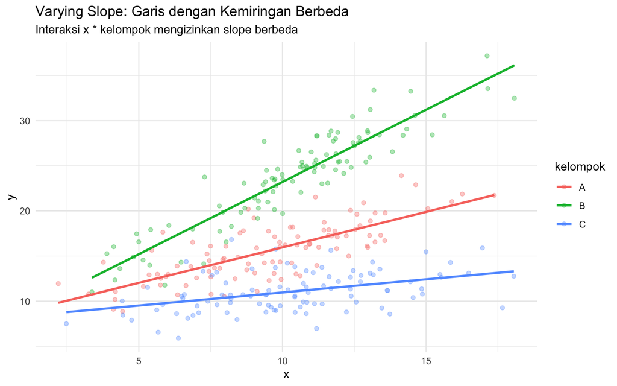

```r
dat_vs %>%
  ggplot(aes(x, y, color = kelompok)) +
  geom_point(alpha = 0.35) +
  geom_smooth(method = "lm", se = FALSE) +
  labs(title = "Varying Slope: Garis dengan Kemiringan Berbeda",
       subtitle = "Interaksi x * kelompok mengizinkan slope berbeda",
       x = "x", y = "y") +
  theme_minimal()
```

### 4.8.3 Centring: Membuat Intersep Lebih Bermakna

```r
dat_vs_c <- dat_vs %>% mutate(x_c = x - mean(x))
m_vs_c <- lm(y ~ x_c * kelompok, data = dat_vs_c)
broom::tidy(m_vs_c) %>% knitr::kable(digits = 3) %>% kable_styling(full_width = FALSE)
```

| term | estimate | std.error | statistic | p.value |
| --- | --- | --- | --- | --- |
| (Intercept) | 15.995 | 0.207 | 77.256 | 0 |
| x_c | 0.786 | 0.067 | 11.812 | 0 |
| kelompokB | 7.293 | 0.291 | 25.021 | 0 |
| kelompokC | -5.016 | 0.291 | -17.219 | 0 |
| x_c:kelompokB | 0.814 | 0.095 | 8.567 | 0 |
| x_c:kelompokC | -0.496 | 0.093 | -5.328 | 0 |

Dengan `x_c`, `(Intercept)` sekarang merepresentasikan **rata-rata `y` pada `x` rata-rata** untuk baseline. Koefisien interaksi tidak berubah interpretasinya (tetap selisih slope).

## 4.9 Interaksi Dummy–Dummy (Efek Perlakuan Berbeda per Kelompok)

Model:
$$y = \beta_0 + \beta_1 x + \tau \cdot \text{treat} + \gamma_B D_B +
\gamma_C D_C
+ \eta_B (\text{treat}\cdot D_B) + \eta_C (\text{treat}\cdot D_C) +
\varepsilon.$$

- `treat` adalah dummy 0/1, baseline efeknya berlaku pada kelompok A.
- `treat:kelompokB` adalah tambahan efek treat **khusus** di B (di atas baseline A).
- `treat:kelompokC` tambahan efek treat **khusus** di C.

```r
m_dd <- lm(y ~ x + treat * kelompok, data = dat_dd)
summary(m_dd)
```

```
##
## Call:
## lm(formula = y ~ x + treat * kelompok, data = dat_dd)
##
## Residuals:
##     Min      1Q  Median      3Q     Max
## -5.5744 -1.2409  0.0103  1.3311  5.8518
##
## Coefficients:
##                 Estimate Std. Error t value Pr(>|t|)
## (Intercept)      5.54592    0.33554  16.528  < 2e-16 ***
## x                1.00886    0.02634  38.301  < 2e-16 ***
## treat            2.25936    0.27511   8.213 1.36e-15 ***
## kelompokB        0.55336    0.27145   2.039  0.04194 *
## kelompokC        0.36787    0.27502   1.338  0.18153
## treat:kelompokB  0.92275    0.38884   2.373  0.01796 *
## treat:kelompokC -1.28031    0.38872  -3.294  0.00105 **
## ---
## Signif. codes:  0 '***' 0.001 '**' 0.01 '*' 0.05 '.' 0.1 ' ' 1
##
## Residual standard error: 1.943 on 593 degrees of freedom
## Multiple R-squared:  0.7419, Adjusted R-squared:  0.7392
## F-statistic:   284 on 6 and 593 DF,  p-value: < 2.2e-16
```

### 4.9.1 Menghitung Efek Treat per Kelompok

```r
library(dplyr)
library(broom)
library(knitr)
library(kableExtra)

coefs <- broom::tidy(m_dd) %>%
  dplyr::select(term, estimate)

tau_A <- coefs %>% filter(term == "treat") %>% pull(estimate)
tau_B <- tau_A + (coefs %>% filter(term == "treat:kelompokB") %>% pull(estimate))
tau_C <- tau_A + (coefs %>% filter(term == "treat:kelompokC") %>% pull(estimate))

tibble(
  Kelompok = c("A", "B", "C"),
  Efek_Treat = c(tau_A, tau_B, tau_C)
) %>%
  knitr::kable(digits = 3) %>%
  kableExtra::kable_styling(full_width = FALSE)
```

| Kelompok | Efek_Treat |
| --- | --- |
| A | 2.259 |
| B | 3.182 |
| C | 0.979 |

### 4.9.2 Visualisasi: *Difference-in-Differences* ala Sederhana

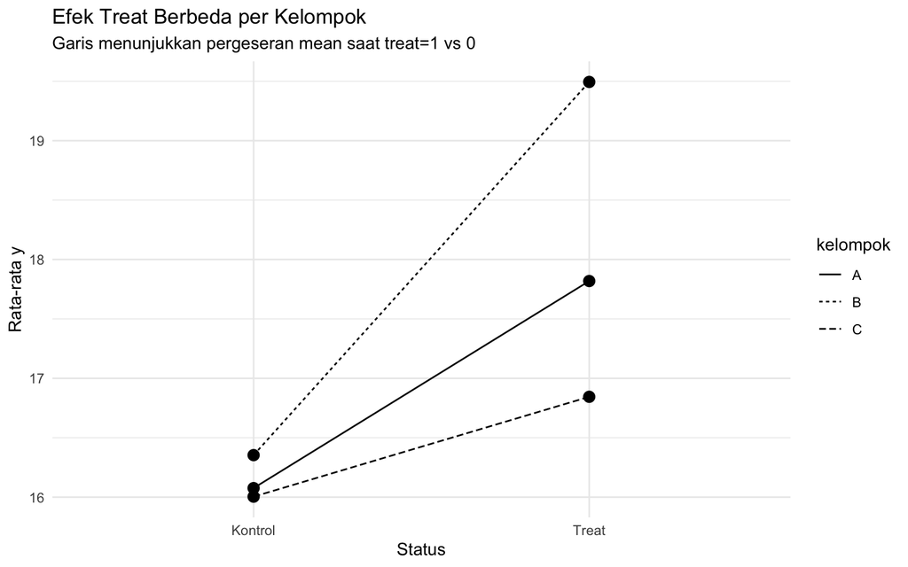

```r
dat_dd %>%
  group_by(kelompok, treat) %>%
  summarize(mean_y = mean(y), .groups = "drop") %>%
  mutate(treat = factor(treat, levels = c(0,1), labels = c("Kontrol","Treat"))) %>%
  ggplot(aes(treat, mean_y, group = kelompok, linetype = kelompok)) +
  geom_point(size = 3) +
  geom_line() +
  labs(title = "Efek Treat Berbeda per Kelompok",
       subtitle = "Garis menunjukkan pergeseran mean saat treat=1 vs 0",
       x = "Status", y = "Rata-rata y") +
  theme_minimal()
```

## 4.10 Banyak Dummy: Kategori dengan Banyak Level

Jika `region` punya 4 level, R akan membangun otomatis 3 dummy (k-1) dengan baseline `R1`. Lihat `model.matrix()` untuk memahami konstruksinya.

```r
MM <- model.matrix(~ region, data = dat_region)
head(MM) %>% knitr::kable() %>% kable_styling(full_width = FALSE)
```

| (Intercept) | regionR2 | regionR3 | regionR4 |
| --- | --- | --- | --- |
| 1 | 1 | 0 | 0 |
| 1 | 0 | 0 | 1 |
| 1 | 0 | 0 | 0 |
| 1 | 0 | 0 | 0 |
| 1 | 0 | 0 | 0 |
| 1 | 0 | 0 | 0 |

### 4.10.1 Pasang Model dan Interpretasi

```r
m_region <- lm(y ~ x + region, data = dat_region)
summary(m_region)
```

```
##
## Call:
## lm(formula = y ~ x + region, data = dat_region)
##
## Residuals:
##     Min      1Q  Median      3Q     Max
## -5.6656 -1.0873  0.1228  1.2255  4.4737
##
## Coefficients:
##             Estimate Std. Error t value Pr(>|t|)
## (Intercept)  7.65097    0.35811  21.365  < 2e-16 ***
## x            1.06411    0.03446  30.879  < 2e-16 ***
## regionR2     1.46181    0.25310   5.776 1.55e-08 ***
## regionR3    -1.78943    0.24857  -7.199 3.08e-12 ***
## regionR4     0.16767    0.24540   0.683    0.495
## ---
## Signif. codes:  0 '***' 0.001 '**' 0.01 '*' 0.05 '.' 0.1 ' ' 1
##
## Residual standard error: 1.773 on 395 degrees of freedom
## Multiple R-squared:  0.7264, Adjusted R-squared:  0.7236
## F-statistic: 262.2 on 4 and 395 DF,  p-value: < 2.2e-16
```

Interpretasi: - `(Intercept)`: intersep untuk `R1` (baseline). - `regionR2`,`regionR3`,`regionR4`: perbedaan intersep relatif `R1`. - `x`: slope yang sama untuk semua region (karena belum ada interaksi dengan `region`).

### 4.10.2 Visualisasi

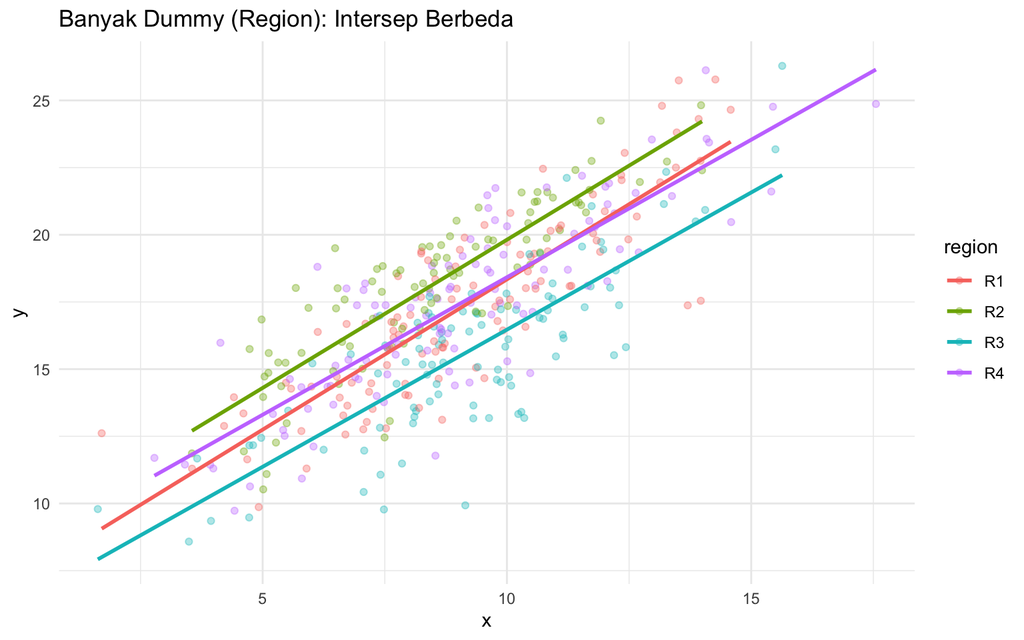

```r
dat_region %>%
  ggplot(aes(x, y, color = region)) +
  geom_point(alpha = 0.35) +
  geom_smooth(method = "lm", se = FALSE) +
  labs(title = "Banyak Dummy (Region): Intersep Berbeda",
       x = "x", y = "y") +
  theme_minimal()
```

## 4.11 Interaksi Lebih Lanjut

### 4.11.1 Interaksi Faktor × Faktor (k × m level)

Jika dua faktor masing-masing memiliki $k$ dan $m$ level, interaksi akan menghasilkan $(k-1)\times(m-1)$ koefisien tambahan (di atas main effects), karena semua koefisien didefinisikan relatif terhadap baseline ganda.

Contoh: `kelompok (A/B/C)` × `region (R1–R4)` memerlukan banyak koefisien. Gunakan ini **hanya bila perlu**, atau ketika ada hipotesis teoritis yang meyakinkan mengenai heterogenitas efek.

```r
dat_big <- expand_grid(
  kelompok = factor(c("A","B","C")),
  region = factor(paste0("R",1:4))
) %>%
  mutate(
    # simulasi intersep unik per kombinasi (sekadar contoh)
    mu = c(5,6,7,8, 4,6,6.5,7.5, 5.5,5,6.7,7.2)
  )

# Gabungkan dengan x acak dan noise
set.seed(42)
dat_big <- dat_big %>%
  group_by(kelompok, region) %>%
  do({
    tibble(
      x = rnorm(80, 10, 2.5),
      y = .$mu + 1.1 * x + rnorm(80,0,2)
    )
  }) %>% ungroup()

m_big <- lm(y ~ x + kelompok * region, data = dat_big)
broom::glance(m_big) %>% knitr::kable() %>% kable_styling(full_width = FALSE)
```

| r.squared | adj.r.squared | sigma | statistic | p.value | df | logLik | AIC | BIC | deviance | df.residual | nobs |
| --- | --- | --- | --- | --- | --- | --- | --- | --- | --- | --- | --- |
| 0.7223359 | 0.7188174 | 1.965931 | 205.2996 | 0 | 12 | -2004.564 | 4037.128 | 4105.265 | 3660.047 | 947 | 960 |

### 4.11.2 Plot Interaksi

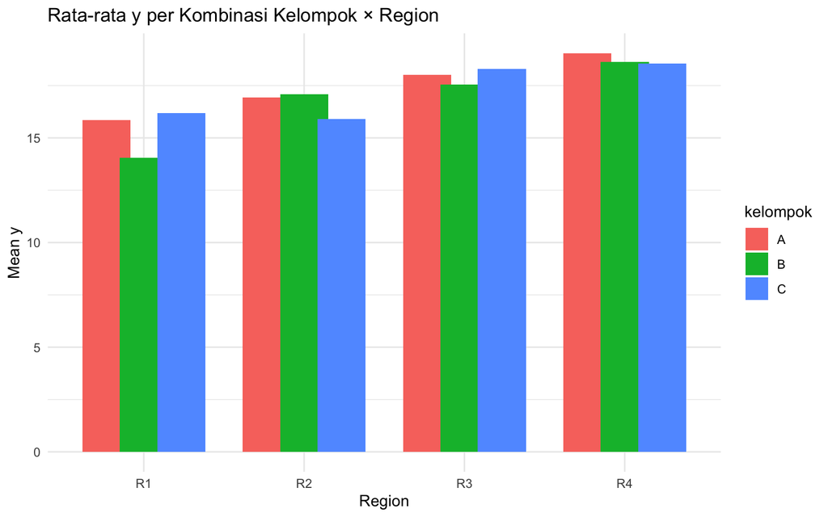

```r
dat_big %>%
  group_by(kelompok, region) %>%
  summarize(mean_y = mean(y), .groups = "drop") %>%
  ggplot(aes(region, mean_y, fill = kelompok)) +
  geom_col(position = position_dodge(width = 0.7)) +
  labs(title = "Rata-rata y per Kombinasi Kelompok × Region",
       x = "Region", y = "Mean y") +
  theme_minimal()
```

## 4.12 Mengapa Menggunakan Dummy?

1. **Merepresentasikan kategori**: Tanpa dummy, faktor kategorikal tak akan masuk ke regresi linier klasik.
2. **Kontras**: Dummy memungkinkan kita mengestimasi *perbedaan rata-rata* antar kelompok (intersep berbeda).
3. **Heterogenitas efek**: Interaksi dummy–kontinu dan dummy–dummy membuat kita bisa menangkap **efek yang tidak homogen** (misalnya kebijakan lebih efektif di satu provinsi daripada yang lain).
4. **Keterbacaan kebijakan**: Koefisien dummy adalah selisih yang mudah dijelaskan ke non-teknis.
5. **Kontrol confounding**: Menambahkan dummy untuk kategori yang relevan dapat mengurangi bias karena variabel konfonder terklasifikasi (misal tahun, musim, batch eksperimen).

## 4.13 Praktik Terbaik dan Jebakan

- **Baseline yang jelas**: Ingat, interpretasi dummy selalu relatif terhadap baseline. Pilih baseline yang paling umum atau paling bermakna substantif.
- **Dummy Variable Trap**: Jangan masukkan semua dummy **dan** intersep sekaligus. R default aman, tetapi hati-hati saat membuat dummy manual.
- **Unbalanced data**: Jika satu level jarang, estimasi interaksi bisa tak stabil. Pertimbangkan penggabungan level atau regularisasi.
- **Centering**: Untuk interaksi dummy–kontinu, *centering* `x` memudahkan interpretasi intersep.
- **P-value vs ukuran efek**: Jangan terpaku pada signifikansi. Plot selalu membantu. Ukuran efek (perbedaan rata-rata, slope) lebih komunikatif.
- **Robust SE**: Pada data heteroskedastik, gunakan `sandwich::vcovHC` + `lmtest::coeftest` untuk SE robust.
- **Kausalitas**: Dummy *treat* tidak otomatis kausal. Butuh desain (randomisasi, DiD, IV, RDD). Di sini kita fokus deskriptif/regresif.

```r
library(lmtest)
library(sandwich)
coeftest(m_vi, vcov = vcovHC(m_vi, type = "HC3"))
```

```
##
## t test of coefficients:
##
##              Estimate Std. Error t value  Pr(>|t|)
## (Intercept)  5.313504   0.475758  11.168 < 2.2e-16 ***
## x            1.162424   0.039543  29.396 < 2.2e-16 ***
## kelompokB    3.261833   0.293718  11.105 < 2.2e-16 ***
## kelompokC   -2.008766   0.282171  -7.119 8.263e-12 ***
## ---
## Signif. codes:  0 '***' 0.001 '**' 0.01 '*' 0.05 '.' 0.1 ' ' 1
```

## 4.14 Ringkasan Interpretasi Koefisien

- **Model tanpa interaksi**:  
  $\hat{y} = \hat{\beta}_0 + \hat{\beta}_1 x + \hat{\gamma}_B D_B + \hat{\gamma}_C D_C$
  - `Intercept`: mean untuk baseline saat $x=0$.
  - `x`: slope umum.
  - `D_B`: selisih mean (intersep) B vs A.
  - `D_C`: selisih mean (intersep) C vs A.
- **Model dengan interaksi dummy–kontinu**:  
  $\hat{y} = \hat{\beta}_0 + \hat{\beta}_1 x + \hat{\gamma}_B D_B + \hat{\gamma}_C D_C + \hat{\delta}_B xD_B + \hat{\delta}_C xD_C$
  - Slope A = $\hat{\beta}_1$
  - Slope B = $\hat{\beta}_1 + \hat{\delta}_B$
  - Slope C = $\hat{\beta}_1 + \hat{\delta}_C$
- **Model treat × kelompok**:  
  Efek treat pada A = `treat`  
  Efek treat pada B = `treat` + `treat:kelompokB`  
  Efek treat pada C = `treat` + `treat:kelompokC`

## 4.15 Contoh Aplikasi Mini

### 4.15.1 Evaluasi Kebijakan (Sebelum–Sesudah vs Kelompok)

Misalkan `treat`=1 sesudah kebijakan. Interaksi `treat * kelompok` memeriksa apakah dampak kebijakan berbeda antar kelompok. Cocok untuk *heterogeneous treatment effects* (HTE).

### 4.15.2 Bisnis & Pemasaran

`kelompok` = kanal penjualan; `x` = anggaran iklan. Interaksi `x * kanal` memberitahu kanal mana yang lebih responsif terhadap iklan (slope lebih curam).

## 4.16 Kesehatan Lingkungan

`region` sebagai provinsi; `x` = polutan; `kelompok` = kebijakan emisi (ya/tidak). Interaksi menangkap apakah hubungan polutan–outcome tergantung status kebijakan.

## 4.17 Diagnostik

Regresi linier standar mensyaratkan asumsi residual “sehat”. Kita cek cepat pada salah satu model.

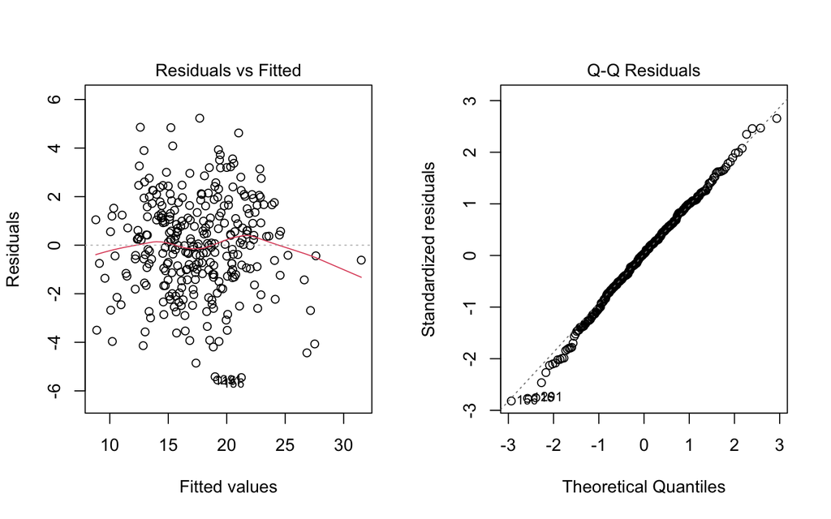

```r
par(mfrow = c(1,2))
plot(m_vi, which = 1) # residual vs fitted
plot(m_vi, which = 2) # QQ plot
```

```r
par(mfrow = c(1,1))
```

## 4.18 Epilog

Variabel dummy itu seperti saklar: kecil, tapi mengubah aliran arus interpretasi. Dengan intersep berbeda, kita akui tiap kelompok punya “titik awal” berbeda. Dengan slope berbeda, kita izinkan kelompok merespons perubahan `x` secara unik. Dengan interaksi, kita menangkap dialektika antar variabel—*kapan efek ini tergantung pada yang itu*.

Jika Anda mengajar, plot–plot di atas adalah *alat retoris* yang sangat kuat: tidak sekadar berkata “koefisien beda”, tetapi **menunjukkan** garis yang benar‑benar beda. Dan bila suatu saat ada yang bilang “dummy itu cuma 0/1”, Anda sudah tahu balasannya: *betul—namun 0/1 yang bisa menceritakan 1001 cerita.*

# 5 **Panel Data**

Data panel adalah *dua dimensi kebahagiaan statistik*: kita mengamati banyak **unit** (individu, perusahaan, provinsi) berulang kali pada banyak **periode waktu**. Keuntungan utama:

- Mengendalikan heterogenitas tak-teramati yang **konstan** terhadap waktu (mis. bakat manajer, kultur daerah).
- Mengurangi kolinearitas dan meningkatkan *degrees of freedom*.
- Mengizinkan dinamika temporal (lag, tren) dan struktur korelasi yang realistis.

Dokumen ini menyajikan **panduan komprehensif** untuk tiga model klasik regresi panel:

1. **Pooled OLS** (semua data “digabung” seakan-akan *cross-section* besar).
2. **Fixed Effects (FE)** — efek tetap per unit dan/atau waktu.
3. **Random Effects (RE)** — efek acak per unit dan/atau waktu.

Kita juga membahas perbedaan **format data wide vs long**, proses transformasi, pilihan model, uji-uji penting (LM Breusch–Pagan, F-test FE, Hausman), serta praktik terbaik (SE robust, klaster, diagnostik dependensi serial dan ketergantungan silang). Semua disertai **simulasi data**, **kode R**, dan **visualisasi**.

## 5.1 Paket yang Digunakan

```r
library(tidyverse)
library(plm)         # jagoan panel
library(lmtest)      # uji diagnostik
library(sandwich)    # robust vcov
library(broom)       # ringkasan tabel
library(knitr)
library(kableExtra)
library(scales)
set.seed(123)
```

## 5.2 Struktur Data Panel: Wide vs Long

Sebelum membicarakan model, pastikan format data jelas.

### 5.2.1 Format **Long** (Panel “Ramah-Model”)

Format **long** memiliki kolom pengenal unit (mis. `id`), pengenal waktu (mis. `year`), lalu kolom-kolom variabel:

```
id | year | y | x1 | x2 | z ...
1  | 2018 | . | .  | .  | .
1  | 2019 | . | .  | .  | .
...
2  | 2018 | . | .  | .  | .
```

Sebagian besar fungsi panel (`plm`, `fixest`, `lfe`) menyukai format ini.

### 5.2.2 Format **Wide** (Melebar ke Samping)

Format **wide** menaruh setiap periode sebagai kolom berbeda:

```
id | y_2018 | y_2019 | y_2020 | x1_2018 | x1_2019 | ...
1  |   .    |   .    |   .    |    .    |    .    | ...
2  |   .    |   .    |   .    |    .    |    .    | ...
```

Format ini enak untuk melihat *snapshot* antar-periode sekaligus, tetapi perlu diubah ke long untuk dianalisis dengan mudah.

### 5.2.3 Transformasi Wide ↔︎ Long

```r
# Contoh mini untuk transformasi
wide_df <- tibble(
  id = 1:3,
  y_2018 = c(10, 12, 9),
  y_2019 = c(11, 15, 10),
  x_2018 = c(3, 4, 3.5),
  x_2019 = c(3.3, 4.2, 3.7)
)

# Wide -> Long
long_df <- wide_df %>%
  pivot_longer(cols = -id, names_to = "var", values_to = "value") %>%
  separate(var, into = c("name", "year"), sep = "_") %>%
  pivot_wider(names_from = name, values_from = value) %>%
  mutate(year = as.integer(year)) %>%
  arrange(id, year)

long_df %>% kable() %>% kable_styling(full_width = FALSE)
```

| id | year | y | x |
| --- | --- | --- | --- |
| 1 | 2018 | 10 | 3.0 |
| 1 | 2019 | 11 | 3.3 |
| 2 | 2018 | 12 | 4.0 |
| 2 | 2019 | 15 | 4.2 |
| 3 | 2018 | 9 | 3.5 |
| 3 | 2019 | 10 | 3.7 |

> Ingat: **long** adalah format kerja utama untuk model panel.

## 5.3 Simulasi Data Panel

Kita bangun data yang “masuk akal” untuk mendemonstrasikan pooled, FE, dan RE.

- Unit: 60 perusahaan (id = 1..60).
- Periode: 6 tahun (t = 2018..2023).
- Variabel: `y` (kinerja), `x1` (belanja R&D), `x2` (leverage), `z` (shock makro tahunan).
- Ada **heterogenitas unit** via `alpha_i` (waktu-tetap) dan **tren waktu** via `lambda_t`.

```r
library(dplyr)
library(tidyr)
library(kableExtra)

set.seed(123)

N   <- 60   # unit
Tt  <- 6    # time periods
years <- 2018:(2018 + Tt - 1)

panel <- expand.grid(id = 1:N, year = years) %>%
  arrange(id, year)

# Komponen tak teramati: efek tetap unit dan efek tetap waktu
alpha_i  <- rnorm(N, sd = 1.2)                 # heterogenitas per unit (tetap)
lambda_t <- seq(-0.5, 0.5, length.out = Tt)    # tren waktu linear halus

# (Opsional) buat kamus tahun -> lambda
year_map <- tibble(
  year   = years,
  lambda = lambda_t
)

# Kovariat observabel + gabungkan komponen
# Gunakan match / left_join agar setiap baris mendapatkan scalar 'alpha' dan 'lambda'
panel <- panel %>%
  mutate(
    x1 = rlnorm(n(), meanlog = log(5), sdlog = 0.3),   # eksponensial-positif
    x2 = rnorm(n(), mean = 0, sd = 1),                 # leverage ~ N(0,1)
    z  = rep(rnorm(Tt, 0, 0.5), each = N)              # shock makro tahunan (sama untuk semua unit pada t)
  ) %>%
  # alpha_i per unit (scalar per baris)
  mutate(alpha = alpha_i[id]) %>%
  # lambda_t per tahun (scalar per baris) — pilih salah satu:
  # 1) via match:
  mutate(lambda = lambda_t[match(year, years)])
  # 2) atau pakai join (komentari baris match di atas, lalu pakai ini):
  # left_join(year_map, by = "year")
  # (setelah join, 'lambda' sudah ada sebagai kolom)

# True DGP (data generating process)
beta0 <- 1.5
beta1 <- 0.6      # x1
beta2 <- -0.4     # x2
beta3 <- 0.8      # z

# Error & outcome
panel <- panel %>%
  mutate(
    u = rnorm(n(), 0, 0.8),
    y = beta0 + beta1*x1 + beta2*x2 + beta3*z + alpha + lambda + u
  )

# Tampilkan cuplikan
panel %>%
  head() %>%
  knitr::kable() %>%
  kable_styling(full_width = FALSE)
```

| id | year | x1 | x2 | z | alpha | lambda | u | y |
| --- | --- | --- | --- | --- | --- | --- | --- | --- |
| 1 | 2018 | 5.603155 | 1.7795029 | 0.4067002 | -0.6725708 | -0.5 | 0.6379044 | 3.940785 |
| 1 | 2019 | 4.300541 | 0.2864244 | 0.4067002 | -0.6725708 | -0.3 | -1.5665641 | 1.751980 |
| 1 | 2020 | 4.524358 | 0.1263159 | 0.4067002 | -0.6725708 | -0.1 | -1.5090601 | 2.207818 |
| 1 | 2021 | 3.683507 | 1.2722668 | 0.4067002 | -0.6725708 | 0.1 | -0.5230239 | 2.430963 |
| 1 | 2022 | 3.625168 | -0.7184662 | 0.4067002 | -0.6725708 | 0.3 | 0.3155159 | 4.230792 |
| 1 | 2023 | 5.476666 | -0.4503386 | 0.4067002 | -0.6725708 | 0.5 | -0.7308528 | 4.388071 |

Secara desain, `alpha_i` berkorelasi **positif** dengan `x1` (karena firm yang “bagus” cenderung belanja R&D lebih besar). Untuk memperjelas endogenitas halus ini, kita tambahkan korelasi ringan:

```r
# Memperkenalkan korelasi ringan antara alpha_i dan x1:
panel <- panel %>% group_by(id) %>%
  mutate(x1 = x1 + 0.2*alpha[1]) %>%
  ungroup()

# Rehitung y agar konsisten
panel <- panel %>% mutate(y = beta0 + beta1*x1 + beta2*x2 + beta3*z + alpha + lambda + u)
```

## 5.4 Visualisasi

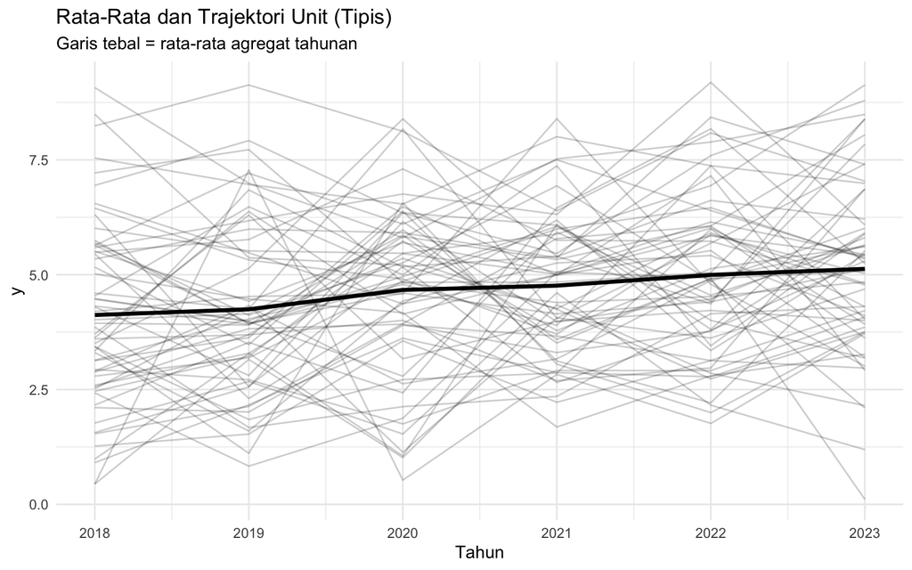

```r
ggplot(panel, aes(year, y, group = id)) +
  geom_line(alpha = 0.2) +
  stat_summary(aes(group = 1), fun = mean, geom = "line", size = 1.2) +
  labs(title = "Rata-Rata dan Trajektori Unit (Tipis)",
       subtitle = "Garis tebal = rata-rata agregat tahunan",
       x = "Tahun", y = "y") +
  theme_minimal()
```

## 5.5 Mempersiapkan Objek Panel

`plm` menyukai objek `pdata.frame` dengan indeks (`id`, `year`).

```r
pdata <- pdata.frame(panel, index = c("id","year"))
```

## 5.6 **Pooled OLS**

Anggap data panel cuma data *cross-section besar*. Abaikan efek tetap/acak.

Model:
$$y_{it} = \beta_0 + \beta_1 x1_{it} + \beta_2 x2_{it} + \beta_3 z_t +
\varepsilon_{it}$$

```r
pooled <- plm(y ~ x1 + x2 + z, data = pdata, model = "pooling")
summary(pooled)
```

```
## Pooling Model
##
## Call:
## plm(formula = y ~ x1 + x2 + z, data = pdata, model = "pooling")
##
## Balanced Panel: n = 60, T = 6, N = 360
##
## Residuals:
##      Min.   1st Qu.    Median   3rd Qu.      Max.
## -3.312435 -0.958148  0.012376  0.901359  4.337458
##
## Coefficients:
##              Estimate Std. Error t-value  Pr(>|t|)
## (Intercept)  1.076380   0.244307  4.4058 1.396e-05 ***
## x1           0.702449   0.044590 15.7535 < 2.2e-16 ***
## x2          -0.364761   0.072186 -5.0531 6.963e-07 ***
## z            0.769942   0.164609  4.6774 4.132e-06 ***
## ---
## Signif. codes:  0 '***' 0.001 '**' 0.01 '*' 0.05 '.' 0.1 ' ' 1
##
## Total Sum of Squares:    1223.3
## Residual Sum of Squares: 666.95
## R-Squared:      0.45481
## Adj. R-Squared: 0.45021
## F-statistic: 98.9934 on 3 and 356 DF, p-value: < 2.22e-16
```

Masalah potensial:

- **Omitted Heterogeneity**: jika $x$ berkorelasi dengan karakteristik unit yang tak-teramati (konsisten waktu), OLS menjadi **bias**.
- **Serial Correlation**: error dalam unit yang sama lintas waktu sering berkorelasi.
- **Heteroskedastisitas**: varians tak konstan antar unit/waktu.

Solusi minimal: gunakan **SE robust berklaster** (klaster pada `id`).

```r
coeftest(pooled, vcov = vcovHC(pooled, type = "HC1", cluster = "group"))
```

```
##
## t test of coefficients:
##
##              Estimate Std. Error t value  Pr(>|t|)
## (Intercept)  1.076380   0.252806  4.2577 2.645e-05 ***
## x1           0.702449   0.043189 16.2647 < 2.2e-16 ***
## x2          -0.364761   0.062895 -5.7995 1.469e-08 ***
## z            0.769942   0.322614  2.3866   0.01753 *
## ---
## Signif. codes:  0 '***' 0.001 '**' 0.01 '*' 0.05 '.' 0.1 ' ' 1
```

## 5.7 **Fixed Effects (FE)**

### 5.7.1 Fixed Effect Model vs Endogeneity

Dokumen ini menjelaskan hubungan **panel data** dengan **endogeneity**, serta mengapa **model efek tetap (fixed effects, FE)** kerap dianggap solusi—walau hanya **parsial**—untuk isu endogeneity. Pembahasan mencakup intuisi, formulasi matematis, equivalence dua pendekatan FE (within vs LSDV), keterbatasan FE, dan demonstrasi simulasi kecil di R.

**Ringkasan Eksekutif**

- **Endogeneity** terjadi ketika variabel penjelas berkorelasi dengan galat, lazim karena *omitted variable bias*, *simultaneity*, atau *measurement error*.
- **Panel data** memungkinkan kita mengamati entitas yang sama berulang kali, sehingga karakteristik **tak teramati yang tetap dalam waktu** (time-invariant) dapat dikendalikan.
- **Fixed effects (FE)** secara **konseptual mengakui** adanya efek individu tetap \((\alpha_i)\), tetapi **menghilangkannya secara matematis** melalui transformasi *within/demeaning*, atau **memasukkannya secara eksplisit** melalui dummy (LSDV). Kedua pendekatan memberikan estimasi koefisien \(\beta\) yang ekuivalen.
- FE **menangani endogeneity yang bersumber dari omitted variables yang time-invariant**, namun **tidak** menyelesaikan endogeneity karena **simultaneity** atau **measurement error**. Untuk itu, gunakan IV, DiD, atau dynamic panel GMM.
- Simulasi kecil menunjukkan: ketika efek individu berkorelasi dengan \(X\), OLS *pooled* menjadi bias; FE mengoreksi bias tersebut.

**Apa itu Endogeneity?** Secara umum, endogeneity adalah kondisi ketika variabel penjelas \(X\) **berkorelasi** dengan *error term* \(\varepsilon\) dalam model regresi. Sumber utama:

1. **Omitted Variable Bias (OVB)**: ada faktor relevan yang tidak dimasukkan ke model.
2. **Simultaneity**: sebab–akibat terjadi dua arah (\(X \leftrightarrow Y\)).
3. **Measurement Error**: kesalahan pengukuran pada variabel kunci (sering di \(X\)).

Konsekuensinya: estimasi OLS menjadi **bias** dan **tidak konsisten**.

**Di mana Panel Data Membantu?** Panel data menggabungkan dimensi **individu** (atau entitas) dan **waktu**. Dengan mengamati individu yang sama berulang kali, kita bisa mengontrol faktor **tak teramati** yang **tidak berubah dalam waktu** (misal: bakat manajerial, budaya organisasi, lokasi tetap). Inilah sumber endogeneity yang paling sering mengganggu analisis *cross-section* murni.

**3. Model Fixed Effects: Formulasi dan Intuisi** Misalkan model dasar: \[ Y_{it} = \alpha_i + \beta X_{it} + \varepsilon_{it}, \quad i=1,\dots,N;\; t=1,\dots,T. \]

- \(\alpha_i\): efek tetap individu (time-invariant, tidak teramati).
- \(X_{it}\): variabel penjelas yang bervariasi lintas waktu dan/atau individu.
- \(\varepsilon_{it}\): galat idiosinkratik yang tidak berkorelasi dengan \(X_{it}\) *setelah* mengontrol \(\alpha_i\).

**Asumsi kunci FE**: setelah mengondisikan pada \(\alpha_i\), tidak ada korelasi antara \(X_{it}\) dan \(\varepsilon_{it}\). Korelasi antara \(\alpha_i\) dan \(X_{it}\) **diperbolehkan**.

*Within (Demeaning) Transformation* Ambil rata-rata per individu: \[ \bar{Y}_i = \alpha_i + \beta \bar{X}_i + \bar{\varepsilon}_i. \]

Kurangkan dari persamaan asli:
$$(Y_{it} - \bar{Y}_{i}) = \beta (X_{it} - \bar{X}_{i}) +
(\varepsilon_{it} - \bar{\varepsilon}_{i})$$

Karena $\alpha_i$ bersifat konstan untuk setiap individu $i$ dan tidak berubah sepanjang waktu, maka ketika setiap variabel dikurangi dengan rata-ratanya ($\bar{Y}_{i}, \bar{X}_{i}$), komponen $\alpha_i$ akan tereliminasi secara sempurna dari persamaan. Dengan demikian, variasi yang tersisa hanya mencerminkan perubahan **dalam individu (within variation)**, bukan perbedaan antarindividu.

Inilah maksud frasa “FE menghilangkan \(\alpha_i\)”.

*LSDV (Least-Squares Dummy Variables)* Alternatif ekuivalen: masukkan dummy untuk tiap individu (kecuali satu untuk menghindari dummy trap): \[ Y_{it} = \beta X_{it} + \sum_{i=1}^{N-1} \alpha_i D_i + \varepsilon_{it}. \] Di sini, \(\alpha_i\) **dimasukkan secara eksplisit**. Secara teori, estimasi \(\beta\) dari LSDV **ekuivalen** dengan hasil *within transformation*.

> **Inti klarifikasi**: FE **mengakui** \(\alpha_i\) (efek individu tetap), namun **menghapusnya secara aljabar** (via demeaning) saat menaksir \(\beta\).

**Kapan FE Menyelesaikan Endogeneity?** FE efektif untuk **OVB yang time-invariant**. Contoh: - “Budaya perusahaan” yang tak terukur tetapi relatif tetap selama periode studi. - Perbedaan lokasi geografis tetap. - Karakteristik bawaan individu (mis. kemampuan kognitif dasar).

Dengan FE, sumber bias ini **tereliminasi** dari persamaan sehingga \(\beta\) tidak lagi tercemar oleh korelasi \(\alpha_i\)–\(X_{it}\).

**Kapan FE Tidak Cukup?** FE **tidak** menyelesaikan: - **Simultaneity (reverse causality)**: jika \(Y\) juga memengaruhi \(X\) pada waktu yang sama, maka \(X_{it}\) tetap berkorelasi dengan galat (meski \(\alpha_i\) sudah “dibersihkan”). - **Time-varying omitted variables**: ada faktor tak teramati **berubah sepanjang waktu** yang memengaruhi \(X\) dan \(Y\) sekaligus (mis. kebijakan baru). - **Measurement error di \(X\)**: kesalahan ukur tetap menimbulkan bias.

**Solusi pelengkap**: *Instrumental Variables (IV)*, *Difference-in-Differences (DiD)*, dan *Dynamic Panel GMM* (mis. Arellano–Bond).

**Demonstrasi Simulasi (R)** Simulasi ini menunjukkan: 1) ketika \(\alpha_i\) berkorelasi dengan \(X_{it}\), OLS *pooled* menjadi bias;  
2) FE memulihkan estimasi \(\beta\) mendekati nilai sebenarnya.

```r
set.seed(123)
library(dplyr)
library(tidyr)
library(ggplot2)
library(fixest)   # untuk feols (FE) dan ols
library(broom)

N <- 200   # jumlah individu
Tt <- 6    # jumlah periode
beta_true <- 0.8

# Efek individu yang tak teramati (alpha_i), mis. "bakat" perusahaan
alpha_i <- rnorm(N, mean = 0, sd = 1)

# Variabel pengganggu yang mendorong korelasi antara X dan alpha (time-invariant)
z_i <- scale(alpha_i + rnorm(N, sd = 0.3))[,1]

# Bangun panel
dat <- expand.grid(i = 1:N, t = 1:Tt) %>% arrange(i, t)

# X dipengaruhi oleh z_i (yang berkorelasi dengan alpha_i), plus shock waktu
dat <- dat %>%
  mutate(alpha = alpha_i[i],
         z     = z_i[i],
         nu    = rnorm(n(), sd = 0.6),
         X     = 0.7*z + 0.4*runif(n(), -1, 1) + nu)

# Hasil Y
dat <- dat %>%
  mutate(epsilon  = rnorm(n(), sd = 1),
         Y  = alpha + beta_true*X + epsilon)

head(dat)
```

```
##   i t      alpha          z          nu           X    epsilon          Y
## 1 1 1 -0.5604756 0.09690107 -0.04413361 -0.06727743  2.2819670  1.6676694
## 2 1 2 -0.5604756 0.09690107 -0.70119085 -0.59945388 -0.4636830 -1.5037218
## 3 1 3 -0.5604756 0.09690107 -0.38084896 -0.11761574 -0.3263536 -0.9809218
## 4 1 4 -0.5604756 0.09690107 -0.01730493 -0.08280823  0.8824932  0.2557710
## 5 1 5 -0.5604756 0.09690107  0.40241758  0.33018052  1.2812861  0.9849549
## 6 1 6 -0.5604756 0.09690107 -0.99032793 -0.98350274 -0.6586819 -2.0059597
```

**Estimasi OLS Pooled vs FE**

```r
# OLS pooled (abaikan struktur panel)
m_ols <- feols(Y ~ X, data = dat, notes = FALSE)

# FE: kontrol efek tetap individu i
m_fe  <- feols(Y ~ X | i, data = dat, notes = FALSE)

# Ringkasan koefisien
tbl <- bind_rows(tidy(m_ols) %>% mutate(model = "Pooled OLS"),
                 tidy(m_fe)  %>% mutate(model = "Fixed Effects (i)")) %>%
  filter(term == "X") %>%
  mutate(beta_true = beta_true)

tbl
```

```
## # A tibble: 2 × 7
##   term  estimate std.error statistic   p.value model             beta_true
##   <chr>    <dbl>     <dbl>     <dbl>     <dbl> <chr>                 <dbl>
## 1 X        1.48     0.0374      39.7 1.39e-220 Pooled OLS              0.8
## 2 X        0.719    0.0488      14.7 1.62e- 44 Fixed Effects (i)       0.8
```

**Visualisasi Bias**

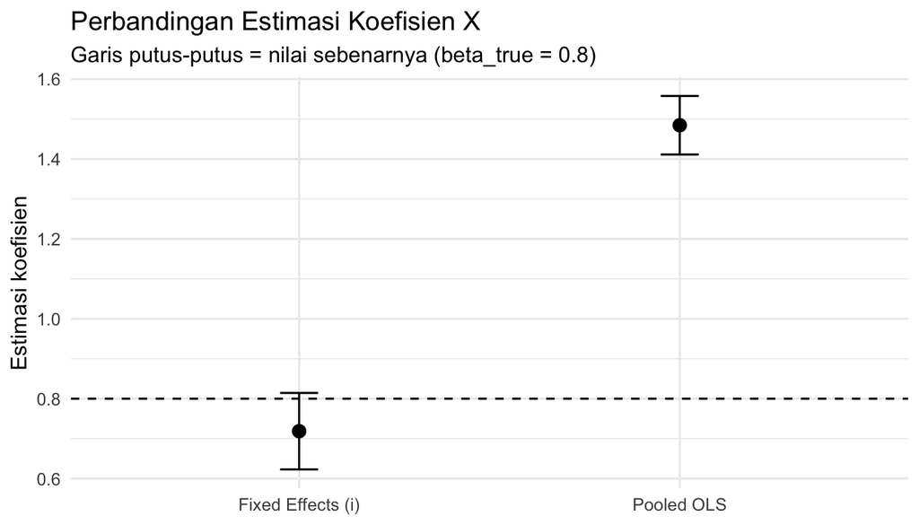

```r
ggplot(tbl, aes(x = model, y = estimate)) +
  geom_point(size = 3) +
  geom_errorbar(aes(ymin = estimate - 1.96*std.error,
                    ymax = estimate + 1.96*std.error),
                width = 0.1) +
  geom_hline(yintercept = beta_true, linetype = "dashed") +
  labs(title = "Perbandingan Estimasi Koefisien X",
       subtitle = "Garis putus-putus = nilai sebenarnya (beta_true = 0.8)",
       x = NULL, y = "Estimasi koefisien") +
  theme_minimal(base_size = 12)
```

> Dalam simulasi ini, **Pooled OLS** cenderung *menyimpang* dari \(\beta\) yang benar karena \(X\) berkorelasi dengan \(\alpha_i\). **FE** mengurangi bias tersebut dengan “menghapus” \(\alpha_i\) melalui transformasi *within*.

**Within vs LSDV: Bukti Ekuivalensi** Secara teori, estimasi \(\hat\beta\) dari *within estimator* dan *LSDV* identik. Perbedaan ada pada implementasi komputasional (efisiensi ketika \(N\) besar). Paket modern (mis. `fixest`, `lfe`, `plm`) mengestimasi FE tanpa benar-benar membuat ribuan dummy, melainkan menggunakan algoritme matriks yang menerapkan transformasi *within* secara efisien.

**Keterbatasan Praktis dan Saran**

- **Variasi dalam waktu diperlukan**: jika \(X\) tidak berubah dalam waktu untuk tiap \(i\), FE tidak dapat mengidentifikasi koefisiennya.
- **Efek waktu bersama (time fixed effects)**: sering disarankan untuk mengontrol guncangan makro (mis. kebijakan nasional) yang memengaruhi semua \(i\) pada periode \(t\). Contoh sintaks: `Y ~ X | i + t`.
- **Standard error**: pertimbangkan klasterisasi SE pada tingkat individu (atau *two-way clustering*) ketika relevan.
- **Endogeneity residual**: bila simultanitas atau measurement error masih mungkin, pertimbangkan **IV-FE** (`feols(..., iv=...)`) atau **dynamic panel GMM**.

**Kalimat Kunci**

- “**FE keep \(\alpha_i\) conceptually, but wipe it out algebraically.**”
- “FE menyelesaikan **OVB time-invariant**, bukan **semua** bentuk endogeneity.”
- “Kombinasikan FE dengan IV/DiD/GMM untuk sumber endogeneity yang berubah sepanjang waktu atau simultanitas.”

**Lampiran: Contoh Sintaks Alternatif** Beberapa alternatif paket/sintaks yang umum: - `plm::plm(Y ~ X, data = dat, index = c("i","t"), model = "within")` - `lfe::felm(Y ~ X | i)` - `fixest::feols(Y ~ X | i + t)` (tambahkan efek waktu bersama)

> Catatan: untuk IV-FE di `fixest`, gunakan formula instrumen, contoh:  
> `feols(Y ~ 1 | i, iv = ~ X ~ Z, data = dat)` di mana `Z` adalah instrumen yang valid.

## 5.8 Konsep Fixed Effect Model

### 5.8.1 FE Satu Arah

Model **Fixed Effect (FE)** digunakan dalam data panel untuk mengontrol *heterogenitas tak-teramati* (unobserved heterogeneity) yang bersifat **konstan dalam waktu** tetapi berbeda antarunit (misalnya antar individu, perusahaan, atau daerah).

Model umum one-way fixed effect (unit-specific) adalah:

$$(Y_{it} - \bar{Y}_{i}) = \beta (X_{it} - \bar{X}_{i}) +
(\varepsilon_{it} - \bar{\varepsilon}_{i})$$

dengan:

- $y_{it}$: variabel dependen untuk unit $i$ pada waktu $t$.
- $x1_{it}$: variabel independen yang **berubah antar unit dan antar waktu** (misalnya, tingkat investasi, output produksi, atau konsumsi energi).
- $x2_{it}$: variabel independen lain yang juga **bervariasi dalam waktu dan antarunit** (misalnya upah rata-rata, pendapatan per kapita, atau indeks biaya hidup).
- $z_t$: variabel yang **berubah hanya terhadap waktu** (misalnya inflasi nasional, kebijakan makro, atau efek waktu bersama).
- $\alpha_i$: efek individu tetap yang **konstan sepanjang waktu** untuk setiap unit, tetapi berbeda antarunit.
- $\varepsilon_{it}$: komponen error idiosinkratik yang bersifat acak.

Tujuan utama model FE adalah **menghilangkan korelasi antara** $\alpha_i$ dan variabel penjelas $x1_{it}, x2_{it}$, sehingga estimasi koefisien $\beta$ menjadi **tidak bias**.

### 5.8.2 Estimasi dengan Least Squares Dummy Variable (LSDV)

Pendekatan **LSDV (Least Squares Dummy Variable)** memasukkan efek tetap $\alpha_i$ secara eksplisit ke dalam model dengan menambahkan *dummy variable* untuk setiap unit individu.

Modelnya menjadi:

$$y_{it} = \beta_1 x1_{it} + \beta_2 x2_{it} + \beta_3 z_t +
\sum_{i=1}^{N-1} \alpha_i D_i + \varepsilon_{it}$$

dengan:

- $D_i$: dummy untuk unit ke-$i$ (1 jika observasi berasal dari unit $i$, 0 jika tidak).
- $N-1$: karena satu dummy harus dihapus agar tidak terjadi *dummy variable trap* (multikolinearitas sempurna).

Secara praktis, model ini diestimasi menggunakan **OLS**, namun dengan sejumlah besar dummy.

Estimator OLS dapat ditulis sebagai:

$$\hat{\beta}_{LSDV} = (X'D_M X)^{-1} X'D_M y$$

di mana $D_M$ adalah matriks yang memasukkan dummy untuk setiap unit individu.

**Kelebihan LSDV:** - Interpretasi mudah (efek tetap tampak eksplisit dalam hasil regresi). - Cocok untuk data panel dengan $N$ kecil dan $T$ besar.

**Kelemahan LSDV:** - Tidak efisien bila $N$ besar (karena menambah banyak dummy). - Tidak cocok untuk data panel besar (misalnya ribuan individu).

Contoh sintaks di R menggunakan `fixest`:

```r
library(fixest)
model_lsdv <- feols(y ~ x1 + x2 + z + factor(id), data = data_panel)
summary(model_lsdv)
```

### 5.8.3 Estimasi dengan Within (Demeaning / Differencing Mean) Transformation

Pendekatan **within transformation** atau **demeaning** menghilangkan efek individu $\alpha_i$ secara matematis tanpa menambahkan dummy.

Langkah-langkahnya:

**(a) Ambil rata-rata per individu**
$$\bar{y_i} = \frac{1}{T_i}\sum_{t=1}^{T_i} y_{it}, \quad
\bar{x1_i} = \frac{1}{T_i}\sum_{t=1}^{T_i} x1_{it}, \quad
\bar{x2_i} = \frac{1}{T_i}\sum_{t=1}^{T_i} x2_{it}, \quad
\bar{z_i} = \frac{1}{T_i}\sum_{t=1}^{T_i} z_t$$

**(b) Kurangkan setiap nilai aktual dengan rata-ratanya**
$$(y_{it} - \bar{y_i}) = \beta_1 (x1_{it} - \bar{x1_i}) + \beta_2 (x2_{it}
- \bar{x2_i}) + \beta_3 (z_t - \bar{z_i}) + (\varepsilon_{it} -
\bar{\varepsilon_i})$$

Karena $\alpha_i$ konstan untuk setiap $i$:
$$\alpha_i - \bar{\alpha_i} = 0$$

maka efek individu **terhapus** dari persamaan.  
Regresi dilakukan terhadap variabel yang sudah “dimean-kan” (*demeaned*).

Estimator FE (within estimator) diberikan oleh:

$$\hat{\beta}_{FE} = (X^{*\top} X^*)^{-1} X^{*\top} y^*$$

dengan:

- $X^* = X_{it} - \bar{X_i}$
- $y^* = y_{it} - \bar{y_i}$

**Interpretasi:**  
Koefisien $\hat{\beta}_{FE}$ menggambarkan efek rata-rata dari perubahan $x1_{it}$ atau $x2_{it}$ **dalam individu yang sama dari waktu ke waktu**, bukan antarindividu.

**Perbandingan LSDV dan Within Transformation**

| Aspek | LSDV | Within (Demeaning) |
| --- | --- | --- |
| Efek individu $\alpha_i$ | Dimodelkan eksplisit (dummy) | Dihilangkan secara matematis |
| Implementasi | Tambah dummy untuk setiap individu | Kurangkan rata-rata per individu |
| Efisiensi | Buruk jika N besar | Efisien untuk N besar |
| Interpretasi | Intersep spesifik terlihat | Intersep tidak terlihat langsung |
| Hasil $\hat{\beta}$ | Identik | Identik |
| Variabel time-invariant | Bisa diestimasi | Tidak bisa diestimasi |

**Contoh Implementasi di R**

*Contoh 1*

Berikut contoh data simulasi sederhana dengan dua variabel independen $x1, x2$, satu efek waktu $z_t$, dan efek individu $\alpha_i$.

```r
set.seed(123)
library(dplyr)
library(plm)

# Simulasi data panel
N <- 100   # jumlah unit
Tt <- 5    # jumlah waktu

alpha_i <- rnorm(N, 0, 2)    # efek tetap individu
beta <- c(0.5, -0.3, 0.2)

dat <- expand.grid(i = 1:N, t = 1:Tt) %>%
  mutate(x1 = runif(N*Tt, 10, 20),
         x2 = rnorm(N*Tt, 5, 1.5),
         z  = rnorm(Tt)[t],
         u  = rnorm(N*Tt, 0, 1),
         alpha = alpha_i[i],
         y = beta[1]*x1 + beta[2]*x2 + beta[3]*z + alpha + u)

# Konversi ke data panel
pdata <- pdata.frame(dat, index = c("i", "t"))

# Estimasi dengan LSDV
lsdv_model <- lm(y ~ x1 + x2 + z + factor(i), data = dat)

# Estimasi dengan within transformation (plm)
fe_model <- plm(y ~ x1 + x2 + z, data = pdata, model = "within")

summary(lsdv_model)$coefficients[1:5,]
```

```
##               Estimate Std. Error    t value      Pr(>|t|)
## (Intercept) -1.5854085 0.52978028 -2.9925775  2.939124e-03
## x1           0.4984952 0.01652002 30.1752188 8.389282e-105
## x2          -0.3024865 0.03204598 -9.4391402  3.245824e-19
## z            0.1939942 0.03737305  5.1907505  3.350568e-07
## factor(i)2   0.4646629 0.61199709  0.7592568  4.481496e-01
```

```r
summary(fe_model)
```

```
## Oneway (individual) effect Within Model
##
## Call:
## plm(formula = y ~ x1 + x2 + z, data = pdata, model = "within")
##
## Balanced Panel: n = 100, T = 5, N = 500
##
## Residuals:
##       Min.    1st Qu.     Median    3rd Qu.       Max.
## -2.6693563 -0.5574777  0.0071086  0.5214703  2.6382967
##
## Coefficients:
##     Estimate Std. Error t-value  Pr(>|t|)
## x1  0.498495   0.016520 30.1752 < 2.2e-16 ***
## x2 -0.302486   0.032046 -9.4391 < 2.2e-16 ***
## z   0.193994   0.037373  5.1908 3.351e-07 ***
## ---
## Signif. codes:  0 '***' 0.001 '**' 0.01 '*' 0.05 '.' 0.1 ' ' 1
##
## Total Sum of Squares:    1298.9
## Residual Sum of Squares: 369.63
## R-Squared:      0.71542
## Adj. R-Squared: 0.64231
## F-statistic: 332.686 on 3 and 397 DF, p-value: < 2.22e-16
```

Kedua metode menghasilkan estimasi $\hat{\beta}$ yang identik, meskipun pendekatannya berbeda.

**Interpretasi Hasil** Jika $\hat{\beta}_1 = 0.5$, artinya setiap **kenaikan satu unit pada** $x1_{it}$ dalam individu yang sama (misalnya peningkatan investasi perusahaan dari tahun ke tahun) dikaitkan dengan **kenaikan 0.5 unit pada** $y_{it}$, setelah mengendalikan efek tetap individu dan variabel lain.

**Kesimpulan**

1. **LSDV dan within estimator identik** secara matematis dalam hasil estimasi koefisien $\beta$.
2. **LSDV** cocok untuk $N$ kecil, sementara **within estimator** efisien untuk $N$ besar.
3. Keduanya mengatasi **endogeneity akibat omitted variable yang time-invariant**, namun **tidak** menyelesaikan simultaneity atau measurement error.
4. Dalam praktik empiris, penggunaan **plm()** atau **fixest::feols()** adalah cara paling efisien untuk mengestimasi model FE modern.

*Contoh 2*

```r
fe <- plm(y ~ x1 + x2 + z, data = pdata, model = "within", effect = "individual")
summary(fe)
```

```
## Oneway (individual) effect Within Model
##
## Call:
## plm(formula = y ~ x1 + x2 + z, data = pdata, effect = "individual",
##     model = "within")
##
## Balanced Panel: n = 100, T = 5, N = 500
##
## Residuals:
##       Min.    1st Qu.     Median    3rd Qu.       Max.
## -2.6693563 -0.5574777  0.0071086  0.5214703  2.6382967
##
## Coefficients:
##     Estimate Std. Error t-value  Pr(>|t|)
## x1  0.498495   0.016520 30.1752 < 2.2e-16 ***
## x2 -0.302486   0.032046 -9.4391 < 2.2e-16 ***
## z   0.193994   0.037373  5.1908 3.351e-07 ***
## ---
## Signif. codes:  0 '***' 0.001 '**' 0.01 '*' 0.05 '.' 0.1 ' ' 1
##
## Total Sum of Squares:    1298.9
## Residual Sum of Squares: 369.63
## R-Squared:      0.71542
## Adj. R-Squared: 0.64231
## F-statistic: 332.686 on 3 and 397 DF, p-value: < 2.22e-16
```

```r
coeftest(fe, vcov = vcovHC(fe, type = "HC1", cluster = "group"))
```

```
##
## t test of coefficients:
##
##     Estimate Std. Error  t value  Pr(>|t|)
## x1  0.498495   0.015928  31.2968 < 2.2e-16 ***
## x2 -0.302486   0.028804 -10.5016 < 2.2e-16 ***
## z   0.193994   0.035221   5.5079 6.539e-08 ***
## ---
## Signif. codes:  0 '***' 0.001 '**' 0.01 '*' 0.05 '.' 0.1 ' ' 1
```

### 5.8.4 FE Dua Arah (Unit + Waktu)

Dokumen ini merangkum spesifikasi **Fixed Effects (FE) dua arah**—unit dan waktu—beserta langkah estimasi dan implementasi R yang ringkas. Notasi galat menggunakan $\varepsilon$ (bukan $u$).

Intuisi: selain heterogenitas tak-teramati antar-unit ($\alpha_i$), sering ada *shock* agregat setiap periode ($\lambda_t$). FE dua arah menyerap keduanya sehingga identifikasi koefisien slope $\beta$ lebih bersih.

#### 5.8.4.1 Spesifikasi Model

Model panel **FE dua arah (unit + waktu)**:
$$Y_{it} \;=\; \alpha_i \;+\; \lambda_t \;+\; X_{it}^{\top}\beta \;+\;
\varepsilon_{it},
\qquad i=1,\dots,N,\; t=1,\dots,T.$$

Komponen:

- $Y_{it}$ : variabel dependen,
- $X_{it}$ : vektor kovariat (ukuran $K\times 1$),
- $\beta$ : parameter slope (ukuran $K\times 1$),
- $\alpha_i$ : efek tetap unit (konstan sepanjang waktu),
- $\lambda_t$ : efek tetap waktu (sama untuk semua unit pada periode $t$),
- $\varepsilon_{it}$ : galat idiosinkratik.

**Normalisasi identifikasi** (pilih salah satu) :
$$\sum_{i=1}^N \alpha_i = 0, \quad \sum_{t=1}^T \lambda_t = 0
\quad \text{atau} \quad
\alpha_1 = 0, \; \lambda_1 = 0 .$$

#### 5.8.4.2 Estimasi

Tiga pendekatan umum yang saling ekivalen untuk memperoleh $\hat{\beta}$.

##### 5.8.4.2.1 Within (Double-Demeaning)

Definisikan rata-rata menurut unit, waktu, dan keseluruhan:
$$\bar{Y}_{i\cdot}=\frac{1}{T}\sum_t Y_{it},\quad
\bar{Y}_{\cdot t}=\frac{1}{N}\sum_i Y_{it},\quad
\bar{Y}=\frac{1}{NT}\sum_{i,t} Y_{it}.$$

Transformasi *double-demeaning*:
$$\tilde{Y}_{it} = Y_{it} - \bar{Y}_{i\cdot} - \bar{Y}_{\cdot t} +
\bar{Y}, \qquad
\tilde{X}_{it} = X_{it} - \bar{X}_{i\cdot} - \bar{X}_{\cdot t} +
\bar{X}.$$

Setelah transformasi, efek tetap lenyap:
$$\tilde{Y}_{it} = \tilde{X}_{it}^{\top} \beta + \tilde{\varepsilon}_{it}.$$

Estimator OLS pada data bertanda “tilde”:
$$\hat{\beta}_{\text{FE,2W}} = (\tilde{X}^{\top}\tilde{X})^{-1}
\tilde{X}^{\top}\tilde{y}.$$

**Catatan proyeksi (opsional) :** menggunakan operator pusat $M_1$ (unit) dan $M_2$ (waktu), *double-demeaning* setara dengan proyeksi Kronecker $M_2 \otimes M_1$.

##### 5.8.4.2.2 LSDV (Least Squares Dummy Variables)

Regresi OLS dengan dummy untuk semua unit dan semua waktu (kecuali satu per kelompok untuk menghindari *dummy trap*) :
$$Y_{it} = \gamma + \sum_{i=2}^{N} \delta_i \, \mathbb{1}\{i\}
+ \sum_{t=2}^{T} \tau_t \, \mathbb{1}\{t\} + X_{it}^{\top}\beta +
\varepsilon_{it}.$$

Koefisien $\beta$ identik dengan *within*; $\delta_i$ dan $\tau_t$ merepresentasikan $\alpha_i$ dan $\lambda_t$ relatif kategori acuan.

##### 5.8.4.2.3 Frisch–Waugh–Lovell (FWL)

Regress-out $\alpha_i$ dan $\lambda_t$ dari $Y$ dan setiap kolom $X$, lalu OLS pada residualnya. Hasil $\hat{\beta}$ sama dengan (A) dan (B).

#### 5.8.4.3 Varian Galat & Standar Error

Panel jarang bersifat i.i.d. Gunakan SE yang tepat: - **Cluster by unit**: robust terhadap heteroskedastisitas dan autokorelasi dalam unit. - **Driscoll–Kraay**: robust terhadap dependensi lintas-seksi (cocok saat $T$ sedang-besar). - **Two-way cluster**: unit dan waktu sekaligus bila tersedia.

Residual terestimasi:
$$\hat{\varepsilon}_{it} = Y_{it} - \hat{\alpha}_i - \hat{\lambda}_t -
X_{it}^{\top}\hat{\beta}.$$

#### 5.8.4.4 Uji dan Diagnosis

- **Signifikansi efek tetap waktu**: uji F untuk blok dummy waktu (LSDV) atau pembandingan FE satu arah vs dua arah.
- **FE vs RE**: Hausman test (menguji konsistensi asumsi RE).
- **Signifikansi bersama kovariat**: uji F pada $\beta$.
- **Multikolinieritas**: hati-hati pada kovariat yang hampir konstan pada dimensi unit/waktu.

#### 5.8.4.5 Implementasi di R

Berikut dua jalur populer: `fixest` (efisien, fleksibel) dan `plm` (klasik untuk panel).

Dengan `fixest`

```r
# install.packages("fixest") # jika belum terpasang
library(fixest)

# Contoh data: gunakan data 'Grunfeld' dari paket 'plm'
# install.packages("plm")
library(plm)
data("Grunfeld", package = "plm")

# Model FE dua arah: efek tetap perusahaan (firm) dan tahun (year)
# Cluster-robust SE by firm (bisa juga 'twoway' dengan fixest >= 0.11)
m_fe2_fixest <- feols(inv ~ value + capital | firm + year, data = Grunfeld, cluster = "firm")
summary(m_fe2_fixest)
```

```
## OLS estimation, Dep. Var.: inv
## Observations: 200
## Fixed-effects: firm: 10,  year: 20
## Standard-errors: Clustered (firm)
##         Estimate Std. Error  t value   Pr(>|t|)
## value   0.117716   0.010824 10.87502 1.7727e-06 ***
## capital 0.357916   0.047848  7.48021 3.7703e-05 ***
## ---
## Signif. codes:  0 '***' 0.001 '**' 0.01 '*' 0.05 '.' 0.1 ' ' 1
## RMSE: 47.5     Adj. R2: 0.943118
##              Within R2: 0.720145
```

Beberapa opsi SE lain (jika tersedia versinya) :

```r
# Driscoll-Kraay (melalui vcovDC dari fixest)
summary(m_fe2_fixest, vcov = "DK")
# Two-way cluster (unit & waktu) jika diperlukan/tersedia
summary(m_fe2_fixest, cluster = c("firm","year"))
```

Dengan `plm`

```r
# install.packages("plm") # jika belum
library(plm)

# Spesifikasi FE dua arah (within transform)
m_fe2_plm <- plm(inv ~ value + capital, data = Grunfeld,
                 index = c("firm","year"),
                 model = "within", effect = "twoways")
summary(m_fe2_plm)
```

```
## Twoways effects Within Model
##
## Call:
## plm(formula = inv ~ value + capital, data = Grunfeld, effect = "twoways",
##     model = "within", index = c("firm", "year"))
##
## Balanced Panel: n = 10, T = 20, N = 200
##
## Residuals:
##      Min.   1st Qu.    Median   3rd Qu.      Max.
## -162.6094  -19.4710   -1.2669   19.1277  211.8420
##
## Coefficients:
##         Estimate Std. Error t-value  Pr(>|t|)
## value   0.117716   0.013751  8.5604 6.653e-15 ***
## capital 0.357916   0.022719 15.7540 < 2.2e-16 ***
## ---
## Signif. codes:  0 '***' 0.001 '**' 0.01 '*' 0.05 '.' 0.1 ' ' 1
##
## Total Sum of Squares:    1615600
## Residual Sum of Squares: 452150
## R-Squared:      0.72015
## Adj. R-Squared: 0.67047
## F-statistic: 217.442 on 2 and 169 DF, p-value: < 2.22e-16
```

**Standar error robust** dengan `plm`:

```r
# install.packages("sandwich"); install.packages("lmtest")
library(sandwich); library(lmtest)

# Cluster by firm
coeftest(m_fe2_plm, vcov = vcovHC(m_fe2_plm, method = "arellano", type = "HC1", cluster = "group"))
```

```
##
## t test of coefficients:
##
##         Estimate Std. Error t value  Pr(>|t|)
## value   0.117716   0.009761 12.0599 < 2.2e-16 ***
## capital 0.357916   0.043147  8.2952 3.277e-14 ***
## ---
## Signif. codes:  0 '***' 0.001 '**' 0.01 '*' 0.05 '.' 0.1 ' ' 1
```

```r
# Driscoll-Kraay
coeftest(m_fe2_plm, vcov = vcovSCC(m_fe2_plm, type = "HC1", maxlag = 2))  # maxlag pilih sesuai kebutuhan
```

```
##
## t test of coefficients:
##
##         Estimate Std. Error t value  Pr(>|t|)
## value   0.117716   0.020539  5.7313 4.481e-08 ***
## capital 0.357916   0.056092  6.3809 1.629e-09 ***
## ---
## Signif. codes:  0 '***' 0.001 '**' 0.01 '*' 0.05 '.' 0.1 ' ' 1
```

##### 5.8.4.5.1 Ringkasan Praktis

1. Spesifikasi model:
   $$Y_{it} = \alpha_i + \lambda_t + X_{it}^{\top}\beta + \varepsilon_{it}.$$
2. Transformasi *double-demeaning*:
   $$\tilde{Y}_{it} = Y_{it}-\bar{Y}_{i\cdot}-\bar{Y}_{\cdot t}+\bar{Y},\quad
   \tilde{X}_{it} = X_{it}-\bar{X}_{i\cdot}-\bar{X}_{\cdot t}+\bar{X}.$$
3. Estimator within dua arah:
   $$\hat{\beta}_{\text{FE,2W}} =
   (\tilde{X}^{\top}\tilde{X})^{-1}\tilde{X}^{\top}\tilde{y}.$$
4. Pulihkan $\hat{\alpha}_i$ dan $\hat{\lambda}_t$ sesuai normalisasi, lalu evaluasi residual $\hat{\varepsilon}_{it}$.
5. Laporkan SE yang sesuai (clustered/Driscoll–Kraay/two-way cluster) dan uji relevan.

### 5.8.5 Lampiran: FWL Ringkas (Opsional)

FWL menyatakan: jika Anda meregresikan $Y$ dan setiap kolom $X$ pada semua *dummy* unit dan waktu, lalu mengambil residualnya ($\tilde{y}, \tilde{X}$), maka OLS pada $\tilde{y} \sim \tilde{X}$ menghasilkan $\hat{\beta}$ yang sama dengan LSDV dan within.

Secara aljabar, dengan matriks proyeksi $M$ yang menyingkirkan ruang yang direntang *dummy* unit dan waktu:
$$\hat{\beta} = (X^{\top} M X)^{-1} X^{\top} M y.$$

```r
fe_tw <- plm(y ~ x1 + x2 + z, data = pdata, model = "within", effect = "twoways")
summary(fe_tw)
```

```
## Twoways effects Within Model
##
## Call:
## plm(formula = y ~ x1 + x2 + z, data = pdata, effect = "twoways",
##     model = "within")
##
## Balanced Panel: n = 100, T = 5, N = 500
##
## Residuals:
##       Min.    1st Qu.     Median    3rd Qu.       Max.
## -2.6024620 -0.5481059 -0.0048051  0.5006134  2.7048882
##
## Coefficients:
##     Estimate Std. Error t-value  Pr(>|t|)
## x1  0.499424   0.016551 30.1748 < 2.2e-16 ***
## x2 -0.300839   0.032236 -9.3325 < 2.2e-16 ***
## ---
## Signif. codes:  0 '***' 0.001 '**' 0.01 '*' 0.05 '.' 0.1 ' ' 1
##
## Total Sum of Squares:    1274
## Residual Sum of Squares: 367.55
## R-Squared:      0.71149
## Adj. R-Squared: 0.63461
## F-statistic: 485.828 on 2 and 394 DF, p-value: < 2.22e-16
```

```r
coeftest(fe_tw, vcov = vcovHC(fe_tw, type = "HC1", cluster = "group"))
```

```
##
## t test of coefficients:
##
##     Estimate Std. Error t value  Pr(>|t|)
## x1  0.499424   0.015766  31.677 < 2.2e-16 ***
## x2 -0.300839   0.029185 -10.308 < 2.2e-16 ***
## ---
## Signif. codes:  0 '***' 0.001 '**' 0.01 '*' 0.05 '.' 0.1 ' ' 1
```

> Alternatif manual: `lm(y ~ x1 + x2 + z + factor(id) + factor(year), data = panel)`, tapi FE via `plm` lebih efisien.

##### 5.8.5.0.1 Uji Signifikansi FE vs Pooled

- **F-test FE**: Apakah efek tetap unit signifikan?
- **LM (Breusch–Pagan)** nanti untuk RE vs pooled.

```r
# One-way FE vs pooled
pFtest(fe, pooled)
```

[output not shown]

```r
# Two-ways FE vs pooled (tak langsung, bisa bandingkan dengan model factor manual)
lm_pooled <- lm(y ~ x1 + x2 + z, data = panel)
lm_twoway <- lm(y ~ x1 + x2 + z + factor(id) + factor(year), data = panel)
anova(lm_pooled, lm_twoway)  # indikasi kasar
```

```
## Analysis of Variance Table
##
## Model 1: y ~ x1 + x2 + z
## Model 2: y ~ x1 + x2 + z + factor(id) + factor(year)
##   Res.Df    RSS Df Sum of Sq      F    Pr(>F)
## 1    356 666.95
## 2    293 211.05 63     455.9 10.046 < 2.2e-16 ***
## ---
## Signif. codes:  0 '***' 0.001 '**' 0.01 '*' 0.05 '.' 0.1 ' ' 1
```

## 5.9 **Random Effects (RE)**

RE memandang heterogenitas unit sebagai komponen **acak**: $\alpha_i \sim \mathcal{N}(0,\sigma_{\alpha}^2)$ dan **tidak berkorelasi** dengan kovariat $x_{it}$.

Model:
$$y_{it} = \beta_0 + \beta_1 x1_{it} + \beta_2 x2_{it} + \beta_3 z_t +
\alpha_i + u_{it}$$
dengan asumsi $\text{Cov}(\alpha_i, x_{it}) = 0$.

```r
re <- plm(y ~ x1 + x2 + z, data = pdata, model = "random", random.method = "swar")
summary(re)
```

```
## Oneway (individual) effect Random Effect Model
##    (Swamy-Arora's transformation)
##
## Call:
## plm(formula = y ~ x1 + x2 + z, data = pdata, model = "random",
##     random.method = "swar")
##
## Balanced Panel: n = 100, T = 5, N = 500
##
## Effects:
##                  var std.dev share
## idiosyncratic 0.9311  0.9649 0.214
## individual    3.4204  1.8494 0.786
## theta: 0.7728
##
## Residuals:
##      Min.   1st Qu.    Median   3rd Qu.      Max.
## -2.593311 -0.615791 -0.027389  0.660892  3.189176
##
## Coefficients:
##              Estimate Std. Error z-value  Pr(>|z|)
## (Intercept)  0.253760   0.343940  0.7378    0.4606
## x1           0.497239   0.016392 30.3343 < 2.2e-16 ***
## x2          -0.303237   0.031803 -9.5350 < 2.2e-16 ***
## z            0.193897   0.037318  5.1958 2.038e-07 ***
## ---
## Signif. codes:  0 '***' 0.001 '**' 0.01 '*' 0.05 '.' 0.1 ' ' 1
##
## Total Sum of Squares:    1397.6
## Residual Sum of Squares: 460.45
## R-Squared:      0.67055
## Adj. R-Squared: 0.66855
## Chisq: 1009.52 on 3 DF, p-value: < 2.22e-16
```

```r
coeftest(re, vcov = vcovHC(re, type = "HC1", cluster = "group"))
```

```
##
## t test of coefficients:
##
##              Estimate Std. Error  t value  Pr(>|t|)
## (Intercept)  0.253760   0.310321   0.8177    0.4139
## x1           0.497239   0.015743  31.5856 < 2.2e-16 ***
## x2          -0.303237   0.029119 -10.4137 < 2.2e-16 ***
## z            0.193897   0.035276   5.4966 6.203e-08 ***
## ---
## Signif. codes:  0 '***' 0.001 '**' 0.01 '*' 0.05 '.' 0.1 ' ' 1
```

### 5.9.1 RE vs Pooled: LM Breusch–Pagan

Uji apakah varians komponen acak $\sigma_\alpha^2$ non-zero (artinya RE beralasan).

```r
plmtest(pooled, type = "bp")
```

```
##
##  Lagrange Multiplier Test - (Breusch-Pagan)
##
## data:  y ~ x1 + x2 + z
## chisq = 249.51, df = 1, p-value < 2.2e-16
## alternative hypothesis: significant effects
```

### 5.9.2 **Hausman Test**: FE vs RE

Kunci keputusan: bila $\alpha_i$ berkorelasi dengan $x_{it}$, **FE konsisten** tetapi **RE tidak**. Gunakan uji Hausman.

```r
phtest(fe, re)
```

```
##
##  Hausman Test
##
## data:  y ~ x1 + x2 + z
## chisq = 0.43892, df = 3, p-value = 0.9321
## alternative hypothesis: one model is inconsistent
```

- **Signifikan** → tolak H0 (tidak ada korelasi); pilih **FE**.
- **Tidak signifikan** → RE boleh dipakai (lebih efisien jika asumsi terpenuhi).

## 5.10 Interpretasi Koefisien

- Pada **FE**, koefisien $\beta$ diinterpretasi sebagai **hubungan dalam-unit** (how changes within the same unit relate to $y$).
- Pada **RE** dan **Pooled**, interpretasi mencampur variasi *antara* unit dan *dalam* unit — berpotensi bias jika ada korelasi $x$ dengan $\alpha_i$.

## 5.11 Interaksi dan Heterogenitas Slope

Model FE standar mengasumsikan slope sama untuk semua unit. Jika Anda ingin slope berbeda (mis. `x1` berefek lebih kuat di sektor A), gunakan interaksi `x1 * sector` dan tetap sertakan efek tetap unit/waktu bila relevan.

```r
# Misal kita definisikan 3 sektor berdasarkan id
panel <- panel %>% mutate(sector = factor(ifelse(id <= 20, "A", ifelse(id <= 40, "B", "C"))))
pdata <- pdata.frame(panel, index = c("id","year"))

fe_int <- plm(y ~ x1*sector + x2 + z, data = pdata, model = "within", effect = "twoways")
summary(fe_int)
```

```
## Twoways effects Within Model
##
## Call:
## plm(formula = y ~ x1 * sector + x2 + z, data = pdata, effect = "twoways",
##     model = "within")
##
## Balanced Panel: n = 60, T = 6, N = 360
##
## Residuals:
##      Min.   1st Qu.    Median   3rd Qu.      Max.
## -2.244464 -0.527023 -0.027684  0.461679  2.103522
##
## Coefficients:
##             Estimate Std. Error t-value  Pr(>|t|)
## x1          0.619239   0.050011 12.3821 < 2.2e-16 ***
## x2         -0.368322   0.049216 -7.4837 8.622e-13 ***
## x1:sectorB -0.032285   0.072973 -0.4424    0.6585
## x1:sectorC -0.034998   0.074177 -0.4718    0.6374
## ---
## Signif. codes:  0 '***' 0.001 '**' 0.01 '*' 0.05 '.' 0.1 ' ' 1
##
## Total Sum of Squares:    553.52
## Residual Sum of Squares: 210.84
## R-Squared:      0.61909
## Adj. R-Squared: 0.53008
## F-statistic: 118.239 on 4 and 291 DF, p-value: < 2.22e-16
```

```r
coeftest(fe_int, vcov = vcovHC(fe_int, type = "HC1", cluster = "group"))
```

```
##
## t test of coefficients:
##
##             Estimate Std. Error t value  Pr(>|t|)
## x1          0.619239   0.049172 12.5934 < 2.2e-16 ***
## x2         -0.368322   0.044998 -8.1852 8.592e-15 ***
## x1:sectorB -0.032285   0.065465 -0.4932    0.6223
## x1:sectorC -0.034998   0.063755 -0.5489    0.5835
## ---
## Signif. codes:  0 '***' 0.001 '**' 0.01 '*' 0.05 '.' 0.1 ' ' 1
```

> Hati-hati **ledakan parameter** kalau level faktor banyak. Gunakan interaksi jika ada hipotesis teoritis yang jelas.

## 5.12 Visualisasi Efek Tetap: *Within vs Between*

Pisahkan variasi *within* (dalam unit) dan *between* (antar unit) untuk `x1`.

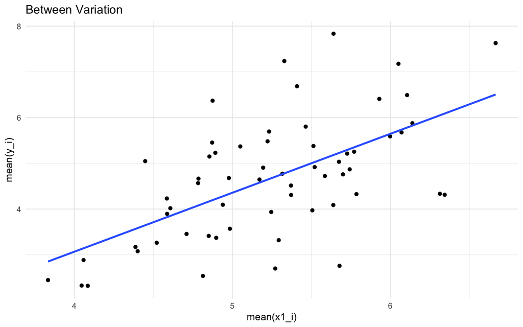

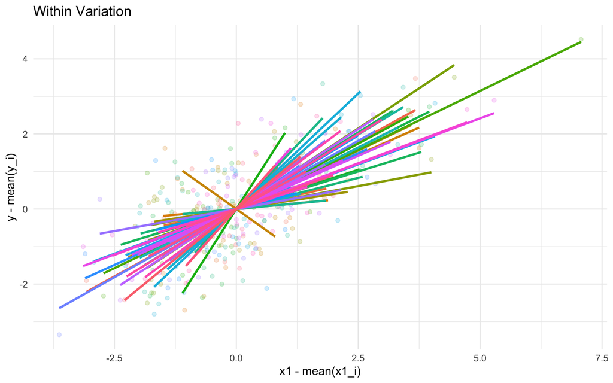

```r
wb <- panel %>%
  group_by(id) %>%
  mutate(x1_between = mean(x1), x1_within = x1 - x1_between) %>%
  ungroup()

# Hubungan antar-unit (between): rata-rata y vs rata-rata x1 per unit
between_df <- wb %>% group_by(id) %>% summarize(y_m = mean(y), x1_m = mean(x1))

p1 <- ggplot(between_df, aes(x1_m, y_m)) +
  geom_point() + geom_smooth(method = "lm", se = FALSE) +
  labs(title = "Between Variation", x = "mean(x1_i)", y = "mean(y_i)") +
  theme_minimal()

# Hubungan dalam-unit (within): deviasi dari mean unit
p2 <- ggplot(wb, aes(x1_within, y - ave(y, id, FUN=mean), color = factor(id))) +
  geom_point(alpha = 0.2) +
  geom_smooth(method = "lm", se = FALSE) +
  guides(color = "none") +
  labs(title = "Within Variation",
       x = "x1 - mean(x1_i)", y = "y - mean(y_i)") +
  theme_minimal()

p1; p2
```

## 5.13 Diagnostik Lanjutan

Panel sering menghadapi heteroskedastisitas, autokorelasi, dan ketergantungan silang.

### 5.13.1 Heteroskedastisitas & Autokorelasi

Gunakan **SE robust berklaster** pada `id` (sudah dicontohkan). Bisa juga *Driscoll–Kraay* (ketahanan terhadap dependensi silang) pada T moderat-besar.

```r
# SE Driscoll-Kraay (butuh T cukup besar biasanya)
coeftest(fe_tw, vcov = vcovSCC(fe_tw, type = "HC1", maxlag = 2))
```

```
##
## t test of coefficients:
##
##      Estimate Std. Error t value  Pr(>|t|)
## x1  0.4994243  0.0128222  38.950 < 2.2e-16 ***
## x2 -0.3008392  0.0087336 -34.446 < 2.2e-16 ***
## ---
## Signif. codes:  0 '***' 0.001 '**' 0.01 '*' 0.05 '.' 0.1 ' ' 1
```

### 5.13.2 Uji Serial Correlation (Breusch–Godfrey) dalam Panel

```r
pbgtest(fe)   # uji BG untuk model FE one-way
```

```
##
##  Breusch-Godfrey/Wooldridge test for serial correlation in panel models
##
## data:  y ~ x1 + x2 + z
## chisq = 91.826, df = 5, p-value < 2.2e-16
## alternative hypothesis: serial correlation in idiosyncratic errors
```

### 5.13.3 Uji Cross-Sectional Dependence

```r
pcdtest(fe_tw, test = "cd")  # Pesaran CD test
```

```
##
##  Pesaran CD test for cross-sectional dependence in panels
##
## data:  y ~ x1 + x2 + z
## z = -1.1274, p-value = 0.2596
## alternative hypothesis: cross-sectional dependence
```

Jika ada ketergantungan silang kuat (mis. shock nasional), pertimbangkan model dua-arah FE (sudah), faktor tak-teramati bersama (CMG), atau standar error Driscoll–Kraay.

## 5.14 Ringkasan Keputusan Model

1. **Mulai dengan Pooled** sebagai baseline (dengan SE robust).
2. **Uji LM (BP)**: jika signifikan → panel structure penting (pertimbangkan RE/FE).
3. **Estimasi RE dan FE**.
4. **Hausman**: signifikan → pilih **FE**; jika tidak → **RE** boleh.
5. Tambahkan **time FE** bila ada tren/shock agregat.
6. Gunakan **SE klaster** atau **Driscoll–Kraay** untuk robust inference.
7. Plot dan eksplorasi variasi *within* vs *between* agar interpretasi tepat sasaran.

## 5.15 Praktik

- **Skalakan/transform** variabel yang sangat *skewed* (contoh `x1` log-normal) atau gunakan log jika interpretasi elastisitas relevan.
- **Centering** membantu interpretasi intersep pada FE dengan interaksi kontinu–kategori.
- **Hati-hati endogenitas**: FE tidak menyelesaikan endogenitas *time-varying* (mis. *reverse causality*). Pertimbangkan IV panel atau desain kausal (DiD, event study).
- **Panel tidak seimbang** (unbalanced) **boleh** dipakai `plm`; dokumentasikan alasan kehilangan observasi.
- **Dokumentasikan indeks** dengan jelas (`id`, `year`) dan pastikan *merge/join* variabel waktu-spesifik benar (hindari *look-ahead bias*).

## 5.16 Lampiran: Model Manual dengan Dummy Ekspisit

Untuk memperjelas ekivalensi FE ⇔ dummy penuh:

```r
lm_manual <- lm(y ~ x1 + x2 + z + factor(id), data = panel) # one-way FE manual
summary(lm_manual)$coef[1:8,] %>% kable(digits=3) %>% kable_styling(full_width = FALSE)
```

|  | Estimate | Std. Error | t value | Pr(>&#124;t&#124;) |
| --- | --- | --- | --- | --- |
| (Intercept) | 1.069 | 0.308 | 3.468 | 0.001 |
| x1 | 0.596 | 0.032 | 18.355 | 0.000 |
| x2 | -0.391 | 0.053 | -7.418 | 0.000 |
| z | -1.141 | 0.758 | -1.506 | 0.133 |
| factor(id)2 | 1.204 | 0.534 | 2.254 | 0.025 |
| factor(id)3 | 3.457 | 0.534 | 6.473 | 0.000 |
| factor(id)4 | 1.678 | 0.534 | 3.140 | 0.002 |
| factor(id)5 | 1.024 | 0.536 | 1.908 | 0.057 |

> Koefisien `factor(id)` adalah perbedaan intersep unit relatif baseline. *Within estimator* akan memberikan $\hat{\beta}$ yang sama untuk kovariat.

## 5.17 Ekstensi Singkat

- **Two-way FE**: tambah `factor(year)` atau `effect="twoways"` (sudah dicontohkan).
- **Random slopes**: izinkan slope berbeda per unit (model hierarkis/lme4) — beda filosofi dari FE/RE klasik.
- **Dynamic panels**: tambahkan lag `y_{it-1}` → butuh Arellano–Bond/GMM (`plm::pgmm`).

```r
library(plm)
# pastikan pdata sudah: pdata <- pdata.frame(panel, index = c("id","year"))

# 1) Hanya y_lag sebagai regressor dinamis; instrumen GMM = lag(y, 2) saja
dyn_min <- pgmm(
  formula = y ~ lag(y, 1) | lag(y, 2),
  data = pdata,
  effect = "individual",
  model = "onestep",        # 1-step lebih stabil saat matriks hampir singular
  transformation = "d",     # first-difference Arellano-Bond
  collapse = TRUE           # kurangi proliferasi instrumen
)

summary(dyn_min, robust = TRUE)   # ringkasan + vcov robust
```

```
## Oneway (individual) effect One-step model Difference GMM
##
## Call:
## pgmm(formula = y ~ lag(y, 1) | lag(y, 2), data = pdata, effect = "individual",
##     model = "onestep", collapse = TRUE, transformation = "d")
##
## Balanced Panel: n = 60, T = 6, N = 360
##
## Number of Observations Used: 240
## Residuals:
##    Min. 1st Qu.  Median    Mean 3rd Qu.    Max.
## -5.3838 -0.7915  0.4694  0.4386  1.8238  5.7426
##
## Coefficients:
##           Estimate Std. Error z-value Pr(>|z|)
## lag(y, 1) -0.99908    0.53013 -1.8846  0.05949 .
## ---
## Signif. codes:  0 '***' 0.001 '**' 0.01 '*' 0.05 '.' 0.1 ' ' 1
##
## Sargan test: chisq(0) = 2.179288e-31 (p-value = < 2.22e-16)
## Autocorrelation test (1): normal = 0.1212099 (p-value = 0.90352)
## Autocorrelation test (2): normal = -2.030757 (p-value = 0.04228)
## Wald test for coefficients: chisq(1) = 3.551666 (p-value = 0.059486)
```

```r
mtest(dyn_min, order = 1)         # AR(1) harus signifikan
```

```
##
##  Arellano-Bond autocorrelation test of degree 1
##
## data:  y ~ lag(y, 1) | lag(y, 2)
## normal = 0.3248, p-value = 0.7453
## alternative hypothesis: autocorrelation present
```

```r
mtest(dyn_min, order = 2)         # AR(2) harus TIDAK signifikan
```

```
##
##  Arellano-Bond autocorrelation test of degree 2
##
## data:  y ~ lag(y, 1) | lag(y, 2)
## normal = NaN, p-value = NA
## alternative hypothesis: autocorrelation present
```

```r
sargan(dyn_min)                   # Hansen/Sargan idealnya tidak signifikan
```

```
##
##  Sargan test
##
## data:  y ~ lag(y, 1) | lag(y, 2)
## chisq = 2.1793e-31, df = 0, p-value < 2.2e-16
## alternative hypothesis: overidentifying restrictions not valid
```

## 5.18 Kesimpulan

- **Pooled OLS**: sederhana, tapi rawan bias jika ada heterogenitas unit yang berkorelasi dengan kovariat.
- **Fixed Effects**: mengontrol semua faktor tak-teramati konstan terhadap waktu pada level unit (dan/atau waktu). Andal saat ada korelasi $\alpha_i$–$x_{it}$.
- **Random Effects**: efisien jika *asumsi kunci* (tidak ada korelasi $\alpha_i$–$x_{it}$) benar; uji **Hausman** adalah kompasnya.
- Struktur **wide vs long** memengaruhi *workflow* teknis: analisis panel modern hampir selalu di **long**.
- Gunakan **robust/clustered SE**, periksa **serial correlation** dan **dependensi silang**, serta pikirkan desain kausal untuk klaim sebab–akibat.

Dokumen ini mestinya menjadi *toolbox* ajar/riset. Anda bisa langsung *knit* untuk kelas, menyalin tabel ke slide, dan menyesuaikan simulasi ke konteks lokal (misalnya kabupaten–kota dan tahun kebijakan). Jika analisis makin “spicy”, jangan ragu menambahkan *two-way FE* dan tes Driscoll–Kraay—bumbu pedas yang aman untuk inferensi.

# 6 KUIS

## 6.1 Petunjuk

Jawablah dua soal aplikasi berikut secara singkat dan jelas. Gunakan notasi matematis atau interpretasi ekonometrika bila diperlukan.

## 6.2 Soal 1 — Aplikasi OLS (50 poin)

Seorang peneliti ingin menganalisis pengaruh jam belajar terhadap nilai ujian mahasiswa. Ia mengumpulkan data dari 100 mahasiswa dan memperkirakan model berikut:

$$\text{Score}_i = \beta_0 + \beta_1 \text{StudyHours}_i + \varepsilon_i$$

Hasil estimasi menunjukkan bahwa $\hat{\beta}_1 = 2.5$ dan signifikan pada tingkat 5%.

1. Jelaskan interpretasi dari koefisien $\hat{\beta}_1 = 2.5$ dalam konteks penelitian ini. (25 poin)
2. Jika variabel kemampuan awal mahasiswa tidak dimasukkan ke dalam model, apa potensi masalah yang muncul? Jelaskan secara singkat. (25 poin)

## 6.3 Soal 2 — Aplikasi Fixed Effects (50 poin)

Seorang ekonom ingin meneliti pengaruh belanja pemerintah daerah terhadap tingkat kemiskinan di 10 provinsi selama 5 tahun. Model yang digunakan:

$$\text{Poverty}_{it} = \alpha_i + \beta_1 \text{GovExp}_{it} +
\varepsilon_{it}$$

Hasil model Fixed Effects menunjukkan bahwa $\hat{\beta}_1 = -0.8$ dan signifikan pada tingkat 1%.

1. Jelaskan makna dari nilai $\hat{\beta}_1 = -0.8$ dalam konteks penelitian ini. (25 poin)
2. Mengapa model Fixed Effects lebih sesuai dibanding *pooled OLS* dalam kasus ini? Berikan alasan singkat. (25 poin)

> Kuis dikumpulan pada link gform berikut (10 November 2025 Pukul 16:00 WIB): https://forms.gle/QEwdZz6smK9eW3Jb8

# 7 **Difference-in-Differences (DiD)**

Model *Difference-in-Differences (DiD)* adalah teknik ekonometrika untuk mengukur efek kausal dari suatu kebijakan, intervensi, atau peristiwa terhadap variabel hasil (*outcome*), dengan memanfaatkan **data sebelum vs sesudah** pada **kelompok perlakuan (treatment)** dan **kelompok kontrol (control)**.

Di dokumen ini, kita membedah DiD dari **intuisi → formulasi → asumsi → implementasi R** (termasuk *event study* sederhana), plus *diagnostics* dan uji placebo ringkas.

## 7.1 Intuisi Dasar

Bayangkan pemerintah memberi pelatihan keterampilan kepada sebagian provinsi (*treatment*), sementara provinsi lain tidak (*control*). Kita ingin tahu: apakah program ini **meningkatkan pendapatan rata-rata**?

Masalah: pendapatan bisa naik karena banyak hal (pertumbuhan ekonomi umum, inflasi, tren waktu). Jika kita hanya *sebelum–sesudah* pada treatment, efek bisa **terkontaminasi** tren umum.

**Trik DiD:** bandingkan **perubahan** di treatment dengan **perubahan** di kontrol:

$$\text{Efek kebijakan} = \big(\Delta Y_{\text{treat}}\big) - \big(\Delta
Y_{\text{control}}\big)$$

Kelompok kontrol bertindak sebagai *counterfactual*—dunia alternatif tanpa kebijakan.

## 7.2 Formulasi Matematis

Misalkan untuk unit $i$ dan waktu $t$:

- $Y_{it}$: *outcome* (mis. pendapatan)
- $D_i \in \{0,1\}$: indikator treatment (1 jika unit termasuk kelompok treatment)
- $Post_t \in \{0,1\}$: indikator periode sesudah kebijakan

## 7.3 Model DiD Klasik

Model *two-by-two* dapat dituliskan sebagai:

$$Y_{it} = \alpha + \beta D_i + \gamma Post_t + \delta (D_i \times Post_t)
+ \varepsilon_{it}.$$

Koefisien $\delta$ merepresentasikan **efek kausal kebijakan**, yaitu selisih perubahan rata-rata *outcome* antara kelompok treatment dan control:

$$\text{Efek kebijakan} = \big(\Delta Y_{\text{treat}}\big) - \big(\Delta
Y_{\text{control}}\big)$$

Interpretasi

- $\alpha$: rata-rata *outcome* pada kelompok kontrol sebelum kebijakan
- $\beta$: perbedaan tetap antara treatment dan control sebelum kebijakan
- $\gamma$: efek waktu umum (terjadi di semua kelompok)
- $\delta$: **parameter utama (DiD effect)** — estimasi dampak kebijakan hanya pada kelompok treatment setelah intervensi

## 7.4 Tabel Empat Sel

|  | Sebelum (0) | Sesudah (1) | Perubahan |
| --- | --- | --- | --- |
| **Kontrol (0)** | $\bar{Y}_{C,0}$ | $\bar{Y}_{C,1}$ | $\bar{Y}_{C,1} - \bar{Y}_{C,0}$ |
| **Treatment (1)** | $\bar{Y}_{T,0}$ | $\bar{Y}_{T,1}$ | $\bar{Y}_{T,1} - \bar{Y}_{T,0}$ |

Efek DiD:

$$\text{DiD} = (\bar{Y}_{T,1} - \bar{Y}_{T,0}) - (\bar{Y}_{C,1} -
\bar{Y}_{C,0})$$

## 7.5 Asumsi Kunci: *Parallel Trends*

Tanpa kebijakan, tren *outcome* di treatment dan kontrol **sejajar** (paralel):

$$E[Y_{T,1} - Y_{T,0} \mid \text{no treatment}] = E[Y_{C,1} - Y_{C,0}]$$

Bila tren dasar tidak paralel, $\hat{\delta}$ berpotensi **bias**.  
Karenanya, visualisasi dan uji *lead* (placebo) berguna sebagai *diagnostics*.

## 7.6 Versi dengan *Fixed Effects* (TWFE)

Untuk data panel (banyak unit × banyak waktu), lazim digunakan **Two-Way Fixed Effects (TWFE)**:

$$Y_{it} = \alpha_i + \lambda_t + \delta (D_i \times Post_t) +
\varepsilon_{it}$$

dengan:

- $\alpha_i$: *unit fixed effect* (mengontrol heterogenitas tetap antar unit),
- $\lambda_t$: *time fixed effect* (mengontrol guncangan waktu bersama),
- $\delta$: tetap menjadi efek perlakuan (*treatment effect*).

## 7.7 Implementasi di R: Contoh Simulasi 2×2

Kita mulai dari skenario *klasik* 2×2: satu gelombang kebijakan, dua periode (0=sebelum, 1=sesudah), dua grup (kontrol vs treatment).

```r
pkgs <- c("tidyverse", "fixest", "sandwich", "lmtest", "broom")
need <- pkgs[!pkgs %in% rownames(installed.packages())]
if (length(need)) install.packages(need, repos = "https://cloud.r-project.org")
invisible(lapply(pkgs, library, character.only = TRUE))
```

```r
set.seed(123)
N  <- 200    # total unit
Tt <- 2      # dua periode: 0=pre, 1=post
id <- rep(1:N, each = Tt)
t  <- rep(0:1, times = N)

# separuh jadi treatment:
D_i <- rep(rbinom(N, 1, 0.5), each = Tt)
Post_t <- t

# Komponen efek tetap & tren umum
alpha_i <- rnorm(N, 0, 1)      # unit heterogeneity (random intercept) - akan di-absorb oleh FE
alpha_i <- rep(alpha_i, each = Tt)
time_shock <- ifelse(t==1, 1.0, 0.0)  # ada kenaikan umum di periode post

# Efek perlakuan sebenarnya (ground truth)
delta_true <- 2.0

# Outcome dihasilkan dengan struktur DiD + noise
y <- 1.0 + 0.3*D_i + 0.8*Post_t + delta_true*(D_i*Post_t) + alpha_i + time_shock + rnorm(N*Tt, 0, 1)

did_2x2 <- tibble(id, t, D_i, Post_t, y) %>%
  mutate(group = ifelse(D_i==1, "Treatment", "Control"),
         period = ifelse(Post_t==1, "Post", "Pre"))
did_2x2 %>% head()
```

```
## # A tibble: 6 × 7
##      id     t   D_i Post_t      y group     period
##   <int> <int> <int>  <int>  <dbl> <chr>     <chr>
## 1     1     0     0      0 -0.426 Control   Pre
## 2     1     1     0      1  1.34  Control   Post
## 3     2     0     1      0  0.618 Treatment Pre
## 4     2     1     1      1  4.30  Treatment Post
## 5     3     0     0      0  0.316 Control   Pre
## 6     3     1     0      1  2.88  Control   Post
```

### 7.7.1 Visualisasi Tren Rata-rata

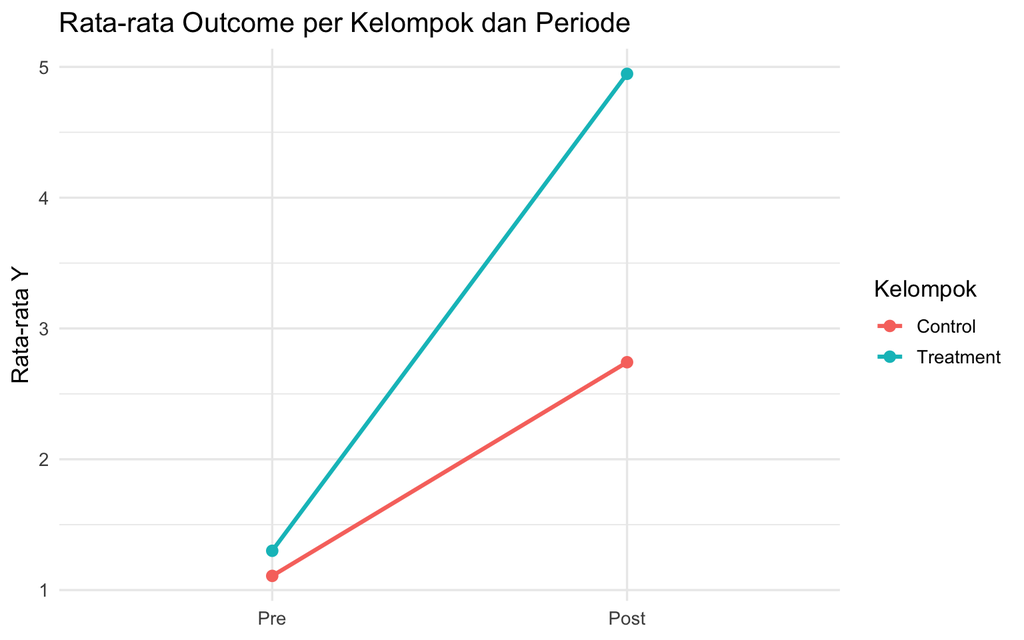

Rata-rata outcome per grup dan periode.

```r
library(dplyr)
library(ggplot2)

# pastikan urutan level faktor
did_2x2 <- did_2x2 %>%
  mutate(period = factor(period, levels = c("Pre", "Post")))

# hitung rata-rata per group dan period
avg <- did_2x2 %>%
  group_by(group, period) %>%
  summarise(mean_y = mean(y), .groups = "drop")

# visualisasi dengan ggplot
ggplot(avg, aes(x = period, y = mean_y, group = group, color = group)) +
  geom_line(size = 1.1) +
  geom_point(size = 2.5) +
  labs(
    title = "Rata-rata Outcome per Kelompok dan Periode",
    x = NULL,
    y = "Rata-rata Y",
    color = "Kelompok"
  ) +
  theme_minimal(base_size = 13)
```

> Intepretasi

*Sumbu dan Makna Garis*

- **Sumbu X (horizontal):** waktu — sebelum (*Pre*) dan sesudah (*Post*) kebijakan.
- **Sumbu Y (vertikal):** nilai rata-rata variabel hasil (*outcome*), misalnya pendapatan, skor ujian, atau tingkat kesehatan.
- **Dua garis:**
  - Garis **atas** biasanya mewakili **kelompok perlakuan (treatment)** — unit yang terkena kebijakan/intervensi.
  - Garis **bawah** mewakili **kelompok kontrol** — unit yang tidak terkena kebijakan.

*Apa yang Terlihat dari Grafik*

Kedua garis naik dari *Pre* ke *Post*, tetapi garis treatment naik lebih curam. Artinya:

- Baik treatment maupun control mengalami peningkatan outcome (ada **time effect**).
- Peningkatan pada kelompok treatment **lebih besar** — itulah **efek kausal kebijakan (ΔDiD)**.

Secara matematis:

\[ \text{DiD} = (\bar{Y}_{T,\,post} - \bar{Y}_{T,\,pre}) - (\bar{Y}_{C,\,post} - \bar{Y}_{C,\,pre}). \]

Garis kontrol berfungsi sebagai **counterfactual** — apa yang akan terjadi pada kelompok treatment **jika tidak ada kebijakan**.

*Cara Membaca Secara Intuitif*

- Jika dua garis **paralel sebelum intervensi**, asumsi **parallel trends** terpenuhi.
- Jika setelah intervensi garis treatment “meninggalkan” garis kontrol, jarak vertikal di titik *Post* menggambarkan **efek kebijakan murni** (setelah menghilangkan pengaruh waktu umum).

*Ilustrasi Konseptual*

Bayangkan:  
- Semua provinsi naik pendapatannya sekitar **+2** karena pertumbuhan ekonomi nasional.  
- Provinsi yang mendapat pelatihan (treatment) naik **+7**.  
Perbedaan tambahan **+5** itulah efek **DiD**: kenaikan **ekstra** karena kebijakan.

*Contoh Reproducible (R)*

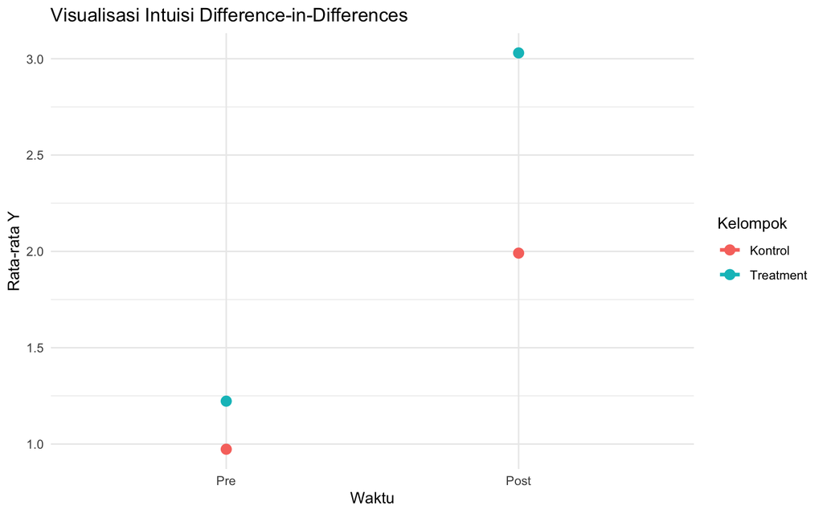

```r
set.seed(123)
library(dplyr)
library(ggplot2)

# N unit, 2 periode
n <- 200
dat <- expand.grid(id = 1:n, time = 0:1) %>% as_tibble()

# 50% unit sebagai treatment
dat <- dat %>%
  mutate(treat = as.integer(id <= n/2))

# DGP (gunakan nrow(dat) agar aman)
dat <- dat %>%
  mutate(
    Y = 1.0 + 0.2*treat + 1.0*time + 0.8*(treat*time) + rnorm(nrow(dat), sd = 0.25)
  )

# Plot
mean_trend <- dat %>%
  group_by(treat, time) %>%
  summarise(meanY = mean(Y), .groups = "drop")

ggplot(mean_trend, aes(x = factor(time, labels = c("Pre","Post")),
                       y = meanY, color = factor(treat))) +
  geom_line(size = 1.2) +
  geom_point(size = 3) +
  labs(x = "Waktu", y = "Rata-rata Y", color = "Kelompok",
       title = "Visualisasi Intuisi Difference-in-Differences") +
  scale_color_discrete(labels = c("Kontrol","Treatment")) +
  theme_minimal()
```

*Kesimpulan Visual*

Grafik menunjukkan bahwa kebijakan **meningkatkan outcome** kelompok treatment **lebih besar** daripada kontrol. Setelah mengeluarkan efek waktu umum, selisih tambahan itulah **efek DiD** (\(\Delta \text{DiD}\)).

### 7.7.2 Estimasi Model DiD Klasik (OLS)

```r
m_ols <- lm(y ~ D_i + Post_t + D_i:Post_t, data = did_2x2)
summary(m_ols)$coefficients
```

```
##              Estimate Std. Error   t value     Pr(>|t|)
## (Intercept) 1.1081474  0.1376832 8.0485281 9.875243e-15
## D_i         0.1920121  0.1977016 0.9712217 3.320307e-01
## Post_t      1.6339070  0.1947135 8.3913387 8.594261e-16
## D_i:Post_t  2.0130034  0.2795923 7.1997812 3.054983e-12
```

**Interpretasi**

Model: `y ~ D_i + Post_t + D_i:Post_t`

- `D_i = 1` untuk kelompok **treatment**.
- `Post_t = 1` untuk periode **sesudah** kebijakan.
- Koefisien kunci DiD = interaksi `D_i:Post_t` (= ATT di setup 2×2, dengan asumsi standar DiD).

**Makna tiap koefisien**

- **(Intercept) = 1.108** (SE 0.138, *p* < 0.001, 95% CI [0.838, 1.378])  
  Rata-rata **kelompok kontrol sebelum** intervensi.
- **D_i = 0.192** (SE 0.198, *p* = 0.332, 95% CI [−0.195, 0.580])  
  Perbedaan **treatment vs kontrol sebelum** intervensi. Tidak signifikan ⇒ baseline antarkelompok relatif mirip (good news untuk *parallel trends* secara deskriptif).
- **Post_t = 1.634** (SE 0.195, *p* < 0.001, 95% CI [1.252, 2.016])  
  Perubahan **kontrol: sesudah − sebelum**. Outcome kontrol naik sekitar **1.63** satuan.
- **D_i:Post_t = 2.013** (SE 0.280, *p* < 0.001, 95% CI [1.465, 2.561]) ⟵ **Efek DiD (ATT)**  
  Kenaikan **tambahan** pada treatment relatif terhadap kontrol setelah kebijakan ≈ **+2.01** satuan. Ini estimasi efek kausal DiD (dengan asumsi terpenuhi).

**Nilai rata-rata tiap sel (rekonstruksi dari koefisien)**

- **Kontrol, sebelum**: 1.108
- **Treatment, sebelum**: 1.108 + 0.192 = **1.300**
- **Kontrol, sesudah**: 1.108 + 1.634 = **2.742**
- **Treatment, sesudah**: 1.108 + 0.192 + 1.634 + 2.013 = **4.947**

**Perubahan:** - Kontrol: 2.742 − 1.108 = **+1.634**  
- Treatment: 4.947 − 1.300 = **+3.647**  
- **DiD (ATT)**: 3.647 − 1.634 = **+2.013** (cocok dengan koefisien interaksi).

**Kesimpulan praktis**

Intervensi diasosiasikan dengan **kenaikan outcome ≈ 2.01** satuan pada kelompok treatment **di atas** tren umum yang juga dialami kontrol. Efek ini **presisi tinggi** (*p* ≪ 0.001; CI tidak memotong nol).

**Catatan penting (jaga kewarasan kausalitas)**

- Temuan DiD valid bila asumsi **parallel trends** (tren pra-intervensi sejajar) wajar.
- Cek **event study/uji pra-tren**, uji **placebo**, dan potensi **spillover** atau **komposisi sampel berubah**.
- Untuk panel multiperiod, pertimbangkan spesifikasi **FE unit & waktu** (mis. `fixest::feols(y ~ i(time, D_i, ref=...) | id + time, data=...)`) dan **clustered/robust SE**.

> Catatan: Dokumen ini hanya menginterpretasikan output OLS DiD 2×2. Untuk aplikasi yang lebih realistis (multi-periode, *staggered adoption*), gunakan pendekatan panel FE dan event study modern.

> Koefisien interaksi `D_i:Post_t` adalah $\hat{\delta}$ (estimasi efek DiD). Untuk *standard errors* yang **robust & clustered (per id)**, gunakan *sandwich* + *lmtest*:

```r
# Cluster-robust SE by id
vcov_cl <- sandwich::vcovCL(m_ols, cluster = ~ id, type = "HC1")
coeftest(m_ols, vcov = vcov_cl)
```

```
##
## t test of coefficients:
##
##             Estimate Std. Error t value  Pr(>|t|)
## (Intercept)  1.10815    0.14832  7.4713 5.127e-13 ***
## D_i          0.19201    0.19574  0.9809    0.3272
## Post_t       1.63391    0.15350 10.6447 < 2.2e-16 ***
## D_i:Post_t   2.01300    0.21058  9.5591 < 2.2e-16 ***
## ---
## Signif. codes:  0 '***' 0.001 '**' 0.01 '*' 0.05 '.' 0.1 ' ' 1
```

### 7.7.3 Estimasi TWFE (Unit & Time FE)

```r
# TWFE via fixest::feols
m_twfe <- fixest::feols(y ~ D_i:Post_t | id + t, data = did_2x2, cluster = ~ id)
summary(m_twfe)
```

```
## OLS estimation, Dep. Var.: y
## Observations: 400
## Fixed-effects: id: 200,  t: 2
## Standard-errors: Clustered (id)
##            Estimate Std. Error t value  Pr(>|t|)
## D_i:Post_t    2.013   0.210319 9.57118 < 2.2e-16 ***
## ---
## Signif. codes:  0 '***' 0.001 '**' 0.01 '*' 0.05 '.' 0.1 ' ' 1
## RMSE: 0.741589     Adj. R2: 0.739123
##                  Within R2: 0.315115
```

$\hat{\delta}$ (koefisien pada `D_i:Post_t`) adalah efek perlakuan setelah mengontrol **unit FE** dan **time FE**, dengan **clustered SE** pada level unit.

### 7.7.4 Diagnostik: *Parallel Trends* via *Event-Study* Sederhana

Pada 2×2, *event study* terbatas. Namun kita bisa mensimulasikan **multi-periode** dan memeriksa **lead** (efek sebelum kebijakan) sebagai *placebo*. Jika *lead* signifikan, indikasi pelanggaran tren paralel.

```r
set.seed(42)
N  <- 300
Tt <- 6                    # lebih banyak periode
id <- rep(1:N, each = Tt)
t  <- rep(1:Tt, times = N)

# separuh unit menerima treatment mulai periode 4 (statis, tidak bertahap)
D_i <- rep(rbinom(N, 1, 0.5), each = Tt)
Post_t <- as.integer(t >= 4)

# FE + tren umum
alpha_i <- rep(rnorm(N, 0, 1), each = Tt)
lambda_t <- rep(seq(0, 1.0, length.out = Tt), times = N)  # tren umum linear ringan

delta_true <- 1.5
y <- 2 + 0.2*D_i + 0.6*Post_t + delta_true*(D_i*Post_t) + alpha_i + lambda_t + rnorm(N*Tt, 0, 1)

panel <- tibble(id, t, D_i, Post_t, y)
```

### 7.7.5 Event-time & Leads/Lags

Definisikan **event time** untuk unit treatment: $\tau = t - t\_0$ dengan $t\_0=4$. Untuk kontrol, kita bisa set `NA` (tidak pernah treat). Lalu kita bentuk variabel **lead/lag** sebagai faktor dan estimasi model dengan **time FE** & **unit FE**, mengabaikan periode referensi (misal $\tau=-1$).

```r
# --- PARAMETER EVENT TIME ---
t0 <- 4

# 1) Event time utk SEMUA unit (kontrol juga dihitung relatif t0),
#    agar tidak ada NA yang bikin level hilang.
panel <- panel %>%
  dplyr::mutate(
    event_time_all = t - t0
  )

# 2) Bucket lead/lag yang sama utk semua unit
panel <- panel %>%
  dplyr::mutate(
    event_bucket = dplyr::case_when(
      event_time_all <= -3L ~ "lead_3ormore",
      event_time_all == -2L ~ "lead_2",
      event_time_all == -1L ~ "lead_1",   # baseline yang DI-DROP sbg ref
      event_time_all ==  0L ~ "lag_0",
      event_time_all ==  1L ~ "lag_1",
      event_time_all ==  2L ~ "lag_2",
      event_time_all >=  3L ~ "lag_3ormore"
    ),
    event_bucket = factor(
      event_bucket,
      levels = c("lead_3ormore","lead_2","lead_1",
                 "lag_0","lag_1","lag_2","lag_3ormore")
    )
  )

# 3) Pastikan level referensi ADA pada treated; jika tidak, fallback otomatis
avail_ref <- levels(droplevels(panel$event_bucket[panel$D_i == 1L]))
ref_level <- if ("lead_1" %in% avail_ref) "lead_1" else
             if ("lead_2" %in% avail_ref) "lead_2" else
             if ("lead_3ormore" %in% avail_ref) "lead_3ormore" else
             stop("Tidak ada level 'lead_x' pada unit treated. Periksa t0 & konstruksi data.")

# 4) ESTIMASI EVENT-STUDY (pakai SEMUA unit; FE: id + t; cluster: id)
m_es <- fixest::feols(
  y ~ i(event_bucket, D_i, ref = ref_level) | id + t,
  data = panel,
  cluster = ~ id
)

# --- EKSTRAK KOEFISIEN: cari term yang dimulai "event_bucket::" ---
est <- broom::tidy(m_es) %>%
  dplyr::filter(stringr::str_detect(term, "^event_bucket::")) %>%
  dplyr::select(term, estimate, std.error, p.value)

est
```

```
## # A tibble: 5 × 4
##   term                           estimate std.error  p.value
##   <chr>                             <dbl>     <dbl>    <dbl>
## 1 event_bucket::lead_3ormore:D_i  -0.208      0.165 2.08e- 1
## 2 event_bucket::lead_2:D_i        -0.0311     0.164 8.50e- 1
## 3 event_bucket::lag_0:D_i          1.34       0.163 6.77e-15
## 4 event_bucket::lag_1:D_i          1.56       0.169 4.22e-18
## 5 event_bucket::lag_2:D_i          1.38       0.162 7.95e-16
```

**Interpretasi:** koefisien pada *leads* (mis. `lead_3ormore`, `lead_2`) seharusnya tidak berbeda signifikan dari nol (**tidak ada efek sebelum treatment**). Koefisien pada *lags* (`lag_0`, `lag_1`, dst.) menunjukkan dinamika efek setelah kebijakan.

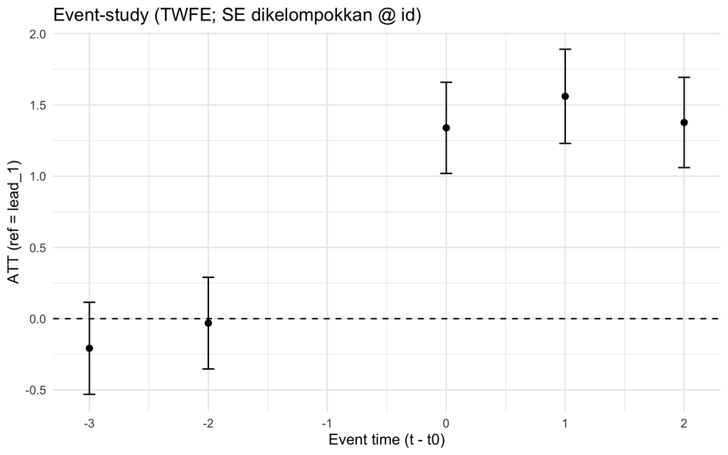

Event-study: koefisien lead/lag relatif terhadap periode referensi (lead_1).

```r
# Map nama term -> indeks waktu (-3, -2, 0, 1, 2, 3)
map_time <- c(
  "lead_3ormore" = -3,
  "lead_2"       = -2,
  # "lead_1" adalah REFERENCE -> tidak muncul sebagai koefisien
  "lag_0"        =  0,
  "lag_1"        =  1,
  "lag_2"        =  2,
  "lag_3ormore"  =  3
)

# Ambil nama bucket dari "event_bucket::<bucket>:D_i"
est_plot <- est %>%
  dplyr::mutate(
    bucket = term |>
      stringr::str_remove("^event_bucket::") |>
      stringr::str_remove(":D_i$"),
    time = dplyr::case_when(
      bucket == "lead_3ormore" ~ -3,
      bucket == "lead_2"       ~ -2,
      # "lead_1" adalah baseline (ref), jadi TIDAK muncul di koefisien
      bucket == "lag_0"        ~  0,
      bucket == "lag_1"        ~  1,
      bucket == "lag_2"        ~  2,
      bucket == "lag_3ormore"  ~  3,
      TRUE ~ NA_real_
    ),
    ci_lo = estimate - 1.96*std.error,
    ci_hi = estimate + 1.96*std.error
  ) %>%
  dplyr::arrange(time)

# Cek cepat: kalau semua NA, berarti label-nya beda—lihat names(coef(m_es))
if (all(is.na(est_plot$time))) {
  message("Label tidak terpetakan. Cek names(coef(m_es)) untuk pola aktual:")
  print(names(coef(m_es)))
}

ggplot2::ggplot(est_plot, ggplot2::aes(x = time, y = estimate)) +
  ggplot2::geom_hline(yintercept = 0, linetype = 2) +
  ggplot2::geom_point(size = 2) +
  ggplot2::geom_errorbar(ggplot2::aes(ymin = ci_lo, ymax = ci_hi), width = 0.1) +
  ggplot2::scale_x_continuous(breaks = -3:3) +
  ggplot2::labs(
    x = "Event time (t - t0)",
    y = paste0("ATT (ref = ", ref_level, ")"),
    title = "Event-study (TWFE; SE dikelompokkan @ id)"
  ) +
  ggplot2::theme_minimal(base_size = 12)
```

## 7.8 Ringkasan Praktis

- Gunakan **OLS interaksi** untuk 2×2, tambahkan **clustered SE** (umumnya per unit) untuk inferensi yang valid.
- Untuk panel banyak periode, gunakan **TWFE** dengan *unit* dan *time FE*; cek **parallel trends** via *event study* (uji *lead* sebagai placebo).
- Waspadai **staggered adoption** (kebijakan diimplementasi pada waktu berbeda). Untuk itu, pertimbangkan estimator modern (Callaway–Sant’Anna; Sun–Abraham).

## 7.9 Lampiran: Varian Lanjutan (Opsional)

Di sini contoh *staggered adoption* minimalis memakai `fixest::sunab()` (Sun–Abraham).

```r
set.seed(99)
N  <- 400
Tt <- 8
id <- rep(1:N, each = Tt)
t  <- rep(1:Tt, times = N)

# Unit dibagi ke beberapa gelombang treatment (g): 3,5,7; sebagian tak pernah treated (g=Inf)
groups <- sample(c(3,5,7,Inf), N, replace = TRUE, prob = c(.3,.3,.2,.2))
g <- rep(groups, each = Tt)

treated <- as.integer(t >= g)            # akan 0 bila g=Inf
alpha_i <- rep(rnorm(N, 0, 1), each = Tt)
lambda_t <- rep(sin(2*pi*(1:Tt)/Tt), times = N)  # shock waktu non-linear

tau <- 1.2  # ATT rata-rata
y <- 1 + 0.5*treated + tau*treated + alpha_i + lambda_t + rnorm(N*Tt, 0, 1)

dat <- tibble(id, t, y, g, treated)

# Sun-Abraham 'sunab' with fixest
m_sa <- feols(y ~ sunab(g, t) | id + t, data = dat, cluster = ~ id)
iplot(m_sa, ref.line = 0)   # plot event-time ATT
```

[output not shown]

## 7.10 Intuisi dan Ringkasan Konsep (Tambahan)

**Difference-in-Differences (DiD)** mengukur efek kausal kebijakan dengan membandingkan *perubahan* outcome pada kelompok **treatment** terhadap *perubahan* pada kelompok **control** dari sebelum ke sesudah kebijakan. Intuisi kasarnya:

$$\text{Efek DiD} = (\Delta
Y_{\text{treat}}) - (\Delta Y_{\text{control}}).$$

Asumsi kunci: **parallel trends** — tanpa kebijakan, tren outcome kedua kelompok akan bergerak sejajar.

## 7.11 Simulasi Data dan Visualisasi Tren

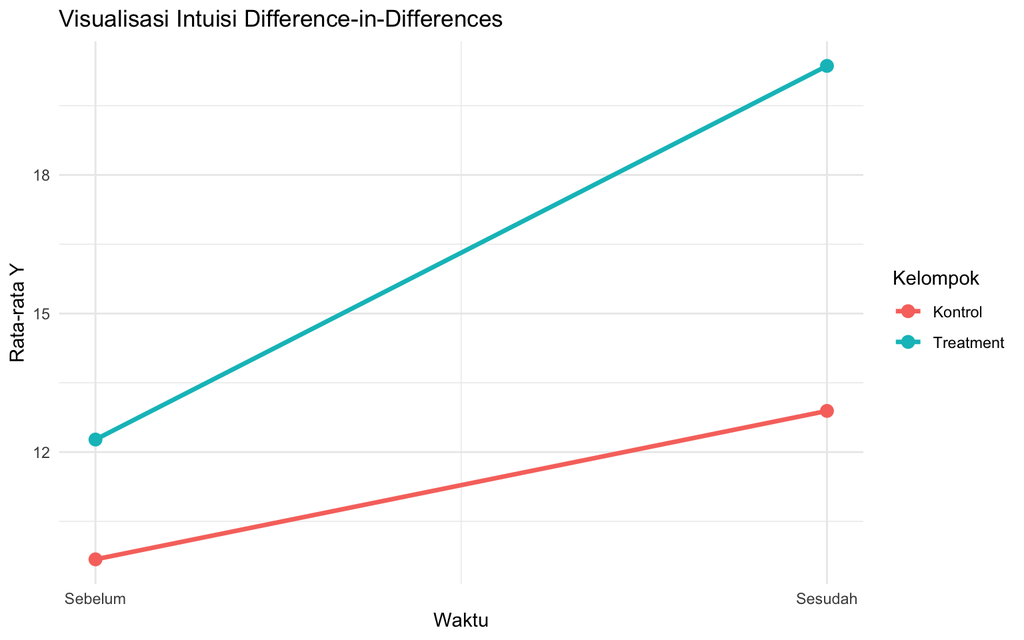

```r
set.seed(123)
library(dplyr)
library(ggplot2)

# N unit, 2 periode (0 = sebelum, 1 = sesudah)
n <- 200
dat <- expand.grid(id = 1:n, time = 0:1) %>% as_tibble()

# 50% unit sebagai treatment
dat <- dat %>%
  mutate(treat = as.integer(id <= n/2))

# DGP:
# baseline 10, beda baseline treatment 2, efek waktu umum 3,
# efek kebijakan (DiD) = 5 (hanya untuk treatment pada periode sesudah)
dat <- dat %>%
  mutate(
    Y = 10 + 2*treat + 3*time + 5*(treat*time) + rnorm(nrow(.), sd = 3)
    #                ^^^^^^^^^^ panjang noise tepat = jumlah baris data
  )

# Rata-rata per grup-waktu untuk plot
mean_trend <- dat %>%
  group_by(treat, time) %>%
  summarise(meanY = mean(Y), .groups = "drop")

ggplot(mean_trend, aes(x = time, y = meanY, color = factor(treat))) +
  geom_line(size = 1.2) +
  geom_point(size = 3) +
  scale_x_continuous(breaks = c(0,1), labels = c("Sebelum","Sesudah")) +
  scale_color_discrete(labels = c("Kontrol","Treatment")) +
  labs(x = "Waktu", y = "Rata-rata Y", color = "Kelompok",
       title = "Visualisasi Intuisi Difference-in-Differences") +
  theme_minimal()
```

```r
# (Opsional) Sanity check: regresi DiD klasik
did_lm <- lm(Y ~ treat + time + treat:time, data = dat)
summary(did_lm)$coefficients
```

```
##             Estimate Std. Error   t value      Pr(>|t|)
## (Intercept) 9.677360  0.2904595 33.317413 6.311389e-117
## treat       2.593858  0.4107718  6.314597  7.278946e-10
## time        3.213972  0.4107718  7.824227  4.696510e-14
## treat:time  4.876206  0.5809190  8.393951  8.433604e-16
```

```r
# Koefisien interaksi (treat:time) ≈ 5 (sesuai DGP)
```

## 7.12 Estimasi Model DiD (Regresi Interaksi)

Model dasar DiD:

$$Y_{it} = \alpha + \beta\,\text{treat}_i
+ \gamma\,\text{post}_t + \delta(\text{treat}_i \times \text{post}_t) +
\varepsilon_{it}.$$

Di simulasi ini, $\text{post}_t = \text{time}$. Koefisien interaksi ($\delta$) adalah **efek DiD**.

```r
m_did <- lm(Y ~ treat + time + treat:time, data = dat)
broom::tidy(m_did)
```

```
## # A tibble: 4 × 5
##   term        estimate std.error statistic   p.value
##   <chr>          <dbl>     <dbl>     <dbl>     <dbl>
## 1 (Intercept)     9.68     0.290     33.3  6.31e-117
## 2 treat           2.59     0.411      6.31 7.28e- 10
## 3 time            3.21     0.411      7.82 4.70e- 14
## 4 treat:time      4.88     0.581      8.39 8.43e- 16
```

Interpretasi cepat: koefisien `treat:time` adalah estimasi efek kebijakan (DiD).

## 7.13 Standard Error Berkelompok

Pada praktiknya, error sering berkorelasi dalam unit/kelompok. Gunakan **clustered robust SE** (misalnya dikelompokkan pada `id`). Jika paket `sandwich` dan `lmtest` tersedia, hasil dengan SE berkelompok akan ditampilkan.

```r
if (requireNamespace("sandwich", quietly = TRUE) && requireNamespace("lmtest", quietly = TRUE)) {
  vcov_cl <- sandwich::vcovCL(m_did, cluster = dat$id, type = "HC1")
  lmtest::coeftest(m_did, vcov = vcov_cl)
} else {
  message("Lewati SE berkelompok: paket 'sandwich' dan/atau 'lmtest' tidak tersedia.")
}
```

```
##
## t test of coefficients:
##
##             Estimate Std. Error t value  Pr(>|t|)
## (Intercept)  9.67736    0.29046 33.3173 < 2.2e-16 ***
## treat        2.59386    0.39943  6.4939 2.511e-10 ***
## time         3.21397    0.41687  7.7097 1.029e-13 ***
## treat:time   4.87621    0.59210  8.2355 2.631e-15 ***
## ---
## Signif. codes:  0 '***' 0.001 '**' 0.01 '*' 0.05 '.' 0.1 ' ' 1
```

## 7.14 Versi Panel dengan Fixed Effects (TWFE)

Untuk data panel (unit berulang antar waktu), model **two-way fixed effects (TWFE)** menambahkan efek tetap unit dan waktu:

$$Y_{it} = \alpha_i + \lambda_t +
\delta(\text{treat}_i \times \text{post}_t) + \varepsilon_{it}.$$

```r
# Buat faktor unit dan waktu
dat <- dat %>% mutate(id_f = factor(id), t_f = factor(time))

# Estimasi TWFE via regresi dengan dummy unit & waktu (tanpa intercept duplikat)
m_twfe <- lm(Y ~ treat:time + id_f + t_f, data = dat)
broom::tidy(m_twfe) %>%
  filter(term == "treat:time")  # sorot koefisien interaksi utama
```

```
## # A tibble: 1 × 5
##   term       estimate std.error statistic  p.value
##   <chr>         <dbl>     <dbl>     <dbl>    <dbl>
## 1 treat:time     4.88     0.591      8.25 2.24e-14
```

> Catatan: Untuk aplikasi serius, pertimbangkan paket khusus seperti **fixest** atau **lfe** untuk efisiennya estimasi FE skala besar serta ragam opsi SE.

## 7.15 Pemeriksaan (Kualitatif) Parallel Trends

Dengan hanya dua periode, pemeriksaan bersifat kualitatif melalui plot rata-rata per grup-waktu. Untuk banyak periode, gunakan **event study** agar bisa melihat dinamika pra- dan pasca-kebijakan.

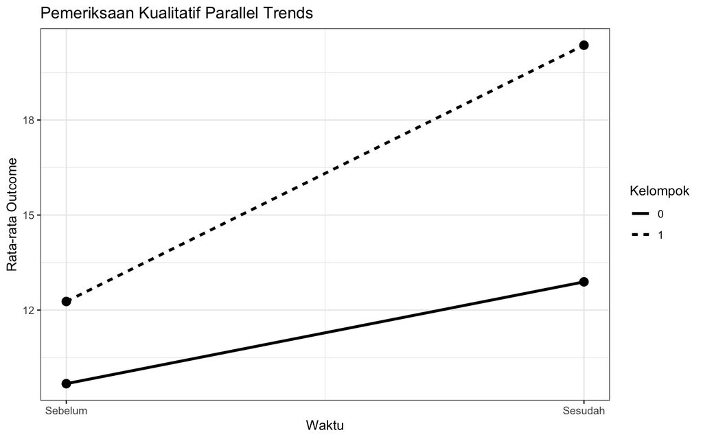

```r
ggplot(mean_trend, aes(x = time, y = meanY, group = factor(treat), linetype = factor(treat))) +
  geom_line(size = 1.1) + geom_point(size = 3) +
  scale_x_continuous(breaks = c(0,1), labels = c("Sebelum","Sesudah")) +
  labs(title = "Pemeriksaan Kualitatif Parallel Trends",
       x = "Waktu", y = "Rata-rata Outcome", linetype = "Kelompok") +
  theme_bw()
```

## 7.16 Ringkasan dan Praktik Baik

- **Kunci DiD**: koefisien interaksi adalah estimasi efek kebijakan.
- **Asumsi inti**: *parallel trends*. Uji/pertimbangkan via pra-tren (bila banyak periode).
- **SE berkelompok**: hampir wajib saat panel/clustered sampling.
- **Hati-hati** saat ada **staggered treatment** (waktu treatment berbeda): gunakan metode modern (Callaway–Sant’Anna, Sun–Abraham, Synthetic DiD) untuk menghindari bias agregasi.

## 7.17 Lampiran: Replikasi Rumus Empat Sel

Rumus DiD empat sel:

$$(\bar{Y}_{T,1}-\bar{Y}_{T,0})-(\bar{Y}_{C,1}-\bar{Y}_{C,0}).$$

```r
cells <- dat %>%
  group_by(treat, time) %>%
  summarise(meanY = mean(Y), .groups = "drop") %>%
  pivot_wider(names_from = time, values_from = meanY, names_prefix = "t")

cells
```

```
## # A tibble: 2 × 3
##   treat    t0    t1
##   <int> <dbl> <dbl>
## 1     0  9.68  12.9
## 2     1 12.3   20.4
```

```r
did_four_cells <- (cells %>% filter(treat == 1) %>% pull(t1) -
                   cells %>% filter(treat == 1) %>% pull(t0)) -
                  (cells %>% filter(treat == 0) %>% pull(t1) -
                   cells %>% filter(treat == 0) %>% pull(t0))

did_four_cells
```

```
## [1] 4.876206
```

Mengevaluasi efek kebijakan/perlakuan sebelum–sesudah pada kelompok perlakuan vs kontrol. Asumsi kunci: **parallel trends**.

$$Y_{it} = \alpha + \delta D_i + \gamma T_t + \beta(D_i \times T_t) +
\varepsilon_{it}.$$

```r
set.seed(42)
n_g <- 100
group <- rep(c(0,1), each = n_g)     # 0: kontrol, 1: perlakuan
time  <- rep(rep(c(0,1), each = n_g/2), 2)  # 0: sebelum, 1: sesudah
tau   <- 2                            # efek perlakuan sejati
y     <- 5 + 1*group + 1*time + tau*(group*time) + rnorm(2*n_g, 0, 1)
did_df <- tibble(y, group, time)

did_model <- fixest::feols(y ~ group*time, data = did_df)
summary(did_model)
```

```
## OLS estimation, Dep. Var.: y
## Observations: 200
## Standard-errors: IID
##             Estimate Std. Error  t value   Pr(>|t|)
## (Intercept) 4.964328   0.138292 35.89743  < 2.2e-16 ***
## group       0.884421   0.195574  4.52217 1.0585e-05 ***
## time        1.136373   0.195574  5.81044 2.4874e-08 ***
## group:time  1.991162   0.276584  7.19912 1.2635e-11 ***
## ---
## Signif. codes:  0 '***' 0.001 '**' 0.01 '*' 0.05 '.' 0.1 ' ' 1
## RMSE: 0.968044   Adj. R2: 0.703117
```

**Interpretasi.** Koefisien interaksi `group:time` adalah taksiran efek perlakuan rata-rata.

# 8 **Synthetic Control Model (SCM)**

Synthetic Control Model (SCM) itu cara cerdas untuk mencari “kelompok pembanding buatan” ketika kita ingin tahu dampak suatu kebijakan atau peristiwa pada satu unit tertentu (misalnya satu kota, satu negara, atau satu perusahaan), tapi tidak ada kelompok kontrol alami yang pas.

Bayangkan begini: Misalnya Kota Bandung menerapkan aturan larangan kendaraan pribadi di pusat kota pada 2020, dan kita ingin tahu apakah kebijakan itu menurunkan polusi udara. Masalahnya, semua kota lain punya kondisi berbeda—ekonomi, cuaca, industri, dll.—jadi sulit cari “kota kembar” Bandung yang benar-benar identik.

Nah, Synthetic Control membangun kembar buatan Bandung dengan menggabungkan beberapa kota lain secara proporsional, seperti membuat smoothie dari data: sedikit Jakarta, sedikit Surabaya, sedikit Semarang—campurannya dipilih sedemikian rupa agar sebelum 2020, tren polusi Bandung dan “Bandung sintetis” hampir sama. Setelah 2020, perbedaan antara keduanya dianggap sebagai efek kebijakan.

Secara matematis:

- SCM mencari bobot $w_j$ untuk tiap kota kontrol sehingga kombinasi tertimbang mereka meniru data pre-treatment Bandung.
- Lalu dibandingkan outcome post-treatment Bandung vs. kontrol sintetis.
- Selisihnya = estimasi dampak kebijakan.

Keunggulan SCM:

- Lebih transparan daripada regresi biasa.
- Cocok untuk kasus satu unit treatment (misalnya satu negara dengan kebijakan unik).
- Tidak butuh asumsi “parallel trends” yang sekuat DiD.

Singkatnya: > SCM = Difference-in-Differences versi kreatif, yang membuat kontrol buatan dengan campuran optimal dari unit lain supaya mirip banget dengan unit perlakuan sebelum kebijakan.

> **Synthetic Control Method (SCM)** adalah metode kuasi-eksperimen untuk mengevaluasi dampak kausal kebijakan/peristiwa pada **satu** unit yang terpapar (treated unit) ketika hanya tersedia beberapa unit pembanding. Inti gagasannya: membangun **“kontrol sintetis”** sebagai **kombinasi cembung** dari unit-unit donor (kontrol) sehingga jejak (*trajectory*) pra-intervensi dari treated **tercocokkan sebaik mungkin**.

Secara kausal:
$$\text{Effect}_t = Y_{1t}^{(observed)} - \hat{Y}_{1t}^{(untreated)} \, ,$$
dengan $\hat{Y}_{1t}^{(untreated)}$ didekati oleh kontrol sintetis.

## 8.1 Objective Function & Bobot Optimal

SCM memilih bobot $w = (w_1, \ldots, w_J)$ non-negatif (dan biasanya menjumlah ke 1) dengan meminimalkan ketidakcocokan *pre-treatment* pada sekumpulan prediktor/outcome:

$$\min_{w} \sum_k v_k\,\Big( X_{1k} - \sum_j w_j X_{0jk} \Big)^2$$

- $X_{1k}$: nilai prediktor (atau rata-rata outcome pra) unit treated pada dimensi ke-$k$.
- $X_{0jk}$: nilai prediktor untuk unit kontrol ke-$j$.
- $v_k$: bobot kepentingan antar prediktor.

Solusi optimasi menghasilkan **bobot optimal** $w^*$. Bobot ini lalu dipakai untuk menyintesis outcome:

$$\hat{Y}^{\text{synthetic}}_{1t} = \sum_j w_j^{*} Y_{jt}.$$

**Apakah** $w = w^*$?  
Tidak. $w$ adalah variabel keputusan dalam proses minimisasi; $w^*$ adalah **nilai optimal** dari $w$ yang meminimalkan objective function di atas.

## 8.2 Algoritma Ringkas (intuitif)

1. Pilih *donor pool* (unit tanpa kebijakan).
2. Tentukan jendela waktu **sebelum** kebijakan (pre).
3. Cari $w^*$ agar kombinasi donor meniru treated pada periode pre.
4. Bentuk kontrol sintetis pada **sesudah** kebijakan (post) dan ambil selisih dengan treated sebagai estimasi efek.
5. Uji ketahanan: *placebo test* (terapkan prosedur ke unit lain), *leave-one-out*, dll.

## 8.3 Contoh A — **Simulasi Sederhana (tanpa paket khusus SCM)**

Tujuan: memperlihatkan ide SCM dengan **nonnegative least squares** ($w_j \ge 0$), lalu menormalkan bobot agar berjumlah 1.

> Paket yang dipakai: `dplyr`, `tidyr`, `ggplot2`, `nnls` (untuk nonnegative LS).

```r
library("dplyr", "tidyr", "ggplot2", "nnls")
```

### 8.3.1 Bangun data simulasi

- 1 unit treated (id = T1) mendapat intervensi pada t >= 11.
- 10 unit donor (D1…D10) tidak mendapat intervensi.
- Outcome dipengaruhi tren umum + efek kebijakan pada treated.

```r
set.seed(123)
T_pre  <- 10            # panjang pre
T_post <- 10            # panjang post
T_tot  <- T_pre + T_post
J      <- 10            # jumlah donor

time <- 1:T_tot

# Tren umum
mu_t <- 0.2 * time

# Donor outcomes (J unit)
donors <- replicate(J, mu_t + rnorm(T_tot, sd = 0.5)) # matriks T x J

# Treated outcome
treated <- mu_t + rnorm(T_tot, sd = 0.5)
# Tambahkan efek kebijakan pada periode post
effect_true <- 2
treated[(T_pre+1):T_tot] <- treated[(T_pre+1):T_tot] + effect_true

# Satukan ke data frame panjang (long)
df <- dplyr::bind_rows(
  data.frame(unit = "T1", time = time, y = treated, treated = 1),
  do.call(rbind, lapply(1:J, function(j){
    data.frame(unit = paste0("D", j), time = time, y = donors[, j], treated = 0)
  }))
)
head(df)
```

```
##   unit time         y treated
## 1   T1    1 1.2994052       1
## 2   T1    2 1.0562065       1
## 3   T1    3 0.4674275       1
## 4   T1    4 1.0715970       1
## 5   T1    5 0.7928300       1
## 6   T1    6 0.9618766       1
```

### 8.3.2 Estimasi bobot $w^*$ (berbasis periode **pre** saja)

Kita cocokkan deret **pre** milik treated dengan kombinasi nonnegatif dari donor **pre** (pakai `nnls`).

```r
library(dplyr)
library(tidyr)
library(nnls)

# ---------------------- PREP ----------------------
# Subset pre-treatment
df_pre <- df %>% filter(time <= T_pre)

# Matriks donor (kolom = unit donor, baris = waktu), urut waktu
donor_wide <- df_pre %>%
  dplyr::filter(treated == 0) %>%
  dplyr::select(time, unit, y) %>%
  dplyr::mutate(y = as.numeric(y)) %>%
  tidyr::pivot_wider(names_from = unit, values_from = y) %>%
  dplyr::arrange(time)


# Pastikan dplyr & tidyr dipanggil terakhir
library(dplyr)
library(tidyr)

# X_pre: buang kolom time, pastikan numerik, jadikan matrix
X_pre <- donor_wide %>%
  dplyr::select(-time) %>%
  dplyr::mutate(dplyr::across(dplyr::everything(), as.numeric)) %>%
  as.matrix()

# y_pre: selaraskan dengan urutan waktu donor_wide
t1_pre <- df_pre %>%
  dplyr::filter(unit == "T1") %>%
  dplyr::select(time, y) %>%
  dplyr::arrange(time)

y_pre <- donor_wide %>%
  dplyr::select(time) %>%
  dplyr::left_join(t1_pre, by = "time") %>%
  dplyr::pull(y) %>%
  as.numeric()


# Buang baris dengan NA di y atau X secara serempak
keep <- complete.cases(cbind(y_pre, X_pre))
Xc   <- X_pre[keep, , drop = FALSE]
yc   <- y_pre[keep]

# Cek dimensi minimal
stopifnot(nrow(Xc) == length(yc), nrow(Xc) > 0, ncol(Xc) > 0)

# ---------------------- FIT NNLS ----------------------
# nnls pakai argumen posisional (tanpa nama)
fit   <- nnls::nnls(Xc, yc)
w_raw <- as.numeric(coef(fit))

# Normalisasi agar jumlah bobot = 1 (fallback: rata jika semua nol)
if (sum(w_raw) > 0) {
  w_star <- w_raw / sum(w_raw)
} else {
  w_star <- rep(1 / ncol(Xc), ncol(Xc))
}

# Tabel bobot
w_tbl <- tibble(
  unit   = colnames(Xc),
  weight = w_star
) %>%
  arrange(desc(weight))

w_tbl
```

```
## # A tibble: 10 × 2
##    unit  weight
##    <chr>  <dbl>
##  1 D8    0.438
##  2 D9    0.256
##  3 D6    0.225
##  4 D3    0.0478
##  5 D1    0.0329
##  6 D2    0
##  7 D4    0
##  8 D5    0
##  9 D7    0
## 10 D10   0
```

### 8.3.3 Bangun kontrol sintetis & plot

Sintesis outcome di **seluruh waktu** (pre + post) lalu bandingkan dengan treated.

```r
library(dplyr)
library(tidyr)
library(ggplot2)

# ------------------------ Donor (all time) ------------------------
donor_wide_all <- df %>%
  dplyr::filter(treated == 0) %>%
  dplyr::select(time, unit, y) %>%
  dplyr::mutate(y = as.numeric(y)) %>%
  tidyr::pivot_wider(names_from = unit, values_from = y) %>%
  dplyr::arrange(time)

# Simpan vektor waktu
time_all <- donor_wide_all$time

# Matrix donor (numerik)
X_all <- donor_wide_all %>%
  dplyr::select(-time) %>%
  dplyr::mutate(dplyr::across(dplyr::everything(), as.numeric)) %>%
  as.matrix()

# ------------------------ Treated (all time) ------------------------
t1_all <- df %>%
  dplyr::filter(unit == "T1") %>%
  dplyr::select(time, y) %>%
  dplyr::arrange(time)

y_all <- donor_wide_all %>%
  dplyr::select(time) %>%
  dplyr::left_join(t1_all, by = "time") %>%
  dplyr::pull(y) %>%
  as.numeric()

# ------------------------ Sinkronisasi NA & hitung synthetic ------------------------
keep_all <- stats::complete.cases(cbind(y_all, X_all))
time_kept <- time_all[keep_all]
Xc_all    <- X_all[keep_all, , drop = FALSE]
yc_all    <- y_all[keep_all]

# Pastikan urutan bobot sejajar kolom X
stopifnot(length(w_star) == ncol(Xc_all))

y_synth_all <- as.numeric(Xc_all %*% w_star)

# ------------------------ Frame hasil ------------------------
T_pre_num <- T_pre  # pastikan T_pre adalah angka cut-off pre-treatment
res <- tibble::tibble(
  time    = time_kept,
  treated = yc_all,
  synth   = y_synth_all
) %>%
  dplyr::mutate(
    period = ifelse(time <= T_pre_num, "Pre", "Post"),
    gap    = treated - synth
  )

# ------------------------ Ringkas metrik ------------------------
summary_metrics <- res %>%
  dplyr::summarise(
    RMSE_pre  = sqrt(mean(gap[period == "Pre"]^2,  na.rm = TRUE)),
    RMSE_post = sqrt(mean(gap[period == "Post"]^2, na.rm = TRUE)),
    ATT_post  = mean(gap[period == "Post"],        na.rm = TRUE),
    Cum_post  = sum(gap[period == "Post"],         na.rm = TRUE),
    .groups = "drop"
  )

print(summary_metrics)
```

```
## # A tibble: 1 × 4
##   RMSE_pre RMSE_post ATT_post Cum_post
##      <dbl>     <dbl>    <dbl>    <dbl>
## 1    0.445      1.96     1.90     19.0
```

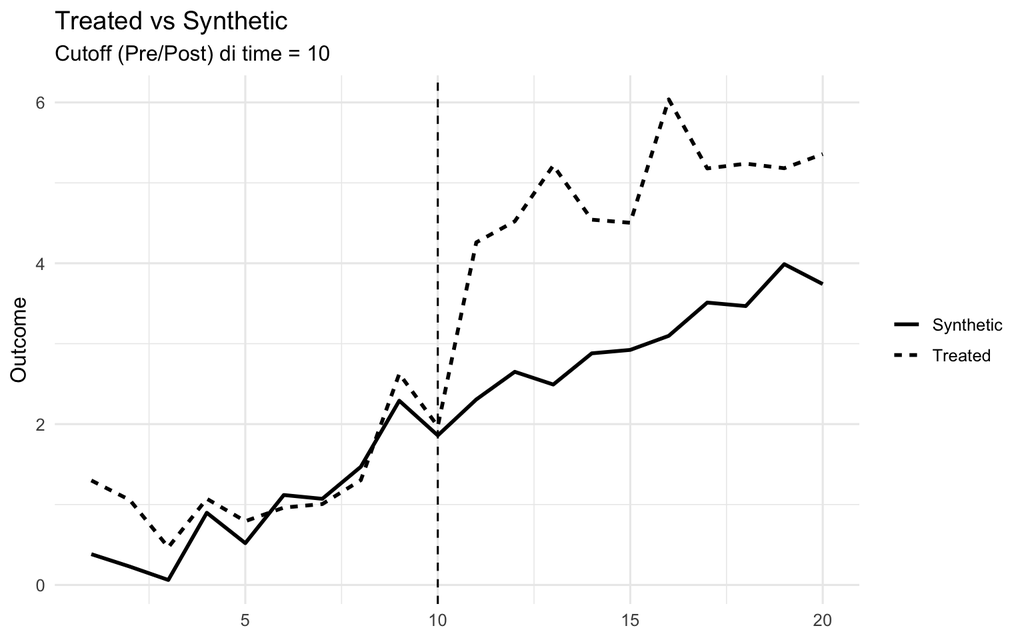

```r
# ------------------------ Plot level ------------------------
p_level <- ggplot(res, aes(x = time)) +
  geom_line(aes(y = treated, linetype = "Treated"), linewidth = 1) +
  geom_line(aes(y = synth,   linetype = "Synthetic"), linewidth = 1) +
  geom_vline(xintercept = T_pre_num, linetype = 2) +
  labs(x = NULL, y = "Outcome", linetype = NULL,
       title = "Treated vs Synthetic",
       subtitle = paste0("Cutoff (Pre/Post) di time = ", T_pre_num)) +
  theme_minimal(base_size = 12)

# ------------------------ Plot gap ------------------------
p_gap <- ggplot(res, aes(x = time, y = gap)) +
  geom_hline(yintercept = 0, linewidth = 0.4) +
  geom_line(linewidth = 1) +
  geom_vline(xintercept = T_pre_num, linetype = 2) +
  labs(x = NULL, y = "Gap (Treated - Synthetic)",
       title = "SCM Gap over Time") +
  theme_minimal(base_size = 12)

print(p_level)
```

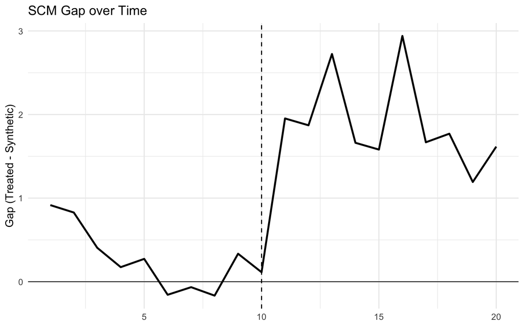

```r
print(p_gap)
```

### 8.3.4 Estimasi efek & plot *gap*

Efek waktu-ke-waktu = **gap** antara treated dan synthetic.

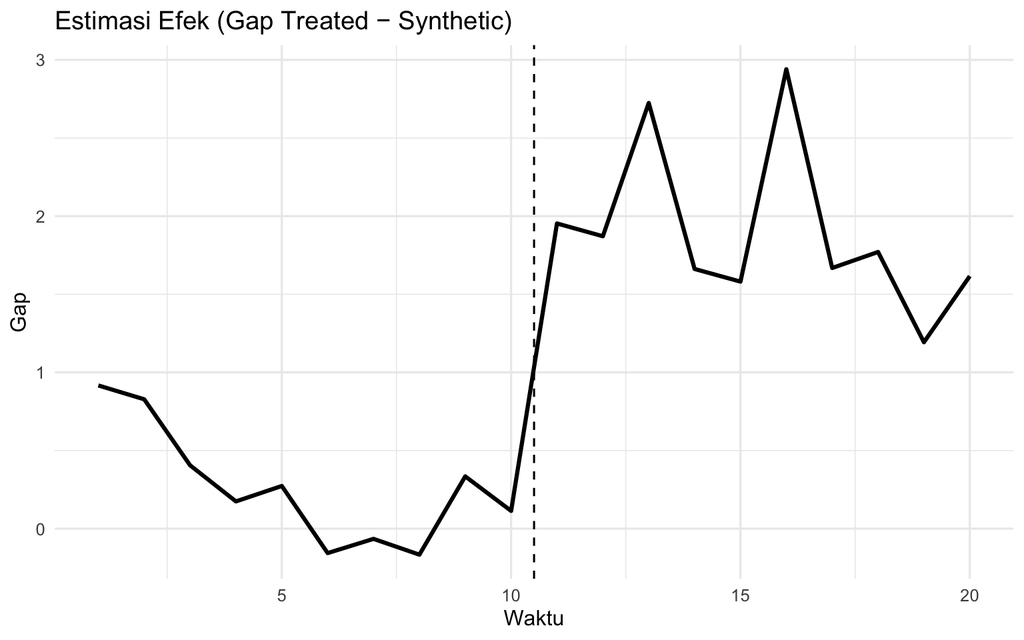

```r
gap <- yc_all - y_synth_all
gap_df <- data.frame(time = time_kept, gap = gap)

ggplot(gap_df, aes(time, gap)) +
  geom_vline(xintercept = T_pre + 0.5, linetype = 2) +
  geom_line(linewidth = 1.1) +
  labs(
    title = "Estimasi Efek (Gap Treated − Synthetic)",
    x = "Waktu", y = "Gap"
  ) +
  theme_minimal(base_size = 12)
```

## 8.4 Contoh B — **Data Nyata (opsional) `tidysynth`: California Smoking**

Contoh klasik: dampak kebijakan pengendalian rokok di California terhadap konsumsi rokok per kapita.

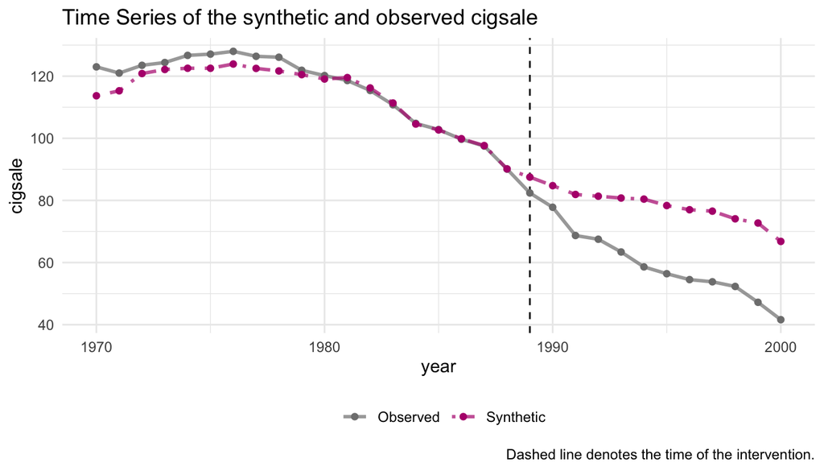

```r
suppressPackageStartupMessages({
  library(dplyr); library(tidysynth); library(ggplot2)
})

# 1) Data & window
data("smoking", package = "tidysynth")
pre_win <- 1980:1988
i_time  <- 1989

smoking <- smoking %>%
  mutate(
    cigsale   = as.numeric(cigsale),
    lnincome  = as.numeric(lnincome),
    beer      = as.numeric(beer),
    age15to24 = as.numeric(age15to24)
  )

# 2) Donor filter: minimal 2 donor yang cukup lengkap di pre_win
complete_donor <- smoking %>%
  filter(year %in% pre_win) %>%
  group_by(state) %>%
  summarise(ok = mean(!is.na(cigsale)) >= 0.8, .groups = "drop") %>%
  filter(ok, state != "California") %>%
  pull(state)

smk_clean <- smoking %>% filter(state %in% complete_donor | state == "California")

if (dplyr::n_distinct(smk_clean$state[smk_clean$state != "California"]) < 2) {
  pre_win <- 1982:1988
  complete_donor <- smoking %>%
    filter(year %in% pre_win) %>%
    group_by(state) %>%
    summarise(ok = mean(!is.na(cigsale)) >= 0.8, .groups = "drop") %>%
    filter(ok, state != "California") %>%
    pull(state)
  smk_clean <- smoking %>% filter(state %in% complete_donor | state == "California")
}

# 3) Fit SCM
synth_out <- smk_clean %>%
  synthetic_control(
    outcome = cigsale, unit = state, time = year,
    i_unit = "California", i_time = i_time, generate_placebos = TRUE
  ) %>%
  # prediktor yang stabil
  generate_predictor(time_window = pre_win,
                     beer = mean(beer, na.rm = TRUE),
                     age15to24 = mean(age15to24, na.rm = TRUE),
                     lnincome = mean(lnincome, na.rm = TRUE),
                     cigsale = mean(cigsale, na.rm = TRUE)) %>%
  # beberapa jangkar outcome
  generate_predictor(time_window = 1980, cigsale_1980 = mean(cigsale, na.rm = TRUE)) %>%
  generate_predictor(time_window = 1985, cigsale_1985 = mean(cigsale, na.rm = TRUE)) %>%
  generate_predictor(time_window = 1988, cigsale_1988 = mean(cigsale, na.rm = TRUE)) %>%
  generate_weights(optimization_window = pre_win) %>%
  generate_control()

# 4) Plot (harus diprint saat knit/source)
print(plot_trends(synth_out))
```

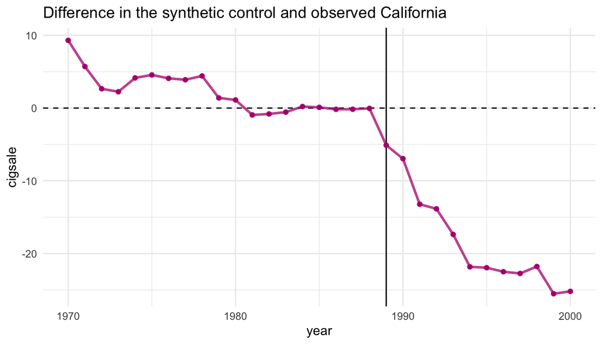

```r
print(plot_differences(synth_out))
```

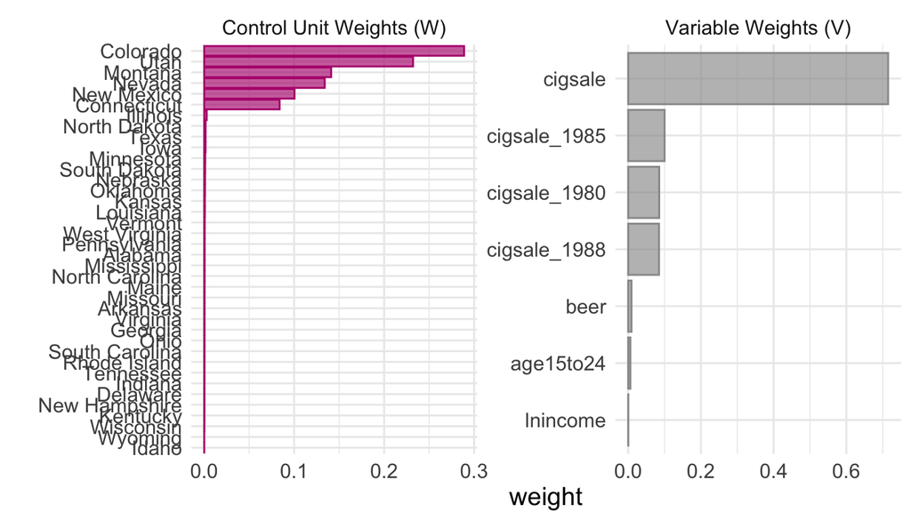

```r
print(plot_weights(synth_out))
```

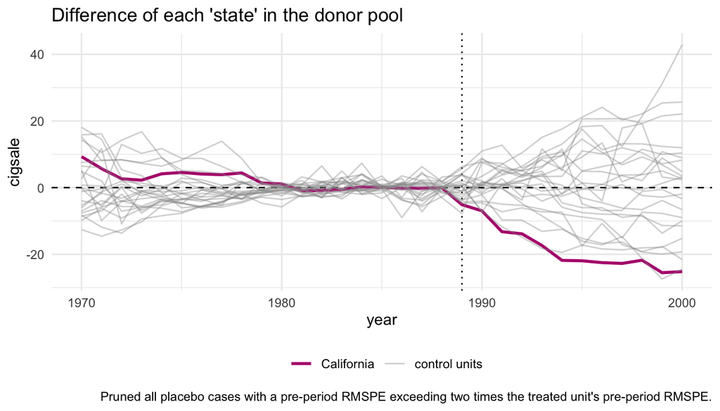

```r
print(plot_placebos(synth_out))
```

**Catatan Diagnostik & Inferensi**

- **Good pre-fit** penting: garis Treated dan Synthetic harus berpelukan di periode pre.
- **Placebo test**: ulangi SCM seolah-olah setiap unit donor adalah treated; bandingkan besar gap.
- **Leave-one-out**: cek sensitivitas bobot (apakah satu donor mendominasi).
- **Standard errors**: biasanya berbasis penugasan ulang (*permutation inference*), bukan formula OLS klasik.

**Ringkas**

- Objective function memetakan *masalah pencocokan pre* menjadi tugas optimasi.
- $w^*$ adalah solusi optimal; digunakan untuk menyintesis $\hat{Y}^{synthetic}$.
- Grafik **Treated vs Synthetic** dan **Gap** adalah alat utama untuk membaca efek dari waktu ke waktu.

## 8.5 Contoh C

```r
library(Synth)
library(gsynth)

# Reproducibility
set.seed(1)

# Knitr options (opsional)
knitr::opts_chunk$set(message = FALSE, warning = FALSE, dpi = 120)
```

**Simulasi Data**

Kita buat data untuk 10 *state* dan 30 tahun. **State A** menerima perlakuan mulai **tahun 15**. Kita pastikan kolom pengenal unit **numeric** agar tidak muncul error `unit.variable not found as numeric variable in foo`.

```r
year  <- rep(1:30, 10)
state <- rep(LETTERS[1:10], each = 30)

X1 <- round(rnorm(300, mean = 2, sd = 1), 2)
X2 <- round(rbinom(300, 1, 0.5) + rnorm(300), 2)
Y  <- round(1 + 2*X1 + rnorm(300), 2)

df <- data.frame(Y = Y, X1 = X1, X2 = X2, state = state, year = year,
                 stringsAsFactors = FALSE)

# Pastikan tipe data yang sesuai
df$Y    <- as.numeric(df$Y)
df$X1   <- as.numeric(df$X1)
df$X2   <- as.numeric(df$X2)
df$year <- as.numeric(df$year)
df$state <- as.character(df$state)

# Kode numerik untuk unit (WAJIB numeric untuk Synth::dataprep)
df$state.num <- as.numeric(factor(df$state, levels = LETTERS[1:10]))

# Perlakuan untuk State A mulai tahun 15
df$T <- ifelse(df$state == "A" & df$year >= 15, 1, 0)

# Tambahkan efek treatment sebesar 20 pada outcome setelah tahun 15 untuk A
df$Y <- ifelse(df$state == "A" & df$year >= 15, df$Y + 20, df$Y)

# Cek struktur
str(df)
```

```
## 'data.frame':    300 obs. of  7 variables:
##  $ Y        : num  2.29 4.51 2.07 8.87 4.37 1.32 8 7.49 6.98 3.72 ...
##  $ X1       : num  1.37 2.18 1.16 3.6 2.33 1.18 2.49 2.74 2.58 1.69 ...
##  $ X2       : num  1.96 0.4 -0.75 -0.56 -0.45 1.06 0.51 -2.1 0 0.54 ...
##  $ state    : chr  "A" "A" "A" "A" ...
##  $ year     : num  1 2 3 4 5 6 7 8 9 10 ...
##  $ state.num: num  1 1 1 1 1 1 1 1 1 1 ...
##  $ T        : num  0 0 0 0 0 0 0 0 0 0 ...
```

```r
head(df)
```

```
##      Y   X1    X2 state year state.num T
## 1 2.29 1.37  1.96     A    1         1 0
## 2 4.51 2.18  0.40     A    2         1 0
## 3 2.07 1.16 -0.75     A    3         1 0
## 4 8.87 3.60 -0.56     A    4         1 0
## 5 4.37 2.33 -0.45     A    5         1 0
## 6 1.32 1.18  1.06     A    6         1 0
```

### 8.5.1 Estimasi dengan **Synth**

Kita siapkan objek `dataprep` dan jalankan `synth`. Perhatikan bahwa: - `unit.variable` **harus numeric**. - `treatment.identifier` di-set ke **1** (karena **A** dikodekan menjadi 1). - `controls.identifier` adalah 2 hingga 10.

```r
dataprep.out <- Synth::dataprep(
  foo                  = df,
  predictors           = c("X1", "X2"),
  dependent            = "Y",
  unit.variable        = "state.num",
  time.variable        = "year",
  unit.names.variable  = "state",
  treatment.identifier = 1,
  controls.identifier  = 2:10,
  time.predictors.prior = 1:14,
  time.optimize.ssr     = 1:14,
  time.plot             = 1:30
)

synth.out <- Synth::synth(dataprep.out)
```

```
##
## X1, X0, Z1, Z0 all come directly from dataprep object.
##
##
## ****************
##  searching for synthetic control unit
##
##
## ****************
## ****************
## ****************
##
## MSPE (LOSS V): 9.831789
##
## solution.v:
##  0.3888387 0.6111613
##
## solution.w:
##  0.1115941 0.1832781 0.1027237 0.312091 0.06096758 0.03509706 0.05893735 0.05746256 0.07784853
```

```r
# Tabel ringkas
synth.tables <- Synth::synth.tab(
  dataprep.res = dataprep.out,
  synth.res    = synth.out
)

synth.tables
```

```
## $tab.pred
##    Treated Synthetic Sample Mean
## X1   2.028     2.028       2.017
## X2   0.513     0.513       0.394
##
## $tab.v
##    v.weights
## X1 0.389
## X2 0.611
##
## $tab.w
##    w.weights unit.names unit.numbers
## 2      0.112          B            2
## 3      0.183          C            3
## 4      0.103          D            4
## 5      0.312          E            5
## 6      0.061          F            6
## 7      0.035          G            7
## 8      0.059          H            8
## 9      0.057          I            9
## 10     0.078          J           10
##
## $tab.loss
##            Loss W   Loss V
## [1,] 9.761706e-12 9.831789
```